# Economic Intelligence & Forecasting System

## Project Objective

The objective of this project is to build an end-to-end Economic Intelligence and Forecasting System using economic indicators from multiple countries.

The project aims to:

- Analyze macroeconomic performance
- Identify economic trends and risks
- Perform advanced statistical analysis
- Build machine learning models
- Forecast future economic indicators
- Create an executive-level Power BI dashboard

The final outcome is to provide data-driven economic intelligence and forecasting insights for decision-making.

# Business Problem

Governments, policy makers, investors and economic analysts require reliable economic intelligence to understand:

- Economic growth patterns
- Inflation dynamics
- Labor market conditions
- Financial stability
- Economic risk exposure
- Future economic outlook

Traditional reporting is descriptive.

This project introduces:

- Statistical Intelligence
- Predictive Intelligence
- Forecast Intelligence

to support better decision making.

# Project Scope

The project covers:

## 1. Data Quality Analysis

- Data auditing
- Data cleaning
- Data validation

## 2. Exploratory Data Analysis

- Univariate analysis
- Bivariate analysis
- Multivariate analysis

## 3. Advanced Statistics

- Descriptive statistics
- Distribution analysis
- Hypothesis testing
- Correlation analysis
- Statistical inference

## 4. Machine Learning

- Regression
- Classification
- Clustering
- Explainable AI

## 5. Time Series Forecasting

- Trend analysis
- Seasonality analysis
- ARIMA
- SARIMA
- Prophet
- VAR

## 6. Business Intelligence

- Executive Dashboard
- Forecast Dashboard
- Risk Dashboard

# Dataset Overview

The dataset contains:

Major domains:

- GDP
- Inflation
- Unemployment
- Interest Rate
- Trade
- FDI
- Stock Market
- Consumer Confidence
- Government Debt
- Housing Market
- Energy Prices
- Poverty
- Risk Indicators

# Project Roadmap

Phase 1 Data Quality & Cleaning

Phase 2 Exploratory Data Analysis

Phase 3 Advanced Statistics

Phase 4 Machine Learning

Phase 5 Time Series Forecasting

Phase 6 Data Export

Phase 7 Power BI Dashboard

# Expected Deliverables

Statistical Deliverables

- Descriptive Statistics Report
- Correlation Report
- Hypothesis Testing Report
- Risk Analysis Report

Machine Learning Deliverables

- Regression Models
- Classification Models
- Clustering Models
- SHAP Explainability Report

Forecasting Deliverables

- GDP Forecast
- Inflation Forecast
- Unemployment Forecast
- Risk Forecast

Dashboard Deliverables

Page 1 Economic Executive Overview

Page 2 Statistical Intelligence

Page 3 Machine Learning Intelligence

Page 4 Forecasting Intelligence

# Environment Setup & Library Import

```python
# -------------------------------
# CORE LIBRARIES
# -------------------------------

import pandas as pd
import numpy as np

# -------------------------------
# VISUALIZATION
# -------------------------------

import matplotlib.pyplot as plt
import seaborn as sns

# -------------------------------
# STATISTICS
# -------------------------------

from scipy import stats

from scipy.stats import (
    zscore,
    ttest_1samp,
    ttest_ind,
    ttest_rel,
    f_oneway,
    chi2_contingency,
    shapiro,
    kstest,
    t
)

# -------------------------------
# MACHINE LEARNING
# -------------------------------

from sklearn.model_selection import (
    train_test_split,
    cross_val_score
)

from sklearn.preprocessing import (
    LabelEncoder,
    StandardScaler
)

# -------------------------------
# REGRESSION MODELS
# -------------------------------

from sklearn.linear_model import (
    LinearRegression,
    Ridge,
    Lasso,
    LogisticRegression
)

from sklearn.ensemble import (
    RandomForestRegressor,
    RandomForestClassifier
)

from sklearn.tree import (
    DecisionTreeClassifier
)

# -------------------------------
# CLUSTERING
# -------------------------------

from sklearn.cluster import (
    KMeans,
    AgglomerativeClustering
)

# -------------------------------
# REGRESSION METRICS
# -------------------------------

from sklearn.metrics import (
    mean_absolute_error,
    mean_squared_error,
    r2_score
)

# -------------------------------
# CLASSIFICATION METRICS
# -------------------------------

from sklearn.metrics import (
    accuracy_score,
    precision_score,
    recall_score,
    f1_score,
    confusion_matrix,
    roc_auc_score,
    classification_report
)

# -------------------------------
# TIME SERIES
# -------------------------------

from statsmodels.tsa.stattools import (
    adfuller,
    kpss,
    acf,
    pacf
)

from statsmodels.tsa.seasonal import (
    seasonal_decompose
)

# -------------------------------
# ARIMA / SARIMA
# -------------------------------

from statsmodels.tsa.arima.model import ARIMA

from statsmodels.tsa.statespace.sarimax import SARIMAX

# -------------------------------
# EXPONENTIAL SMOOTHING
# -------------------------------

from statsmodels.tsa.holtwinters import (
    ExponentialSmoothing
)

# -------------------------------
# VAR MODEL
# -------------------------------

from statsmodels.tsa.api import VAR

# -------------------------------
# PROPHET
# -------------------------------

from prophet import Prophet

# -------------------------------
# XGBOOST
# -------------------------------

from xgboost import (
    XGBRegressor,
    XGBClassifier
)

# -------------------------------
# VIF
# -------------------------------

from statsmodels.stats.outliers_influence import (
    variance_inflation_factor
)

# -------------------------------
# SHAP
# -------------------------------

import shap

# -------------------------------
# WARNINGS
# -------------------------------

import warnings
warnings.filterwarnings("ignore")

# -------------------------------
# SETTINGS
# -------------------------------

pd.set_option("display.max_columns", None)
pd.set_option("display.max_rows", 100)

np.random.seed(42)

print("="*50)
print("ALL LIBRARIES LOADED SUCCESSFULLY")
print("="*50)
```

```
==================================================
ALL LIBRARIES LOADED SUCCESSFULLY
==================================================
```

# Dataset Loading & Initial Data Inspection

```python
# Load Dataset

df = pd.read_csv("Economic_Intelligence_Dataset.csv")

print("Dataset Loaded Successfully")
```

```
Dataset Loaded Successfully
```

```python
type(df)
```

```
pandas.DataFrame
```

```python
df.shape
```

```
(150000, 56)
```

```python
df.head()
```

|  | Date | Year | Month | Quarter | Country | Region | Income_Group | Sector | GDP_Billion_USD | GDP_Per_Capita_USD | GDP_Growth_Rate | Inflation_Rate | Unemployment_Rate | Interest_Rate | Real_Interest_Rate | Exchange_Rate_USD | Trade_Balance_Billion | Exports_Billion | Imports_Billion | Trade_Openness | FDI_Billion | Current_Account_pct | ForexReserves_Billion | Stock_Index | Market_Cap_Billion | Consumer_Confidence | Credit_Growth_pct | M2_Money_Growth_pct | Gov_Debt_pct_GDP | … |
| --- | --- | --- | --- | --- | --- | --- | --- | --- | --- | --- | --- | --- | --- | --- | --- | --- | --- | --- | --- | --- | --- | --- | --- | --- | --- | --- | --- | --- | --- | --- |
| 0 | 2011-11-01 | 2011 | 11 | Q4 | Indonesia | Asia Pacific | Lower-Middle | Energy | 1428.236000 | 4461.582 | -0.157 | 4.526 | 5.351 | 3.144 | -1.382 | 14.826 | -120.989 | 428.827 | 472.277 | 63.092 | 29.656 | -1.788 | 127.669 | 405.425 | 33863.254 | 92.230 | NaN | 2.411 | 77.405 | … |
| 1 | 2005-08-01 | 2005 | 8 | Q3 | Saudi Arabia | Middle East & Africa | High | Energy | 46194.709565 | 20874.546 | 0.906 | 2.273 | 6.946 | 1.604 | -0.669 | 7.880 | 25.618 | 209.710 | 225.517 | 0.942 | 7.447 | -0.134 | 75.589 | 5512.254 | 211913.201 | 126.145 | 6.828 | 3.242 | 35.972 | … |
| 2 | 2019-09-01 | 2019 | 9 | Q3 | Canada | North America | High | Energy | 2431.315000 | 53657.325 | 0.254 | 1.708 | 4.395 | 0.546 | -1.162 | 146.285 | NaN | 790.658 | 767.380 | 64.082 | 44.652 | -4.065 | 236.359 | 95.568 | 20006.211 | 88.050 | 5.080 | 2.386 | 117.849 | … |
| 3 | 2016-08-01 | 2016 | 8 | Q3 | South Africa | Middle East & Africa | Upper-Middle | Mining | 481.648000 | 7081.324 | 4.000 | NaN | 27.575 | 2.555 | NaN | 51.464 | 148.523 | 138.752 | 132.312 | 56.278 | 13.590 | 1.115 | 54.408 | 15.605 | -6387.633 | 41.783 | 10.103 | 2.803 | 67.764 | … |
| 4 | 2011-12-01 | 2011 | 12 | Q4 | Turkey | Europe | Upper-Middle | Manufacturing | 997.607000 | 9817.450 | -0.085 | 15.580 | 11.651 | 9.829 | -5.751 | 15.349 | 140.619 | 230.684 | 253.113 | 48.496 | 15.646 | -4.969 | 95.915 | -7.759 | -6621.915 | 75.114 | NaN | 3.950 | 128.527 | … |

```python
df.tail()
```

|  | Date | Year | Month | Quarter | Country | Region | Income_Group | Sector | GDP_Billion_USD | GDP_Per_Capita_USD | GDP_Growth_Rate | Inflation_Rate | Unemployment_Rate | Interest_Rate | Real_Interest_Rate | Exchange_Rate_USD | Trade_Balance_Billion | Exports_Billion | Imports_Billion | Trade_Openness | FDI_Billion | Current_Account_pct | ForexReserves_Billion | Stock_Index | Market_Cap_Billion | Consumer_Confidence | Credit_Growth_pct | M2_Money_Growth_pct | Gov_Debt_pct_GDP | … |
| --- | --- | --- | --- | --- | --- | --- | --- | --- | --- | --- | --- | --- | --- | --- | --- | --- | --- | --- | --- | --- | --- | --- | --- | --- | --- | --- | --- | --- | --- | --- |
| 149995 | 2011-07-01 | 2011 | 7 | Q3 | France | Europe | High | Healthcare | 37974.680161 | 46786.667 | -0.772 | 1.219 | 6.489 | 1.230 | 0.011 | 62.245 | 122.110 | 1069.095 | 1055.078 | 5.594 | NaN | -1.295 | 330.424 | 622.293 | 107246.354 | 89.592 | 9.574 | 3.590 | 68.405 | … |
| 149996 | 2008-04-01 | 2008 | 4 | Q2 | UK | Europe | High | Finance | 3296.707000 | 45273.220 | 4.127 | 3.586 | 4.372 | 1.458 | -2.128 | 82.335 | 235.789 | 1156.444 | 1124.059 | 69.175 | 56.675 | -1.499 | 337.371 | 1180.181 | 196790.008 | 123.492 | 5.340 | 5.026 | 70.921 | … |
| 149997 | 2002-06-01 | 2002 | 6 | Q2 | China | Asia Pacific | Upper-Middle | Manufacturing | 15999.672000 | 11212.927 | 2.220 | 2.812 | NaN | 1.554 | -1.258 | 110.334 | -145.744 | 5591.240 | 5593.016 | 69.903 | 209.967 | -1.217 | 1615.242 | 2100.186 | 1683510.306 | 137.641 | 2.747 | 3.853 | 78.192 | … |
| 149998 | 2004-11-01 | 2004 | 11 | Q4 | South Africa | Middle East & Africa | Upper-Middle | Mining | 372.225000 | 5973.530 | -0.031 | 5.037 | 28.764 | 2.871 | -2.166 | 52.854 | 89.962 | 108.084 | 85.659 | 52.050 | 4.490 | 4.217 | 36.280 | 4040.387 | 78262.931 | 78.638 | 3.824 | 1.998 | 64.500 | … |
| 149999 | 2017-02-01 | 2017 | 2 | Q1 | France | Europe | High | Healthcare | 3927.766000 | 50029.751 | 2.654 | 2.310 | 5.706 | 0.849 | -1.461 | 66.041 | 173.409 | 1192.788 | 1187.737 | 60.608 | 92.852 | -1.301 | 389.774 | 361.027 | 67515.282 | 91.449 | 3.659 | 1.885 | 68.719 | … |

```python
df.sample(5, random_state=42)
```

|  | Date | Year | Month | Quarter | Country | Region | Income_Group | Sector | GDP_Billion_USD | GDP_Per_Capita_USD | GDP_Growth_Rate | Inflation_Rate | Unemployment_Rate | Interest_Rate | Real_Interest_Rate | Exchange_Rate_USD | Trade_Balance_Billion | Exports_Billion | Imports_Billion | Trade_Openness | FDI_Billion | Current_Account_pct | ForexReserves_Billion | Stock_Index | Market_Cap_Billion | Consumer_Confidence | Credit_Growth_pct | M2_Money_Growth_pct | Gov_Debt_pct_GDP | … |
| --- | --- | --- | --- | --- | --- | --- | --- | --- | --- | --- | --- | --- | --- | --- | --- | --- | --- | --- | --- | --- | --- | --- | --- | --- | --- | --- | --- | --- | --- | --- |
| 59770 | 2017-07-01 | 2017 | 7 | Q3 | Spain | Europe | High | Tourism/Retail | 2080.206000 | 37141.264 | 3.044 | 2.808 | 11.058 | 1.793 | -1.015 | 133.427 | 153.635 | 693.055 | 672.356 | 65.638 | 48.916 | 2.768 | 197.075 | 1011.988 | 99162.045 | 79.545 | 2.324 | 2.643 | 87.415 | … |
| 21362 | 2017-01-01 | 2017 | 1 | Q1 | USA | North America | High | Technology | 52316.272733 | 78056.860 | 2.745 | 3.201 | 2.485 | 1.817 | -1.384 | 1.884 | -73.255 | 8516.982 | 8502.163 | 32.531 | 547.017 | -3.026 | 3021.930 | 474.048 | 676878.504 | 103.302 | 1.575 | 5.037 | 112.900 | … |
| 127324 | 2019-03-01 | 2019 | 3 | Q1 | Japan | Asia Pacific | High | Manufacturing | 7371.785000 | 49395.519 | NaN | 2.219 | 1.701 | 1.063 | -1.156 | 30.941 | -48.876 | 1161.826 | 1173.402 | 31.678 | 173.105 | -1.163 | 741.947 | 3208.101 | 1181685.174 | 105.491 | 1.460 | 3.232 | 94.354 | … |
| 140509 | 2005-08-01 | 2005 | 8 | Q3 | UK | Europe | High | Finance | 2925.803000 | 42014.470 | NaN | 1.655 | 6.319 | 0.413 | -1.242 | 81.420 | 192.406 | 1055.158 | 1009.139 | 70.555 | 73.196 | 3.812 | 293.847 | 1576.819 | 240725.896 | 130.103 | 4.341 | 1.486 | 67.990 | … |
| 144297 | 2023-07-01 | 2023 | 7 | Q3 | Italy | Europe | High | Manufacturing | 3155.567000 | 42441.401 | 3.091 | 0.916 | 10.502 | 0.561 | -0.355 | 51.146 | 316.045 | 932.291 | 934.369 | 59.155 | 52.838 | 1.694 | 320.282 | 14.222 | 5215.789 | NaN | 1.966 | 6.228 | 50.261 | … |

```python
df.info()
```

```
<class 'pandas.DataFrame'>
RangeIndex: 150000 entries, 0 to 149999
Data columns (total 56 columns):
 #   Column                     Non-Null Count   Dtype
---  ------                     --------------   -----
 0   Date                       150000 non-null  str
 1   Year                       150000 non-null  int64
 2   Month                      150000 non-null  int64
 3   Quarter                    150000 non-null  str
 4   Country                    150000 non-null  str
 5   Region                     150000 non-null  str
 6   Income_Group               150000 non-null  str
 7   Sector                     150000 non-null  str
 8   GDP_Billion_USD            150000 non-null  float64
 9   GDP_Per_Capita_USD         150000 non-null  float64
```

[output cut: 48 more lines]

```python
df.columns.tolist()
```

```
['Date',
 'Year',
 'Month',
 'Quarter',
 'Country',
 'Region',
 'Income_Group',
 'Sector',
 'GDP_Billion_USD',
 'GDP_Per_Capita_USD',
 'GDP_Growth_Rate',
 'Inflation_Rate',
 'Unemployment_Rate',
 'Interest_Rate',
 'Real_Interest_Rate',
 'Exchange_Rate_USD',
 'Trade_Balance_Billion',
 'Exports_Billion',
 'Imports_Billion',
 'Trade_Openness',
 'FDI_Billion',
 'Current_Account_pct',
 'ForexReserves_Billion',
 'Stock_Index',
 'Market_Cap_Billion',
 'Consumer_Confidence',
 'Credit_Growth_pct',
 'M2_Money_Growth_pct',
 'Gov_Debt_pct_GDP',
 'Budget_Deficit_pct',
 'Debt_Sustainability_Score',
 'Population_Million',
 'Industrial_Production',
 'Retail_Sales_Billion',
 'Manufacturing_PMI',
 'Services_PMI',
 'Housing_Price_Index',
 'Oil_Price_USD',
 'Gold_Price_USD',
 'Food_Price_Index',
 'RnD_pct_GDP',
 'Poverty_Rate',
 'Gini_Coefficient',
 'Corruption_Index',
 'CO2_Emissions_MT',
 'Renewable_Energy_pct',
 'Composite_Risk_Score',
 'HDI_Proxy',
 'Inflation_Shock',
 'Recession_Flag',
 'AB_Test_Group',
 'Policy_Intervention',
 'Shock_Type',
 'Economic_State',
 'Risk_Level',
 'Risk_Base']
```

```python
df.dtypes
```

```
Date                             str
Year                           int64
Month                          int64
Quarter                          str
Country                          str
Region                           str
Income_Group                     str
Sector                           str
GDP_Billion_USD              float64
GDP_Per_Capita_USD           float64
GDP_Growth_Rate              float64
Inflation_Rate               float64
Unemployment_Rate            float64
Interest_Rate                float64
Real_Interest_Rate           float64
Exchange_Rate_USD            float64
Trade_Balance_Billion        float64
Exports_Billion              float64
Imports_Billion              float64
Trade_Openness               float64
FDI_Billion                  float64
Current_Account_pct          float64
ForexReserves_Billion        float64
Stock_Index                  float64
Market_Cap_Billion           float64
Consumer_Confidence          float64
Credit_Growth_pct            float64
M2_Money_Growth_pct          float64
Gov_Debt_pct_GDP             float64
Budget_Deficit_pct           float64
Debt_Sustainability_Score    float64
Population_Million           float64
Industrial_Production        float64
Retail_Sales_Billion         float64
Manufacturing_PMI            float64
Services_PMI                 float64
Housing_Price_Index          float64
Oil_Price_USD                float64
Gold_Price_USD               float64
Food_Price_Index             float64
RnD_pct_GDP                  float64
Poverty_Rate                 float64
Gini_Coefficient             float64
Corruption_Index             float64
CO2_Emissions_MT             float64
Renewable_Energy_pct         float64
Composite_Risk_Score         float64
HDI_Proxy                    float64
Inflation_Shock                int64
Recession_Flag                 int64
AB_Test_Group                    str
Policy_Intervention              str
Shock_Type                       str
Economic_State                   str
Risk_Level                       str
Risk_Base                        str
dtype: object
```

```python
print(df["Date"].min())
print(df["Date"].max())
```

```
2000-01-01
2025-12-01
```

```python
df["Country"].nunique()
```

```
20
```

```python
sorted(df["Country"].unique())
```

```
['Argentina',
 'Australia',
 'Brazil',
 'Canada',
 'China',
 'France',
 'Germany',
 'India',
 'Indonesia',
 'Italy',
 'Japan',
 'Mexico',
 'Netherlands',
 'Saudi Arabia',
 'South Africa',
 'South Korea',
 'Spain',
 'Turkey',
 'UK',
 'USA']
```

```python
print("="*60)

print("DATASET INSPECTION SUMMARY")

print("="*60)

print("Rows :", df.shape[0])

print("Columns :", df.shape[1])

print("Countries :", df["Country"].nunique())

print("Start Date :", df["Date"].min())

print("End Date :", df["Date"].max())

print("="*60)
```

```
============================================================
DATASET INSPECTION SUMMARY
============================================================
Rows : 150000
Columns : 56
Countries : 20
Start Date : 2000-01-01
End Date : 2025-12-01
============================================================
```

# Data Quality Assessment & Profiling

```python
# Total Missing Values

df.isnull().sum().sum()
```

```
np.int64(321849)
```

```python
# Missing Values By Column

missing_values = df.isnull().sum()

missing_values.sort_values(ascending=False)
```

```
Shock_Type                   122795
Policy_Intervention           81669
GDP_Growth_Rate               12972
Housing_Price_Index            7703
Manufacturing_PMI              7611
Services_PMI                   7568
Poverty_Rate                   7515
RnD_pct_GDP                    7514
Gini_Coefficient               7469
Trade_Balance_Billion          7460
Credit_Growth_pct              7437
CO2_Emissions_MT               7415
FDI_Billion                    7373
Inflation_Rate                 7367
Real_Interest_Rate             7367
Unemployment_Rate              7330
Consumer_Confidence            7284
Sector                            0
Region                            0
Country                           0
Quarter                           0
Income_Group                      0
Date                              0
Year                              0
Stock_Index                       0
ForexReserves_Billion             0
Current_Account_pct               0
Trade_Openness                    0
Exports_Billion                   0
Imports_Billion                   0
Interest_Rate                     0
Exchange_Rate_USD                 0
GDP_Per_Capita_USD                0
GDP_Billion_USD                   0
Month                             0
Debt_Sustainability_Score         0
Population_Million                0
Gov_Debt_pct_GDP                  0
Market_Cap_Billion                0
M2_Money_Growth_pct               0
Food_Price_Index                  0
Gold_Price_USD                    0
Oil_Price_USD                     0
Industrial_Production             0
Retail_Sales_Billion              0
Budget_Deficit_pct                0
Corruption_Index                  0
Renewable_Energy_pct              0
HDI_Proxy                         0
Composite_Risk_Score              0
Recession_Flag                    0
Inflation_Shock                   0
AB_Test_Group                     0
Economic_State                    0
Risk_Level                        0
Risk_Base                         0
dtype: int64
```

```python
# Missing Percentage

missing_percentage = (df.isnull().sum()/ len(df)) * 100
missing_percentage.sort_values( ascending=False)
```

```
Shock_Type                   81.863333
Policy_Intervention          54.446000
GDP_Growth_Rate               8.648000
Housing_Price_Index           5.135333
Manufacturing_PMI             5.074000
Services_PMI                  5.045333
Poverty_Rate                  5.010000
RnD_pct_GDP                   5.009333
Gini_Coefficient              4.979333
Trade_Balance_Billion         4.973333
Credit_Growth_pct             4.958000
CO2_Emissions_MT              4.943333
FDI_Billion                   4.915333
Inflation_Rate                4.911333
Real_Interest_Rate            4.911333
Unemployment_Rate             4.886667
Consumer_Confidence           4.856000
Sector                        0.000000
Region                        0.000000
Country                       0.000000
Quarter                       0.000000
Income_Group                  0.000000
Date                          0.000000
Year                          0.000000
Stock_Index                   0.000000
ForexReserves_Billion         0.000000
Current_Account_pct           0.000000
Trade_Openness                0.000000
Exports_Billion               0.000000
Imports_Billion               0.000000
Interest_Rate                 0.000000
Exchange_Rate_USD             0.000000
GDP_Per_Capita_USD            0.000000
GDP_Billion_USD               0.000000
Month                         0.000000
Debt_Sustainability_Score     0.000000
Population_Million            0.000000
Gov_Debt_pct_GDP              0.000000
Market_Cap_Billion            0.000000
M2_Money_Growth_pct           0.000000
Food_Price_Index              0.000000
Gold_Price_USD                0.000000
Oil_Price_USD                 0.000000
Industrial_Production         0.000000
Retail_Sales_Billion          0.000000
Budget_Deficit_pct            0.000000
Corruption_Index              0.000000
Renewable_Energy_pct          0.000000
HDI_Proxy                     0.000000
Composite_Risk_Score          0.000000
Recession_Flag                0.000000
Inflation_Shock               0.000000
AB_Test_Group                 0.000000
Economic_State                0.000000
Risk_Level                    0.000000
Risk_Base                     0.000000
dtype: float64
```

```python
# Missing Value Summary Table

missing_summary = pd.DataFrame({"Missing_Count": df.isnull().sum(),"Missing_Percentage":round(
        (df.isnull().sum()/len(df))*100,2)})

missing_summary.sort_values("Missing_Percentage",ascending=False)
```

|  | Missing_Count | Missing_Percentage |
| --- | --- | --- |
| Shock_Type | 122795 | 81.86 |
| Policy_Intervention | 81669 | 54.45 |
| GDP_Growth_Rate | 12972 | 8.65 |
| Housing_Price_Index | 7703 | 5.14 |
| Manufacturing_PMI | 7611 | 5.07 |
| Services_PMI | 7568 | 5.05 |
| RnD_pct_GDP | 7514 | 5.01 |
| Poverty_Rate | 7515 | 5.01 |
| Gini_Coefficient | 7469 | 4.98 |
| Trade_Balance_Billion | 7460 | 4.97 |
| Credit_Growth_pct | 7437 | 4.96 |
| CO2_Emissions_MT | 7415 | 4.94 |
| FDI_Billion | 7373 | 4.92 |
| Inflation_Rate | 7367 | 4.91 |
| Real_Interest_Rate | 7367 | 4.91 |
| Unemployment_Rate | 7330 | 4.89 |
| Consumer_Confidence | 7284 | 4.86 |
| Sector | 0 | 0.00 |
| Region | 0 | 0.00 |
| Country | 0 | 0.00 |
| Quarter | 0 | 0.00 |
| Income_Group | 0 | 0.00 |
| Date | 0 | 0.00 |
| Year | 0 | 0.00 |
| Stock_Index | 0 | 0.00 |
| ForexReserves_Billion | 0 | 0.00 |
| Current_Account_pct | 0 | 0.00 |
| Trade_Openness | 0 | 0.00 |
| Exports_Billion | 0 | 0.00 |
| Imports_Billion | 0 | 0.00 |
| Interest_Rate | 0 | 0.00 |
| Exchange_Rate_USD | 0 | 0.00 |
| GDP_Per_Capita_USD | 0 | 0.00 |
| GDP_Billion_USD | 0 | 0.00 |
| Month | 0 | 0.00 |
| Debt_Sustainability_Score | 0 | 0.00 |
| Population_Million | 0 | 0.00 |
| Gov_Debt_pct_GDP | 0 | 0.00 |
| Market_Cap_Billion | 0 | 0.00 |
| M2_Money_Growth_pct | 0 | 0.00 |
| Food_Price_Index | 0 | 0.00 |
| Gold_Price_USD | 0 | 0.00 |
| Oil_Price_USD | 0 | 0.00 |
| Industrial_Production | 0 | 0.00 |
| Retail_Sales_Billion | 0 | 0.00 |
| Budget_Deficit_pct | 0 | 0.00 |
| Corruption_Index | 0 | 0.00 |
| Renewable_Energy_pct | 0 | 0.00 |
| HDI_Proxy | 0 | 0.00 |
| Composite_Risk_Score | 0 | 0.00 |
| Recession_Flag | 0 | 0.00 |
| Inflation_Shock | 0 | 0.00 |
| AB_Test_Group | 0 | 0.00 |
| Economic_State | 0 | 0.00 |
| Risk_Level | 0 | 0.00 |
| Risk_Base | 0 | 0.00 |

```python
# Total Duplicate Records

df.duplicated().sum()
```

```
np.int64(0)
```

```python
# Data Type Summary

df.dtypes.value_counts()
```

```
float64    40
str        12
int64       4
Name: count, dtype: int64
```

```python
unique_counts = pd.DataFrame({

    "Column": df.columns,

    "Unique_Values":
    [
        df[col].nunique()
        for col in df.columns
    ]

})

unique_counts.sort_values(
    "Unique_Values"
)
```

|  | Column | Unique_Values |
| --- | --- | --- |
| 50 | AB_Test_Group | 2 |
| 48 | Inflation_Shock | 2 |
| 49 | Recession_Flag | 2 |
| 6 | Income_Group | 3 |
| 51 | Policy_Intervention | 3 |
| 55 | Risk_Base | 3 |
| 54 | Risk_Level | 4 |
| 3 | Quarter | 4 |
| 53 | Economic_State | 4 |
| 52 | Shock_Type | 4 |
| 5 | Region | 5 |
| 7 | Sector | 8 |
| 2 | Month | 12 |
| 4 | Country | 20 |
| 1 | Year | 26 |
| 0 | Date | 312 |
| 47 | HDI_Proxy | 4667 |
| 46 | Composite_Risk_Score | 4712 |
| 40 | RnD_pct_GDP | 8630 |
| 10 | GDP_Growth_Rate | 10630 |
| 27 | M2_Money_Growth_pct | 10657 |
| 45 | Renewable_Energy_pct | 11183 |
| 29 | Budget_Deficit_pct | 11545 |
| 13 | Interest_Rate | 11742 |
| 26 | Credit_Growth_pct | 12654 |
| 14 | Real_Interest_Rate | 13062 |
| 34 | Manufacturing_PMI | 14027 |
| 35 | Services_PMI | 14965 |
| 21 | Current_Account_pct | 15451 |
| 42 | Gini_Coefficient | 17869 |
| 11 | Inflation_Rate | 18768 |
| 43 | Corruption_Index | 20258 |
| 12 | Unemployment_Rate | 21417 |
| 39 | Food_Price_Index | 26467 |
| 41 | Poverty_Rate | 28493 |
| 19 | Trade_Openness | 37280 |
| 37 | Oil_Price_USD | 39496 |
| 32 | Industrial_Production | 44939 |
| 25 | Consumer_Confidence | 65937 |
| 28 | Gov_Debt_pct_GDP | 71462 |
| 15 | Exchange_Rate_USD | 75732 |
| 36 | Housing_Price_Index | 77391 |
| 20 | FDI_Billion | 85599 |
| 44 | CO2_Emissions_MT | 98004 |
| 31 | Population_Million | 106207 |
| 30 | Debt_Sustainability_Score | 120449 |
| 16 | Trade_Balance_Billion | 121925 |
| 38 | Gold_Price_USD | 128635 |
| 22 | ForexReserves_Billion | 130327 |
| 23 | Stock_Index | 140670 |
| 18 | Imports_Billion | 142490 |
| 17 | Exports_Billion | 142579 |
| 33 | Retail_Sales_Billion | 144570 |
| 8 | GDP_Billion_USD | 147872 |
| 9 | GDP_Per_Capita_USD | 149711 |
| 24 | Market_Cap_Billion | 149910 |

```python
numerical_columns = df.select_dtypes(include=np.number).columns.tolist()

print("Numerical Features :", len(numerical_columns))
```

```
Numerical Features : 44
```

```python
categorical_columns = df.select_dtypes(
    include="object"
).columns.tolist()

print(
    "Categorical Features :",
    len(categorical_columns)
)
```

```
Categorical Features : 12
```

```python
print(numerical_columns)
```

```
['Year', 'Month', 'GDP_Billion_USD', 'GDP_Per_Capita_USD', 'GDP_Growth_Rate', 'Inflation_Rate', 'Unemployment_Rate', 'Interest_Rate', 'Real_Interest_Rate', 'Exchange_Rate_USD', 'Trade_Balance_Billion', 'Exports_Billion', 'Imports_Billion', 'Trade_Openness', 'FDI_Billion', 'Current_Account_pct', 'For…
```

```python
total_cells = (df.shape[0]* df.shape[1])

missing_cells = ( df.isnull().sum().sum())

quality_score = ((1 - missing_cells/total_cells)* 100)
print( f"Data Quality Score : {quality_score:.2f}%")
```

```
Data Quality Score : 96.17%
```

```python
print("="*60)
print("DATA QUALITY REPORT")
print("="*60)
print("Rows :", df.shape[0])
print("Columns :", df.shape[1])

print("Missing Values :",df.isnull().sum().sum())

print("Duplicate Rows :",df.duplicated().sum())

print("Quality Score :",round(quality_score,2)
)

print("="*60)
```

```
============================================================
DATA QUALITY REPORT
============================================================
Rows : 150000
Columns : 56
Missing Values : 321849
Duplicate Rows : 0
Quality Score : 96.17
============================================================
```

# Data Cleaning & Preprocessing

```python
df_clean = df.copy()
print("Copy Created")
```

```
Copy Created
```

```python
df_clean["Date"] = pd.to_datetime(
    df_clean["Date"]
)
```

```python
df_clean["Date"].dtype
```

```
dtype('<M8[us]')
```

```python
missing_before = df_clean.isnull().sum()

missing_before[missing_before > 0].sort_values(ascending=False)
```

```
Shock_Type               122795
Policy_Intervention       81669
GDP_Growth_Rate           12972
Housing_Price_Index        7703
Manufacturing_PMI          7611
Services_PMI               7568
Poverty_Rate               7515
RnD_pct_GDP                7514
Gini_Coefficient           7469
Trade_Balance_Billion      7460
Credit_Growth_pct          7437
CO2_Emissions_MT           7415
FDI_Billion                7373
Real_Interest_Rate         7367
Inflation_Rate             7367
Unemployment_Rate          7330
Consumer_Confidence        7284
dtype: int64
```

```python
categorical_columns = df_clean.select_dtypes(include="object").columns
```

```python
for col in categorical_columns:
    df_clean[col] = df_clean[col].fillna("Unknown")
print("Categorical Missing Values Treated")
```

```
Categorical Missing Values Treated
```

```python
df_clean[["Shock_Type","Policy_Intervention"]].isnull().sum()
```

```
Shock_Type             0
Policy_Intervention    0
dtype: int64
```

```python
missing_before = df_clean.isnull().sum()

missing_before[missing_before > 0].sort_values(ascending=False)
```

```
GDP_Growth_Rate          12972
Housing_Price_Index       7703
Manufacturing_PMI         7611
Services_PMI              7568
Poverty_Rate              7515
RnD_pct_GDP               7514
Gini_Coefficient          7469
Trade_Balance_Billion     7460
Credit_Growth_pct         7437
CO2_Emissions_MT          7415
FDI_Billion               7373
Inflation_Rate            7367
Real_Interest_Rate        7367
Unemployment_Rate         7330
Consumer_Confidence       7284
dtype: int64
```

```python
numerical_columns = df_clean.select_dtypes(include=np.number).columns
```

```python
for col in numerical_columns:
    df_clean[col] = df_clean[col].fillna(df_clean[col].median())
print("Numerical Missing Values Treated")
```

```
Numerical Missing Values Treated
```

```python
missing_before = df_clean.isnull().sum()

missing_before[missing_before > 0].sort_values(ascending=False)
```

```
Series([], dtype: int64)
```

```python
df_clean.duplicated().sum()
```

```
np.int64(0)
```

```python
print("="*60)
print("POST CLEANING REPORT")
print("="*60)
print( "Missing Values :",df_clean.isnull().sum().sum())
print("Duplicate Rows :",df_clean.duplicated().sum())
print("="*60)
```

```
============================================================
POST CLEANING REPORT
============================================================
Missing Values : 0
Duplicate Rows : 0
============================================================
```

```python
df_clean.info()
```

```
<class 'pandas.DataFrame'>
RangeIndex: 150000 entries, 0 to 149999
Data columns (total 56 columns):
 #   Column                     Non-Null Count   Dtype
---  ------                     --------------   -----
 0   Date                       150000 non-null  datetime64[us]
 1   Year                       150000 non-null  int64
 2   Month                      150000 non-null  int64
 3   Quarter                    150000 non-null  str
 4   Country                    150000 non-null  str
 5   Region                     150000 non-null  str
 6   Income_Group               150000 non-null  str
 7   Sector                     150000 non-null  str
 8   GDP_Billion_USD            150000 non-null  float64
 9   GDP_Per_Capita_USD         150000 non-null  float64
```

[output cut: 48 more lines]

```python
print("="*60)
print("DATA CLEANING SUMMARY")
print("="*60)
print("Original Rows :",df.shape[0])
print( "Clean Rows :", df_clean.shape[0])
print("Remaining Nulls :",df_clean.isnull().sum().sum())
print("Remaining Duplicates :", df_clean.duplicated().sum())
print("="*60)
```

```
============================================================
DATA CLEANING SUMMARY
============================================================
Original Rows : 150000
Clean Rows : 150000
Remaining Nulls : 0
Remaining Duplicates : 0
============================================================
```

# Feature Classification & EDA Preparation

```python
print("Rows :", df_clean.shape[0])
print("Columns :", df_clean.shape[1])
```

```
Rows : 150000
Columns : 56
```

```python
date_columns = ["Date"]
date_columns
```

```
['Date']
```

```python
numerical_columns = df_clean.select_dtypes(include=np.number).columns.tolist()
print("Numerical Features :", len(numerical_columns))
```

```
Numerical Features : 44
```

```python
categorical_columns = df_clean.select_dtypes(include="object").columns.tolist()
print("Categorical Features :",len(categorical_columns))
```

```
Categorical Features : 11
```

```python
categorical_columns
```

```
['Quarter',
 'Country',
 'Region',
 'Income_Group',
 'Sector',
 'AB_Test_Group',
 'Policy_Intervention',
 'Shock_Type',
 'Economic_State',
 'Risk_Level',
 'Risk_Base']
```

```python
economic_indicators = [
    "GDP_Billion_USD",
    "GDP_Growth_Rate",
    "Inflation_Rate",
    "Unemployment_Rate",
    "Interest_Rate",
    "Trade_Balance_Billion",
    "Exports_Billion",
    "Imports_Billion",
    "FDI_Billion",
    "ForexReserves_Billion",
]
economic_indicators
```

```
['GDP_Billion_USD',
 'GDP_Growth_Rate',
 'Inflation_Rate',
 'Unemployment_Rate',
 'Interest_Rate',
 'Trade_Balance_Billion',
 'Exports_Billion',
 'Imports_Billion',
 'FDI_Billion',
 'ForexReserves_Billion']
```

```python
financial_indicators = [
    "Stock_Index",
    "Market_Cap_Billion",
    "Credit_Growth_pct",
    "M2_Money_Growth_pct"
]
financial_indicators
```

```
['Stock_Index',
 'Market_Cap_Billion',
 'Credit_Growth_pct',
 'M2_Money_Growth_pct']
```

```python
social_indicators = [
    "Population_Million",
    "Poverty_Rate",
    "Gini_Coefficient"
]
social_indicators
```

```
['Population_Million', 'Poverty_Rate', 'Gini_Coefficient']
```

```python
environmental_indicators = [
    "CO2_Emissions_MT",
    "Renewable_Energy_pct"
]
environmental_indicators
```

```
['CO2_Emissions_MT', 'Renewable_Energy_pct']
```

```python
classification_targets = [
    "Risk_Level",
    "Economic_State"
]
classification_targets
```

```
['Risk_Level', 'Economic_State']
```

```python
regression_targets = [
    "Composite_Risk_Score",
    "GDP_Billion_USD"
]
regression_targets
```

```
['Composite_Risk_Score', 'GDP_Billion_USD']
```

```python
forecast_targets = [
    "GDP_Billion_USD",
    "Inflation_Rate",
    "Unemployment_Rate"
]
forecast_targets
```

```
['GDP_Billion_USD', 'Inflation_Rate', 'Unemployment_Rate']
```

```python
print("="*60)
print("FEATURE INVENTORY REPORT")
print("="*60)
print("Date Features :", len(date_columns))
print("Numerical Features :", len(numerical_columns))
print("Categorical Features :", len(categorical_columns))
print("Economic Indicators :", len(economic_indicators))
print("Financial Indicators :", len(financial_indicators))
print("Social Indicators :", len(social_indicators))
print("Environmental Indicators :", len(environmental_indicators))
print("="*60)
```

```
============================================================
FEATURE INVENTORY REPORT
============================================================
Date Features : 1
Numerical Features : 44
Categorical Features : 11
Economic Indicators : 10
Financial Indicators : 4
Social Indicators : 3
Environmental Indicators : 2
============================================================
```

# Univariate Analysis

```python
variable = "GDP_Billion_USD"

print("Analysis Variable :", variable)
```

```
Analysis Variable : GDP_Billion_USD
```

```python
df_clean[variable].describe()
```

```
count    150000.000000
mean       4455.589300
std        8915.583053
min      -49581.664380
25%        1242.454000
50%        2116.578500
75%        3953.797250
max       58586.787773
Name: GDP_Billion_USD, dtype: float64
```

```python
mean_value = df_clean[variable].mean()

print("Mean :", round(mean_value,2))
```

```
Mean : 4455.59
```

```python
median_value = df_clean[variable].median()
print("Median :", round(median_value,2))
```

```
Median : 2116.58
```

```python
mode_value = df_clean[variable].mode()[0]
print("Mode :", mode_value)
```

```
Mode : 426.38
```

```python
std_value = df_clean[variable].std()
print("Standard Deviation :", round(std_value,2))
```

```
Standard Deviation : 8915.58
```

```python
range_value = (df_clean[variable].max()-df_clean[variable].min())
print("Range :", round(range_value,2))
```

```
Range : 108168.45
```

```python
variance_value = df_clean[variable].var()

print("Variance :", round(variance_value,2))
```

```
Variance : 79487621.17
```

```python
Q1 = df_clean[variable].quantile(0.25)
Q3 = df_clean[variable].quantile(0.75)
IQR = Q3 - Q1
print("IQR :", round(IQR,2))
```

```
IQR : 2711.34
```

```python
cv = (std_value/mean_value) * 100
print("Coefficient of Variation :", round(cv,2),"%")
```

```
Coefficient of Variation : 200.1 %
```

```python
skewness = df_clean[variable].skew()
print("Skewness :",round(skewness,3))
```

```
Skewness : 1.113
```

```python
kurtosis = df_clean[variable].kurt()
print("Kurtosis :",round(kurtosis,3))
```

```
Kurtosis : 10.929
```

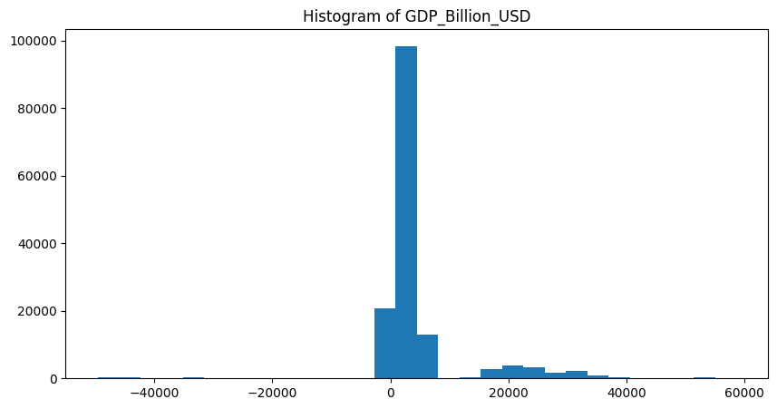

```python
plt.figure(figsize=(10,5))
plt.hist( df_clean[variable], bins=30)
plt.title(f"Histogram of {variable}")
plt.show()
```

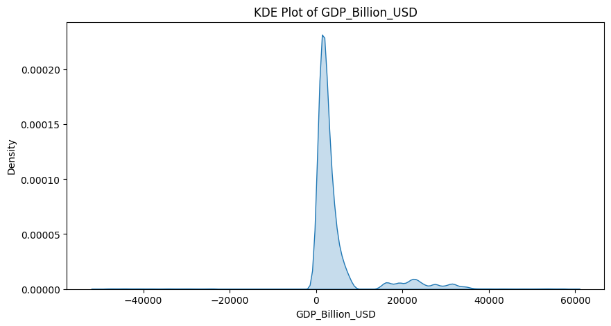

```python
plt.figure(figsize=(10,5))
sns.kdeplot(df_clean[variable],fill=True)
plt.title(f"KDE Plot of {variable}")
plt.show()
```

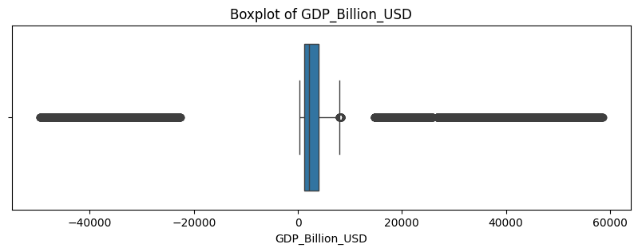

```python
plt.figure(figsize=(10,3))
sns.boxplot(x=df_clean[variable])
plt.title(f"Boxplot of {variable}")
plt.show()
```

```python
summary_table = pd.DataFrame({

    "Metric":[
        "Mean",
        "Median",
        "Mode",
        "Variance",
        "Std Dev",
        "Range",
        "IQR",
        "CV %",
        "Skewness",
        "Kurtosis"
    ],

    "Value":[
        round(mean_value,2),
        round(median_value,2),
        round(mode_value,2),
        round(variance_value,2),
        round(std_value,2),
        round(range_value,2),
        round(IQR,2),
        round(cv,2),
        round(skewness,3),
        round(kurtosis,3)
    ]
})

summary_table.style.format({"Value":"{:,.2f}"})
```

|  | Metric | Value |
| --- | --- | --- |
| 0 | Mean | 4,455.59 |
| 1 | Median | 2,116.58 |
| 2 | Mode | 426.38 |
| 3 | Variance | 79,487,621.17 |
| 4 | Std Dev | 8,915.58 |
| 5 | Range | 108,168.45 |
| 6 | IQR | 2,711.34 |
| 7 | CV % | 200.10 |
| 8 | Skewness | 1.11 |
| 9 | Kurtosis | 10.93 |

```python
df_clean[df_clean["GDP_Billion_USD"] < 0][
    ["Country","Date","GDP_Billion_USD"]
].head(20)
```

|  | Country | Date | GDP_Billion_USD |
| --- | --- | --- | --- |
| 302 | Turkey | 2010-12-01 | -29869.089912 |
| 316 | South Korea | 2009-07-01 | -42287.620911 |
| 472 | USA | 2016-07-01 | -26909.239763 |
| 582 | Italy | 2006-09-01 | -30601.046091 |
| 656 | Spain | 2018-01-01 | -44015.662638 |
| 732 | Netherlands | 2014-07-01 | -28932.833536 |
| 841 | Japan | 2014-10-01 | -26843.501175 |
| 857 | Spain | 2003-10-01 | -30465.473046 |
| 946 | Italy | 2025-11-01 | -23101.477384 |
| 1054 | France | 2016-03-01 | -35637.911650 |
| 1174 | Argentina | 2017-05-01 | -37285.904889 |
| 1683 | USA | 2018-07-01 | -46016.293112 |
| 1685 | Spain | 2020-11-01 | -43413.043434 |
| 1758 | India | 2004-05-01 | -34913.867396 |
| 1766 | Argentina | 2008-03-01 | -41499.269342 |
| 1794 | Saudi Arabia | 2025-06-01 | -36093.024652 |
| 1814 | Saudi Arabia | 2002-12-01 | -30714.165228 |
| 1954 | Netherlands | 2016-08-01 | -40028.363047 |
| 2059 | South Korea | 2024-09-01 | -34642.528364 |
| 2164 | Canada | 2021-07-01 | -47416.832536 |

```python
df_clean[df_clean["GDP_Billion_USD"] < 0].shape
```

```
(1556, 56)
```

```python
negative_gdp_count = (
    df_clean["GDP_Billion_USD"] < 0
).sum()

print(negative_gdp_count)
```

```
1556
```

```python
df_clean = df_clean[
    df_clean["GDP_Billion_USD"] > 0
]
```

```python
df_clean["GDP_Billion_USD"].min()
```

```
np.float64(246.473)
```

```python
df_clean.shape
```

```
(148444, 56)
```

# Project Report

## GDP_Billion_USD Analysis

Mean GDP: 4,882.86 Billion USD Median GDP: 2,131.20 Billion USD Distribution is highly right-skewed Significant variability exists across countries Presence of large economies creates a heavy-tailed distribution Data is not normally distributed

```python
variable = "Inflation_Rate"
```

```python
df_clean[variable].describe()
```

```
count    148444.000000
mean          6.035800
std          12.364537
min         -69.837255
25%           2.179000
50%           3.045000
75%           5.671000
max          82.284711
Name: Inflation_Rate, dtype: float64
```

```python
df_clean["Inflation_Rate"].sort_values().head(20)
```

```
142432   -69.837255
92014    -69.819205
22331    -69.813620
71855    -69.761502
1997     -69.743092
85022    -69.616999
111497   -69.603649
96916    -69.539115
108219   -69.506549
3604     -69.431816
71464    -69.408919
66106    -69.273207
58064    -69.208912
45054    -69.195638
488      -69.155227
127306   -69.139053
67894    -69.093199
128913   -69.064500
38908    -69.058737
56959    -69.052482
Name: Inflation_Rate, dtype: float64
```

```python
df_clean[df_clean["Inflation_Rate"] < -10][
    ["Country","Date","Inflation_Rate"]
].head(20)
```

|  | Country | Date | Inflation_Rate |
| --- | --- | --- | --- |
| 220 | South Africa | 2001-02-01 | -34.107368 |
| 243 | France | 2010-07-01 | -60.903284 |
| 393 | Turkey | 2024-10-01 | -68.617091 |
| 488 | UK | 2008-04-01 | -69.155227 |
| 564 | Turkey | 2015-07-01 | -48.384259 |
| 690 | South Korea | 2023-12-01 | -55.888862 |
| 877 | Mexico | 2002-06-01 | -63.333762 |
| 893 | Saudi Arabia | 2013-02-01 | -51.103265 |
| 1006 | South Korea | 2004-12-01 | -39.025125 |
| 1173 | Saudi Arabia | 2019-07-01 | -47.877950 |
| 1371 | South Korea | 2013-08-01 | -47.973027 |
| 1489 | USA | 2000-08-01 | -62.402994 |
| 1516 | USA | 2013-01-01 | -58.379778 |
| 1522 | Australia | 2013-01-01 | -42.985423 |
| 1552 | Brazil | 2014-01-01 | -47.647002 |
| 1761 | Brazil | 2024-02-01 | -51.914432 |
| 1769 | South Africa | 2001-08-01 | -40.422595 |
| 1786 | India | 2012-12-01 | -55.468524 |
| 1898 | China | 2012-04-01 | -63.201127 |
| 1997 | Netherlands | 2023-05-01 | -69.743092 |

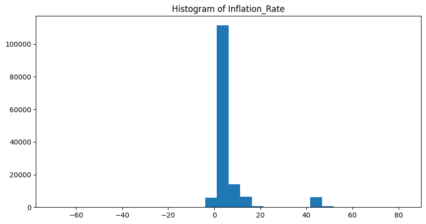

```python
plt.figure(figsize=(10,5))

plt.hist(df_clean[variable], bins=30)

plt.title(f"Histogram of {variable}")

plt.show()
```

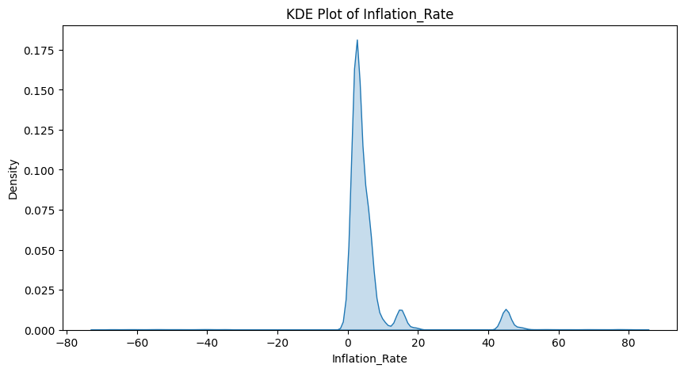

```python
plt.figure(figsize=(10,5))

sns.kdeplot(df_clean[variable], fill=True)

plt.title(f"KDE Plot of {variable}")

plt.show()
```

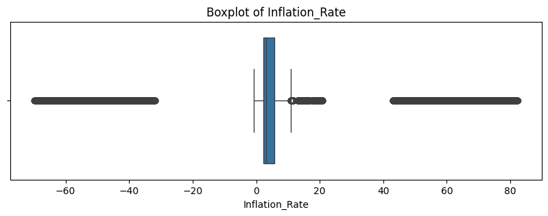

```python
plt.figure(figsize=(10,3))

sns.boxplot(x=df_clean[variable])

plt.title(f"Boxplot of {variable}")

plt.show()
```

### Inflation Rate Analysis

Key Findings:

- Most observations are concentrated between 0% and 10%.
- Distribution is not normal.
- Several extreme positive inflation values exist.
- Several extreme negative inflation values exist.
- Significant outliers are visible on both sides.
- Outlier treatment will be performed during the Outlier Analysis phase.

```python
variable = "Unemployment_Rate"
```

```python
df_clean[variable].describe()
```

```
count    148444.000000
mean          7.510015
std           7.522442
min         -38.791066
25%           4.032000
50%           5.973000
75%           9.412250
max          54.009912
Name: Unemployment_Rate, dtype: float64
```

```python
(df_clean["Unemployment_Rate"] < 0).sum()
```

```
np.int64(1490)
```

```python
df_clean["Unemployment_Rate"] = np.where(
    df_clean["Unemployment_Rate"] < 0,
    0,
    df_clean["Unemployment_Rate"]
)
```

```python
df_clean["Unemployment_Rate"].min()
```

```
np.float64(0.0)
```

```python
(df_clean["Unemployment_Rate"] < 0).sum()
```

```
np.int64(0)
```

```python
df_clean[variable].describe()
```

```
count    148444.000000
mean          7.784312
std           6.667125
min           0.000000
25%           4.032000
50%           5.973000
75%           9.412250
max          54.009912
Name: Unemployment_Rate, dtype: float64
```

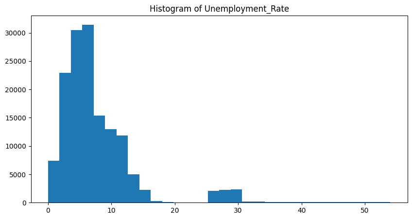

```python
plt.figure(figsize=(10,5))
plt.hist(df_clean[variable], bins=30)
plt.title(f"Histogram of {variable}")
plt.show()
```

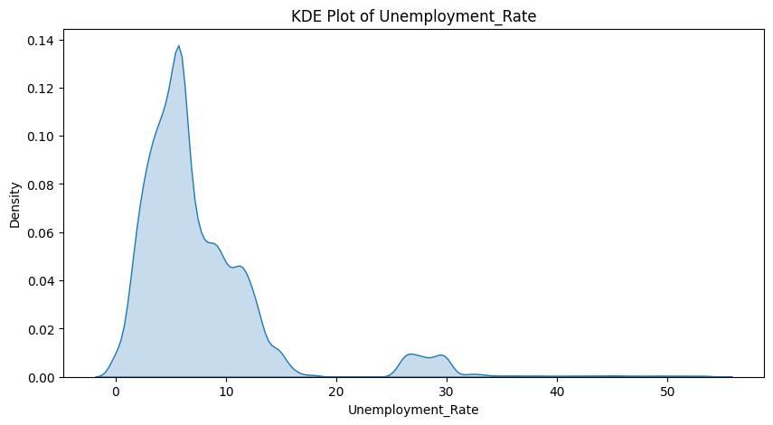

```python
plt.figure(figsize=(10,5))
sns.kdeplot( df_clean[variable],fill=True)
plt.title(f"KDE Plot of {variable}")
plt.show()
```

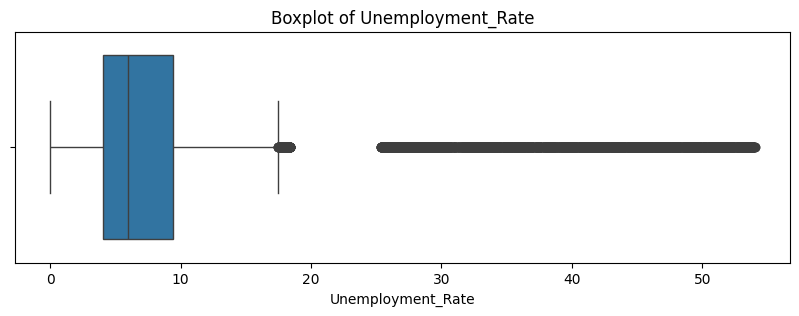

```python
plt.figure(figsize=(10,3))
sns.boxplot(x=df_clean[variable])
plt.title(f"Boxplot of {variable}")
plt.show()
```

### Unemployment Rate Analysis

Key Findings:

- Most observations fall between 3% and 12%.
- Average unemployment rate is approximately 7.8%.
- Distribution is positively skewed.
- High unemployment outliers exist.
- These outliers may represent economic stress periods or recessionary environments.

```python
variable = "Interest_Rate"
```

```python
df_clean[variable].describe()
```

```
count    148444.000000
mean          3.727118
std           5.712045
min          -0.097000
25%           1.260000
50%           1.986000
75%           3.489000
max          30.452000
Name: Interest_Rate, dtype: float64
```

```python
(df_clean["Interest_Rate"] < 0).sum()
```

```
np.int64(679)
```

```python
df_clean["Interest_Rate"] = np.where(
    df_clean["Interest_Rate"] < 0,
    0,
    df_clean["Interest_Rate"]
)
```

```python
df_clean["Interest_Rate"].min()
```

```
np.float64(0.0)
```

```python
(df_clean["Interest_Rate"] < 0).sum()
```

```
np.int64(0)
```

```python
df_clean[variable].describe()
```

```
count    148444.000000
mean          3.727219
std           5.711978
min           0.000000
25%           1.260000
50%           1.986000
75%           3.489000
max          30.452000
Name: Interest_Rate, dtype: float64
```

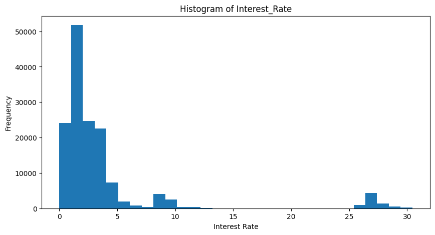

```python
plt.figure(figsize=(10,5))
plt.hist( df_clean["Interest_Rate"], bins=30)
plt.title("Histogram of Interest_Rate")
plt.xlabel("Interest Rate")
plt.ylabel("Frequency")
plt.show()
```

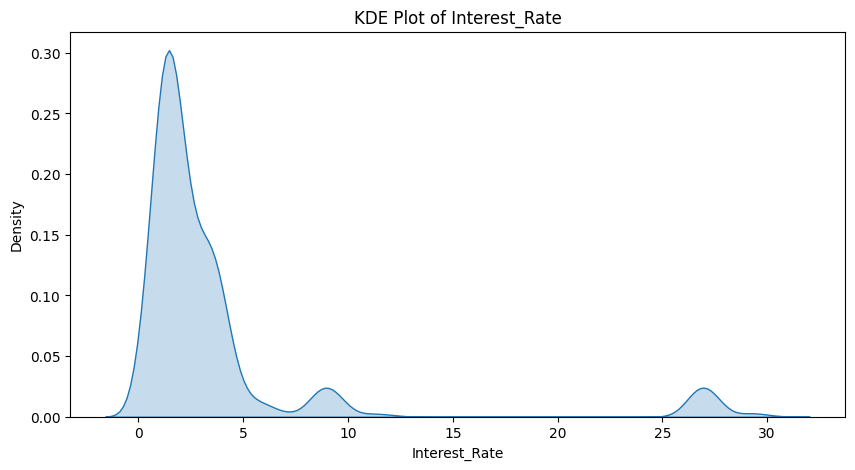

```python
plt.figure(figsize=(10,5))
sns.kdeplot(df_clean["Interest_Rate"],fill=True)
plt.title("KDE Plot of Interest_Rate")
plt.show()
```

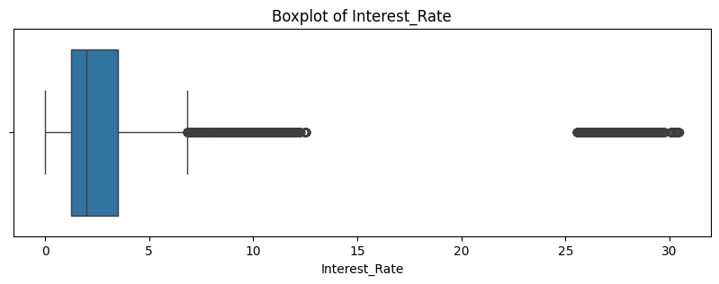

```python
plt.figure(figsize=(10,3))
sns.boxplot( x=df_clean["Interest_Rate"])
plt.title("Boxplot of Interest_Rate")
plt.show()
```

### Interest Rate Analysis

Key Findings:

- Most observations are concentrated between 1% and 5%.
- Distribution is positively skewed.
- Multiple monetary policy regimes are visible.
- High interest rate outliers exist.
- These observations may correspond to inflation-control periods or economic crises.

```python
variable = "Composite_Risk_Score"

df_clean[variable].describe()
```

```
count    148444.000000
mean          3.989391
std           0.801111
min           1.419000
25%           3.488000
50%           3.788000
75%           4.428000
max           9.157000
Name: Composite_Risk_Score, dtype: float64
```

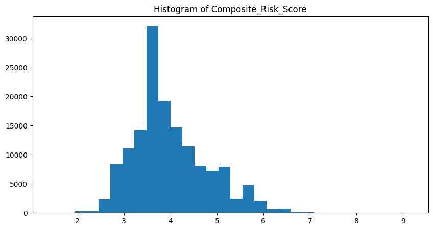

```python
plt.figure(figsize=(10,5))
plt.hist(df_clean["Composite_Risk_Score"],bins=30)
plt.title("Histogram of Composite_Risk_Score")
plt.show()
```

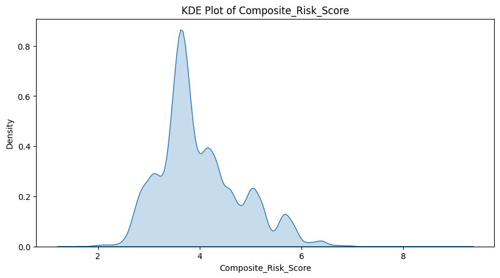

```python
plt.figure(figsize=(10,5))
sns.kdeplot(df_clean["Composite_Risk_Score"],fill=True)
plt.title("KDE Plot of Composite_Risk_Score")
plt.show()
```

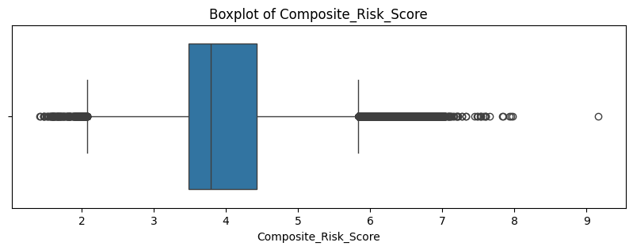

```python
plt.figure(figsize=(10,3))
sns.boxplot(x=df_clean["Composite_Risk_Score"])
plt.title("Boxplot of Composite_Risk_Score")
plt.show()
```

### Composite Risk Score Analysis

```python
min_values = pd.DataFrame({"Column": numerical_columns, "Min_Value": [df_clean[col].min()
        for col in numerical_columns
    ]
})

min_values.sort_values( "Min_Value")
```

|  | Column | Min_Value |
| --- | --- | --- |
| 17 | Stock_Index | -29586.950898 |
| 24 | Debt_Sustainability_Score | -24058.620000 |
| 18 | Market_Cap_Billion | -16570.197000 |
| 9 | Exchange_Rate_USD | -365.781138 |
| 10 | Trade_Balance_Billion | -213.014000 |
| 22 | Gov_Debt_pct_GDP | -143.982021 |
| 31 | Oil_Price_USD | -135.322143 |
| 8 | Real_Interest_Rate | -81.863000 |
| 5 | Inflation_Rate | -69.837255 |
| 23 | Budget_Deficit_pct | -14.522085 |
| 15 | Current_Account_pct | -12.088000 |
| 4 | GDP_Growth_Rate | -6.571000 |
| 20 | Credit_Growth_pct | -5.523000 |
| 38 | CO2_Emissions_MT | -1.419000 |
| 14 | FDI_Billion | -1.139000 |
| 21 | M2_Money_Growth_pct | -0.576000 |
| 6 | Unemployment_Rate | 0.000000 |
| 42 | Inflation_Shock | 0.000000 |
| 43 | Recession_Flag | 0.000000 |
| 7 | Interest_Rate | 0.000000 |
| 13 | Trade_Openness | 0.249000 |
| 35 | Poverty_Rate | 0.316000 |
| 41 | HDI_Proxy | 0.377100 |
| 34 | RnD_pct_GDP | 0.545000 |
| 1 | Month | 1.000000 |
| 40 | Composite_Risk_Score | 1.419000 |
| 39 | Renewable_Energy_pct | 7.421000 |
| 25 | Population_Million | 8.041000 |
| 16 | ForexReserves_Billion | 18.935000 |
| 19 | Consumer_Confidence | 19.593000 |
| 37 | Corruption_Index | 20.613000 |
| 36 | Gini_Coefficient | 24.748000 |
| 29 | Services_PMI | 36.649000 |
| 28 | Manufacturing_PMI | 36.950000 |
| 12 | Imports_Billion | 39.509000 |
| 11 | Exports_Billion | 52.636000 |
| 33 | Food_Price_Index | 87.728000 |
| 30 | Housing_Price_Index | 91.308000 |
| 26 | Industrial_Production | 92.083000 |
| 27 | Retail_Sales_Billion | 109.335000 |
| 32 | Gold_Price_USD | 236.204000 |
| 2 | GDP_Billion_USD | 246.473000 |
| 3 | GDP_Per_Capita_USD | 1692.934000 |
| 0 | Year | 2000.000000 |

```python
(df_clean["Stock_Index"] < 0).sum()
```

```
np.int64(10442)
```

```python
df_clean["Stock_Index"] = np.where(
    df_clean["Stock_Index"] < 0,
    0,
    df_clean["Stock_Index"]
)
```

```python
df_clean["Debt_Sustainability_Score"] = np.where(
    df_clean["Debt_Sustainability_Score"] < 0,
    0,
    df_clean["Debt_Sustainability_Score"]
)
```

```python
df_clean["Market_Cap_Billion"] = np.where(
    df_clean["Market_Cap_Billion"] < 0,
    0,
    df_clean["Market_Cap_Billion"]
)
```

```python
df_clean["Exchange_Rate_USD"] = np.where(
    df_clean["Exchange_Rate_USD"] < 0,
    0,
    df_clean["Exchange_Rate_USD"]
)
```

```python
df_clean["Oil_Price_USD"] = np.where(
    df_clean["Oil_Price_USD"] < 0,
    0,
    df_clean["Oil_Price_USD"]
)
```

```python
df_clean["Gov_Debt_pct_GDP"] = np.where(
    df_clean["Gov_Debt_pct_GDP"] < 0,
    0,
    df_clean["Gov_Debt_pct_GDP"]
)
```

```python
df_clean["CO2_Emissions_MT"] = np.where(
    df_clean["CO2_Emissions_MT"] < 0,
    0,
    df_clean["CO2_Emissions_MT"]
)
```

```python
columns_to_fix = [
    "Stock_Index",
    "Debt_Sustainability_Score",
    "Market_Cap_Billion",
    "Exchange_Rate_USD",
    "Oil_Price_USD",
    "Gov_Debt_pct_GDP",
    "CO2_Emissions_MT"
]

for col in columns_to_fix:

    df_clean[col] = np.where(
        df_clean[col] < 0,
        0,
        df_clean[col]
    )

print("Cleaning Completed")
```

```
Cleaning Completed
```

```python
for col in columns_to_fix:
    print(
        col,
        df_clean[col].min()
    )
```

```
Stock_Index 0.0
Debt_Sustainability_Score 0.0
Market_Cap_Billion 0.0
Exchange_Rate_USD 0.0
Oil_Price_USD 0.0
Gov_Debt_pct_GDP 0.0
CO2_Emissions_MT 0.0
```

```python
df_clean.shape
```

```
(148444, 56)
```

```python
min_values = pd.DataFrame({"Column": numerical_columns, "Min_Value": [df_clean[col].min()
        for col in numerical_columns
    ]
})

min_values.sort_values( "Min_Value")
```

|  | Column | Min_Value |
| --- | --- | --- |
| 10 | Trade_Balance_Billion | -213.014000 |
| 8 | Real_Interest_Rate | -81.863000 |
| 5 | Inflation_Rate | -69.837255 |
| 23 | Budget_Deficit_pct | -14.522085 |
| 15 | Current_Account_pct | -12.088000 |
| 4 | GDP_Growth_Rate | -6.571000 |
| 20 | Credit_Growth_pct | -5.523000 |
| 14 | FDI_Billion | -1.139000 |
| 21 | M2_Money_Growth_pct | -0.576000 |
| 9 | Exchange_Rate_USD | 0.000000 |
| 22 | Gov_Debt_pct_GDP | 0.000000 |
| 18 | Market_Cap_Billion | 0.000000 |
| 17 | Stock_Index | 0.000000 |
| 31 | Oil_Price_USD | 0.000000 |
| 7 | Interest_Rate | 0.000000 |
| 6 | Unemployment_Rate | 0.000000 |
| 24 | Debt_Sustainability_Score | 0.000000 |
| 42 | Inflation_Shock | 0.000000 |
| 43 | Recession_Flag | 0.000000 |
| 38 | CO2_Emissions_MT | 0.000000 |
| 13 | Trade_Openness | 0.249000 |
| 35 | Poverty_Rate | 0.316000 |
| 41 | HDI_Proxy | 0.377100 |
| 34 | RnD_pct_GDP | 0.545000 |
| 1 | Month | 1.000000 |
| 40 | Composite_Risk_Score | 1.419000 |
| 39 | Renewable_Energy_pct | 7.421000 |
| 25 | Population_Million | 8.041000 |
| 16 | ForexReserves_Billion | 18.935000 |
| 19 | Consumer_Confidence | 19.593000 |
| 37 | Corruption_Index | 20.613000 |
| 36 | Gini_Coefficient | 24.748000 |
| 29 | Services_PMI | 36.649000 |
| 28 | Manufacturing_PMI | 36.950000 |
| 12 | Imports_Billion | 39.509000 |
| 11 | Exports_Billion | 52.636000 |
| 33 | Food_Price_Index | 87.728000 |
| 30 | Housing_Price_Index | 91.308000 |
| 26 | Industrial_Production | 92.083000 |
| 27 | Retail_Sales_Billion | 109.335000 |
| 32 | Gold_Price_USD | 236.204000 |
| 2 | GDP_Billion_USD | 246.473000 |
| 3 | GDP_Per_Capita_USD | 1692.934000 |
| 0 | Year | 2000.000000 |

```python
print(categorical_columns)
```

```
['Quarter', 'Country', 'Region', 'Income_Group', 'Sector', 'AB_Test_Group', 'Policy_Intervention', 'Shock_Type', 'Economic_State', 'Risk_Level', 'Risk_Base']
```

```python
for col in categorical_columns:

    print("\n" + "="*50)

    print("Column :", col)

    print("Unique Values :", df_clean[col].nunique())

    print(df_clean[col].unique()[:20])
```

```
==================================================
Column : Quarter
Unique Values : 4
<ArrowStringArray>
['Q4', 'Q3', 'Q2', 'Q1']
Length: 4, dtype: str

==================================================
Column : Country
Unique Values : 20
<ArrowStringArray>
[   'Indonesia', 'Saudi Arabia',       'Canada', 'South Africa',
       'Turkey',        'Spain',           'UK',       'France',
        'China',       'Brazil',      'Germany',    'Australia',
          'USA',    'Argentina',        'Japan',  'Netherlands',
       'Mexico',  'South Korea',        'India',        'Italy']
Length: 20, dtype: str

==================================================
Column : Region
Unique Values : 5
<ArrowStringArray>
[        'Asia Pacific', 'Middle East & Africa',        'North America',
               'Europe',        'Latin America']
Length: 5, dtype: str

==================================================
Column : Income_Group
Unique Values : 3
<ArrowStringArray>
['Lower-Middle', 'High', 'Upper-Middle']
Length: 3, dtype: str

==================================================
Column : Sector
Unique Values : 8
<ArrowStringArray>
[        'Energy',         'Mining',  'Manufacturing', 'Tourism/Retail',
        'Finance',     'Healthcare',     'Technology',    'Agriculture']
Length: 8, dtype: str
```

[output cut: 27 more lines]

```
Length: 4, dtype: str

==================================================
Column : Risk_Level
Unique Values : 4
<ArrowStringArray>
['Medium', 'Low', 'High', 'Critical']
Length: 4, dtype: str

==================================================
Column : Risk_Base
Unique Values : 3
<ArrowStringArray>
['Medium', 'Low', 'High']
Length: 3, dtype: str
```

```python
df_clean["Region"].value_counts()
```

```
Region
Europe                  52042
Asia Pacific            44439
Latin America           22255
Middle East & Africa    14892
North America           14816
Name: count, dtype: int64
```

```python
round(
    df_clean["Region"].value_counts(normalize=True)*100,
    2
)
```

```
Region
Europe                  35.06
Asia Pacific            29.94
Latin America           14.99
Middle East & Africa    10.03
North America            9.98
Name: proportion, dtype: float64
```

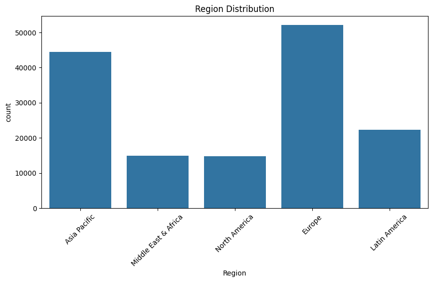

```python
plt.figure(figsize=(10,5))
sns.countplot(data=df_clean,x="Region")
plt.title("Region Distribution")
plt.xticks(rotation=45)
plt.show()
```

```python
df_clean["Income_Group"].value_counts()
```

```
Income_Group
High            89137
Upper-Middle    44582
Lower-Middle    14725
Name: count, dtype: int64
```

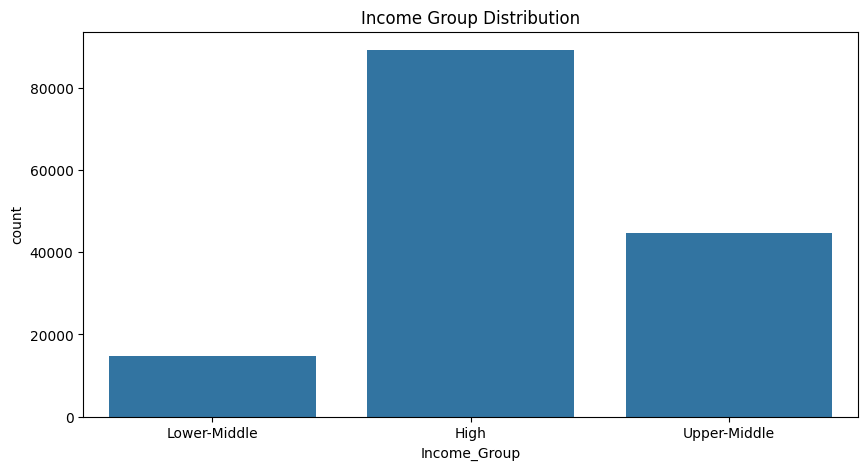

```python
plt.figure(figsize=(10,5))
sns.countplot(data=df_clean,x="Income_Group")
plt.title("Income Group Distribution")
plt.show()
```

```python
country_counts = (df_clean["Country"].value_counts().head(10))
country_counts
```

```
Country
Germany         7528
South Korea     7520
Turkey          7512
Indonesia       7492
Brazil          7457
Saudi Arabia    7451
Netherlands     7448
Mexico          7446
South Africa    7441
USA             7435
Name: count, dtype: int64
```

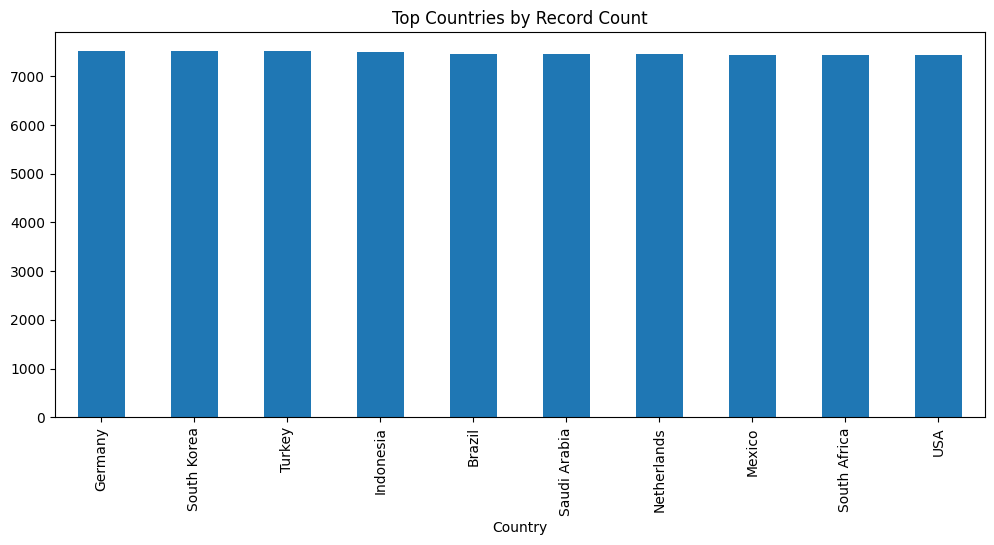

```python
plt.figure(figsize=(12,5))
country_counts.plot(kind="bar")
plt.title("Top Countries by Record Count")
plt.show()
```

```python
df_clean["Risk_Level"].value_counts()
```

```
Risk_Level
Medium      77641
Low         40976
Critical    16756
High        13071
Name: count, dtype: int64
```

```python
round(
    df_clean["Risk_Level"].value_counts(normalize=True)*100,
    2
)
```

```
Risk_Level
Medium      52.30
Low         27.60
Critical    11.29
High         8.81
Name: proportion, dtype: float64
```

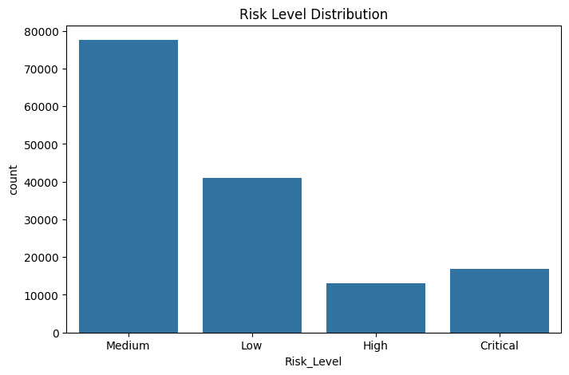

```python
plt.figure(figsize=(8,5))
sns.countplot(data=df_clean,x="Risk_Level")
plt.title("Risk Level Distribution")
plt.show()
```

This step is focused on categorical analysis. I analyzed the distribution of regions, income groups, countries, and risk levels. The dataset is dominated by Europe and Asia Pacific regions, contains mostly high-income economies, and is evenly distributed across countries. Risk analysis showed that the majority of observations belong to the medium-risk category, while high-risk and critical-risk cases are relatively limited. These insights helped me understand the composition and segmentation of the dataset before moving into relationship analysis and advanced analytics.

# QQ Plot Analysis

```python
variable = "GDP_Billion_USD"
```

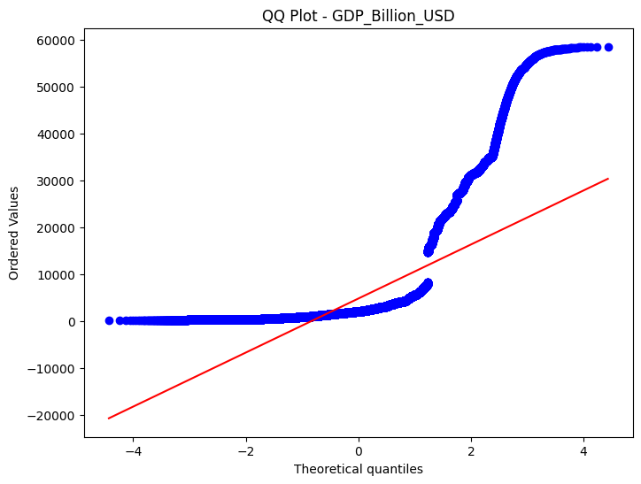

```python
plt.figure(figsize=(8,6))
stats.probplot(df_clean[variable],dist="norm",plot=plt)
plt.title(f"QQ Plot - {variable}")
plt.show()
```

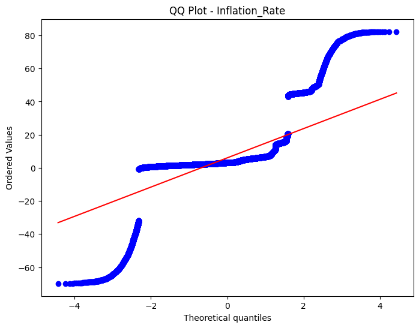

```python
variable = "Inflation_Rate"
plt.figure(figsize=(8,6))
stats.probplot(df_clean[variable],dist="norm", plot=plt)
plt.title(f"QQ Plot - {variable}")
plt.show()
```

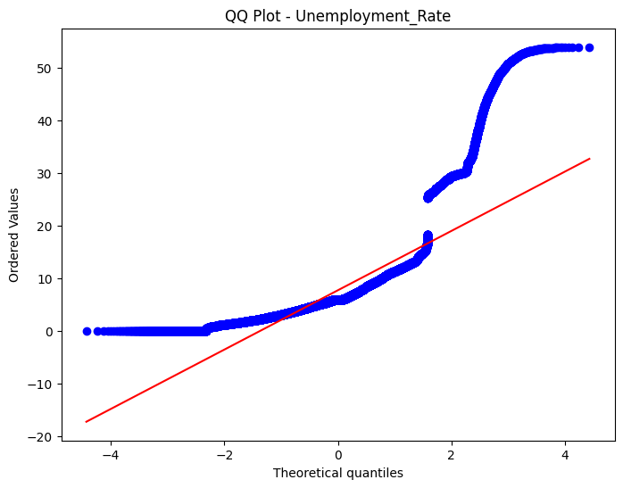

```python
variable = "Unemployment_Rate"

plt.figure(figsize=(8,6))
stats.probplot(df_clean[variable],dist="norm",plot=plt)
plt.title(f"QQ Plot - {variable}")
plt.show()
```

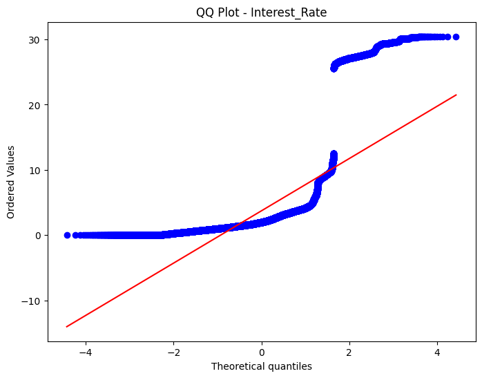

```python
variable = "Interest_Rate"

plt.figure(figsize=(8,6))
stats.probplot(df_clean[variable],dist="norm",plot=plt)
plt.title(f"QQ Plot - {variable}")
plt.show()
```

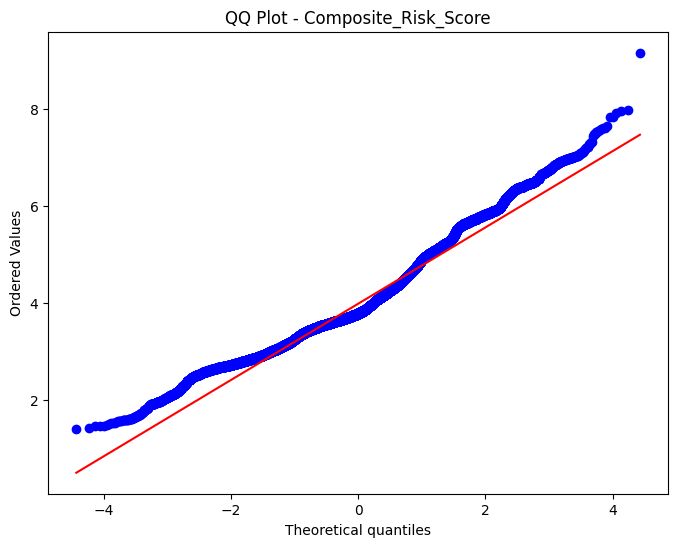

```python
variable = "Composite_Risk_Score"

plt.figure(figsize=(8,6))
stats.probplot(df_clean[variable],dist="norm",plot=plt)
plt.title(f"QQ Plot - {variable}")
plt.show()
```

# QQ Plot

## Objective

QQ Plot was used to compare the distribution of selected numerical variables against a theoretical normal distribution.

This analysis helps determine whether variables satisfy normality assumptions required for several statistical techniques such as correlation analysis, hypothesis testing, ANOVA, and regression modeling.

## Variables Evaluated

- GDP_Billion_USD
- Inflation_Rate
- Unemployment_Rate
- Interest_Rate
- Composite_Risk_Score

## Key Findings

### GDP_Billion_USD

- Strong deviation from the reference line.
- Distribution is highly right-skewed.
- Not normally distributed.

Business Insight: A small number of countries contribute disproportionately large economic output.

### Inflation_Rate

- Significant deviation from normality.
- Extreme tails are present.
- Not normally distributed.

Business Insight: The dataset contains both inflationary and deflationary periods, reflecting economic instability across different countries and time periods.

### Unemployment_Rate

Business Insight: Most observations exhibit moderate unemployment levels, while a small number represent severe labor market stress.

### Interest_Rate

- Clear deviation from the normal distribution line.
- Positively skewed distribution.
- Not normally distributed.

Business Insight: Most economies operate under low-to-moderate interest rate environments, while a limited number experience aggressive monetary tightening.

### Composite_Risk_Score

- Points closely follow the reference line.
- Near-normal distribution.
- Most statistically stable variable in the dataset.

Business Insight: Overall economic risk is concentrated around a moderate level for the majority of observations.

## Overall Conclusion

QQ Plot analysis indicates that GDP, Inflation, Unemployment, and Interest Rate variables do not follow a normal distribution, whereas Composite_Risk_Score is approximately normally distributed.

These findings will be considered in subsequent statistical analyses, including outlier detection, correlation analysis, hypothesis testing, and predictive modeling.

# Z-Score Analysis

```python
variable = "GDP_Billion_USD"
```

```python
df_clean["GDP_ZScore"] = zscore(
    df_clean[variable]
)
```

```python
df_clean["GDP_ZScore"].describe()
```

```
count    1.484440e+05
mean     4.288798e-17
std      1.000003e+00
min     -5.884912e-01
25%     -4.551645e-01
50%     -3.492655e-01
75%     -1.142388e-01
max      6.816575e+00
Name: GDP_ZScore, dtype: float64
```

```python
gdp_outliers = df_clean[abs(df_clean["GDP_ZScore"]) > 3]
print("GDP Outliers :",len(gdp_outliers))
```

```
GDP Outliers : 4615
```

```python
outlier_pct = (len(gdp_outliers)/ len(df_clean)) * 100
print(round(outlier_pct,2),"%")
```

```
3.11 %
```

```python
gdp_outliers[["Country","Date","GDP_Billion_USD","GDP_ZScore"]].head(20)
```

|  | Country | Date | GDP_Billion_USD | GDP_ZScore |
| --- | --- | --- | --- | --- |
| 1 | Saudi Arabia | 2005-08-01 | 46194.709565 | 5.243663 |
| 15 | USA | 2015-04-01 | 28943.775000 | 3.054023 |
| 25 | South Africa | 2002-06-01 | 40682.124243 | 4.543958 |
| 36 | USA | 2019-12-01 | 31565.011000 | 3.386733 |
| 55 | Italy | 2000-02-01 | 53928.835468 | 6.225347 |
| 131 | USA | 2015-08-01 | 28830.912000 | 3.039697 |
| 170 | USA | 2020-02-01 | 31574.767000 | 3.387972 |
| 185 | USA | 2021-09-01 | 31487.270000 | 3.376866 |
| 293 | USA | 2023-08-01 | 32932.283000 | 3.560280 |
| 336 | USA | 2017-01-01 | 30223.568000 | 3.216466 |
| 378 | USA | 2018-11-01 | 31212.200000 | 3.341951 |
| 384 | Spain | 2004-04-01 | 35768.174032 | 3.920236 |
| 425 | USA | 2025-05-01 | 35028.470000 | 3.826346 |
| 433 | USA | 2015-06-01 | 28973.374000 | 3.057780 |
| 469 | USA | 2018-10-01 | 31344.011000 | 3.358682 |
| 477 | USA | 2021-09-01 | 31465.512000 | 3.374104 |
| 508 | USA | 2015-04-01 | 28870.762000 | 3.044756 |
| 586 | USA | 2015-11-01 | 29045.704000 | 3.066961 |
| 593 | Italy | 2008-10-01 | 52779.591054 | 6.079475 |
| 629 | USA | 2014-12-01 | 28564.970000 | 3.005942 |

```python
variables = [
    "GDP_Billion_USD",
    "Inflation_Rate",
    "Unemployment_Rate",
    "Interest_Rate",
    "Composite_Risk_Score"
]

zscore_summary = []

for col in variables:
    z_scores = zscore(df_clean[col])
    outliers = (abs(z_scores) > 3).sum()
    pct = round( outliers/len(df_clean)*100,2)
    zscore_summary.append([col, outliers, pct])

pd.DataFrame(
    zscore_summary,
    columns=[
        "Variable",
        "Outlier_Count",
        "Outlier_%"
    ]
)
```

|  | Variable | Outlier_Count | Outlier_% |
| --- | --- | --- | --- |
| 0 | GDP_Billion_USD | 4615 | 3.11 |
| 1 | Inflation_Rate | 9821 | 6.62 |
| 2 | Unemployment_Rate | 5186 | 3.49 |
| 3 | Interest_Rate | 7352 | 4.95 |
| 4 | Composite_Risk_Score | 762 | 0.51 |

```python
df_clean["Inflation_ZScore"] = zscore(df_clean["Inflation_Rate"])
inflation_outliers = df_clean[abs(df_clean["Inflation_ZScore"]) > 3]
inflation_outliers.shape
```

```
(9821, 58)
```

```python
inflation_outliers["Country"].value_counts()
```

```
Country
Argentina       6981
Spain            174
Saudi Arabia     171
Turkey           159
Netherlands      157
China            154
Italy            151
Japan            151
Australia        150
South Africa     149
France           148
Brazil           147
Indonesia        146
UK               146
Germany          146
USA              143
Mexico           143
Canada           143
India            134
South Korea      128
Name: count, dtype: int64
```

```python
inflation_outliers[["Country","Date", "Inflation_Rate","Inflation_ZScore"]
].sort_values("Inflation_Rate",ascending=False).head(20)
```

|  | Country | Date | Inflation_Rate | Inflation_ZScore |
| --- | --- | --- | --- | --- |
| 142245 | India | 2014-10-01 | 82.284711 | 6.166763 |
| 49862 | Saudi Arabia | 2010-08-01 | 82.227708 | 6.162153 |
| 18061 | China | 2013-01-01 | 82.213293 | 6.160987 |
| 103455 | Indonesia | 2015-05-01 | 82.190119 | 6.159113 |
| 54647 | Saudi Arabia | 2014-08-01 | 82.153109 | 6.156119 |
| 109362 | Spain | 2018-11-01 | 82.147834 | 6.155693 |
| 117896 | China | 2004-03-01 | 82.138793 | 6.154961 |
| 69704 | Netherlands | 2024-01-01 | 82.100752 | 6.151885 |
| 116629 | France | 2008-11-01 | 82.099610 | 6.151792 |
| 98054 | UK | 2011-12-01 | 82.079907 | 6.150199 |
| 38213 | Saudi Arabia | 2017-03-01 | 82.034408 | 6.146519 |
| 141346 | USA | 2024-02-01 | 82.031906 | 6.146317 |
| 90821 | Saudi Arabia | 2017-05-01 | 82.021572 | 6.145481 |
| 108695 | USA | 2000-05-01 | 82.013579 | 6.144834 |
| 29015 | Germany | 2003-07-01 | 81.985807 | 6.142588 |
| 103690 | Germany | 2009-01-01 | 81.979433 | 6.142073 |
| 19396 | Japan | 2013-10-01 | 81.956077 | 6.140184 |
| 34004 | Italy | 2013-06-01 | 81.951001 | 6.139773 |
| 53275 | Argentina | 2013-09-01 | 81.948603 | 6.139580 |
| 91355 | Brazil | 2004-05-01 | 81.947453 | 6.139487 |

```python
argentina = df_clean[ df_clean["Country"] == "Argentina"]
argentina["Inflation_Rate"].describe()
```

```
count    7352.000000
mean       42.471945
std        13.623366
min       -69.837255
25%        44.526000
50%        44.970000
75%        45.542000
max        81.948603
Name: Inflation_Rate, dtype: float64
```

# Z-Score Outlier Analysis

## Objective

Z-Score analysis was performed to identify statistically extreme observations. A threshold of ±3 was used to detect potential outliers.

## Conclusion

Outliers were identified but retained because they represent genuine economic conditions rather than data quality issues.

# IQR Outlier Detection

```python
variable = "GDP_Billion_USD"
```

```python
Q1 = df_clean[variable].quantile(0.25)
Q3 = df_clean[variable].quantile(0.75)
IQR = Q3 - Q1
print("Q1 :",Q1)
print("Q3 :",Q3)
print("IQR :",IQR)
```

```
Q1 : 1296.8780000000002
Q3 : 3982.8385
IQR : 2685.9604999999997
```

```python
lower_limit = Q1 - 1.5 * IQR
upper_limit = Q3 + 1.5 * IQR
print("Lower Limit :",lower_limit)
print("Upper Limit :",upper_limit)
```

```
Lower Limit : -2732.0627499999996
Upper Limit : 8011.77925
```

```python
gdp_iqr_outliers = df_clean[
    (df_clean[variable] < lower_limit)
    |
    (df_clean[variable] > upper_limit)
]
```

```python
print("IQR Outliers :",len(gdp_iqr_outliers))
```

```
IQR Outliers : 16401
```

```python
iqr_pct = round(len(gdp_iqr_outliers) /len(df_clean) *100,2)
print("Outlier Percentage :", iqr_pct,"%")
```

```
Outlier Percentage : 11.05 %
```

```python
gdp_iqr_outliers[
    [
        "Country",
        "Date",
        "GDP_Billion_USD"
    ]
].head(20)
```

|  | Country | Date | GDP_Billion_USD |
| --- | --- | --- | --- |
| 1 | Saudi Arabia | 2005-08-01 | 46194.709565 |
| 9 | China | 2011-03-01 | 19198.765000 |
| 15 | USA | 2015-04-01 | 28943.775000 |
| 19 | Japan | 2025-03-01 | 8165.455000 |
| 25 | South Africa | 2002-06-01 | 40682.124243 |
| 30 | China | 2024-12-01 | 24045.180000 |
| 36 | USA | 2019-12-01 | 31565.011000 |
| 39 | China | 2016-10-01 | 20932.982000 |
| 40 | USA | 2013-09-01 | 27426.384000 |
| 41 | China | 2023-05-01 | 23187.596000 |
| 55 | Italy | 2000-02-01 | 53928.835468 |
| 58 | USA | 2002-09-01 | 22731.783000 |
| 65 | China | 2002-11-01 | 15980.042000 |
| 78 | USA | 2013-05-01 | 27561.252000 |
| 83 | China | 2007-12-01 | 17538.835000 |
| 86 | China | 2024-05-01 | 23889.944000 |
| 90 | USA | 2009-10-01 | 25353.930000 |
| 93 | USA | 2004-07-01 | 23244.805000 |
| 114 | China | 2002-08-01 | 15980.157000 |
| 124 | USA | 2007-08-01 | 24776.937000 |

### GDP IQR Outlier Findings

Observations:

- Q1 = 1296.88
- Q3 = 3982.84
- IQR = 2685.96
- Lower Bound = -2732.06
- Upper Bound = 8011.78

Results:

- IQR Outliers = 16,401
- Outlier Percentage = 11.05%

Comparison with Z-Score:

- Z-Score Outliers = 4,615 (3.11%)
- IQR Outliers = 16,401 (11.05%)

Business Interpretation:

The IQR method detected substantially more GDP outliers because GDP exhibits a strongly right-skewed distribution. Most identified outliers correspond to economically significant countries with exceptionally large GDP values and therefore should be retained.

```python
variables = [
    "GDP_Billion_USD",
    "Inflation_Rate",
    "Unemployment_Rate",
    "Interest_Rate",
    "Composite_Risk_Score"
]

iqr_summary = []
for col in variables:

    Q1 = df_clean[col].quantile(0.25)
    Q3 = df_clean[col].quantile(0.75)
    IQR = Q3 - Q1
    lower_limit = Q1 - 1.5 * IQR
    upper_limit = Q3 + 1.5 * IQR
    outliers = (
        (
            df_clean[col] < lower_limit
        )
        |
        (
            df_clean[col] > upper_limit
        )
    ).sum()
    pct = round(outliers / len(df_clean) * 100, 2)

    iqr_summary.append(
        [col, outliers, pct]
    )

iqr_summary_df = pd.DataFrame(
    iqr_summary,
    columns=[
        "Variable",
        "IQR_Outlier_Count",
        "IQR_Outlier_%"
    ]
)

iqr_summary_df
```

|  | Variable | IQR_Outlier_Count | IQR_Outlier_% |
| --- | --- | --- | --- |
| 0 | GDP_Billion_USD | 16401 | 11.05 |
| 1 | Inflation_Rate | 17058 | 11.49 |
| 2 | Unemployment_Rate | 8525 | 5.74 |
| 3 | Interest_Rate | 15125 | 10.19 |
| 4 | Composite_Risk_Score | 3418 | 2.30 |

# IQR Outlier Detection

## Objective

To identify extreme observations using the Interquartile Range (IQR) method and compare results with Z-Score analysis.

## Comparison with Z-Score

The IQR method detected a higher proportion of outliers across all variables.

This outcome is expected because several economic indicators exhibit non-normal and positively skewed distributions.

## Business Insights

- Inflation Rate is the most volatile indicator.
- GDP contains many economically significant extreme observations.
- Interest Rate displays substantial variability across countries and periods.
- Composite Risk Score remains the most stable variable.

## Conclusion

Outliers were retained because they represent genuine economic conditions rather than data quality issues.

# Pearson Correlation Analysis

```python
corr_matrix = df_clean[numerical_columns].corr( method="pearson")
corr_matrix
```

|  | Year | Month | GDP_Billion_USD | GDP_Per_Capita_USD | GDP_Growth_Rate | Inflation_Rate | Unemployment_Rate | Interest_Rate | Real_Interest_Rate | Exchange_Rate_USD | Trade_Balance_Billion | Exports_Billion | Imports_Billion | Trade_Openness | FDI_Billion | Current_Account_pct | ForexReserves_Billion | Stock_Index | Market_Cap_Billion | Consumer_Confidence | Credit_Growth_pct | M2_Money_Growth_pct | Gov_Debt_pct_GDP | Budget_Deficit_pct | Debt_Sustainability_Score | Population_Million | Industrial_Production | Retail_Sales_Billion | Manufacturing_PMI | … |
| --- | --- | --- | --- | --- | --- | --- | --- | --- | --- | --- | --- | --- | --- | --- | --- | --- | --- | --- | --- | --- | --- | --- | --- | --- | --- | --- | --- | --- | --- | --- |
| Year | 1.000000 | -0.002220 | 0.079682 | 0.107962 | -0.015925 | 0.037222 | 0.031300 | 0.050279 | -0.020510 | 0.028977 | 0.341616 | 0.090112 | 0.088041 | -0.006059 | 0.086748 | 0.009460 | 0.093503 | -0.486355 | -0.390866 | -0.634958 | 0.014644 | 0.132121 | 0.071360 | -0.041333 | 0.067456 | 0.038138 | 0.903696 | 0.093632 | -0.055079 | … |
| Month | -0.002220 | 1.000000 | 0.001747 | -0.004614 | -0.005950 | -0.021229 | 0.004341 | -0.030703 | 0.011133 | 0.001005 | 0.009536 | 0.001934 | 0.001901 | -0.003876 | 0.005480 | -0.000505 | 0.001881 | -0.010726 | -0.009101 | -0.038269 | -0.023033 | 0.032975 | 0.005871 | -0.041319 | 0.001458 | 0.003555 | -0.215804 | 0.000784 | -0.422583 | … |
| GDP_Billion_USD | 0.079682 | 0.001747 | 1.000000 | 0.278717 | 0.007219 | -0.109961 | -0.181904 | -0.154219 | 0.057407 | -0.007782 | -0.355230 | 0.839990 | 0.840112 | -0.068667 | 0.793242 | 0.002818 | 0.850355 | -0.074815 | 0.319411 | 0.065972 | -0.012428 | 0.008536 | 0.152928 | 0.000655 | 0.943373 | 0.399683 | 0.072028 | 0.850381 | -0.004648 | … |
| GDP_Per_Capita_USD | 0.107962 | -0.004614 | 0.278717 | 1.000000 | 0.014620 | -0.256505 | -0.335574 | -0.358090 | 0.134858 | 0.247364 | 0.092811 | 0.265773 | 0.264693 | -0.102295 | 0.305715 | 0.006456 | 0.328036 | 0.128428 | 0.283589 | 0.148340 | 0.010773 | 0.005964 | 0.201925 | 0.011486 | 0.214405 | -0.375881 | 0.100942 | 0.327990 | 0.003985 | … |
| GDP_Growth_Rate | -0.015925 | -0.005950 | 0.007219 | 0.014620 | 1.000000 | 0.014041 | -0.107911 | 0.018820 | -0.008059 | 0.003341 | -0.010665 | 0.009899 | 0.009975 | 0.003901 | 0.005938 | -0.011014 | 0.010403 | 0.019371 | 0.015786 | 0.192429 | 0.185504 | -0.408461 | -0.037263 | 0.310592 | 0.014005 | 0.002786 | 0.140116 | 0.010189 | 0.355340 | … |
| Inflation_Rate | 0.037222 | -0.021229 | -0.109961 | -0.256505 | 0.014041 | 1.000000 | 0.124477 | 0.713543 | -0.908737 | -0.203369 | 0.160071 | -0.124941 | -0.125487 | -0.143532 | -0.120767 | -0.020163 | -0.129027 | -0.107998 | -0.121407 | -0.134118 | -0.001049 | 0.001914 | -0.072490 | 0.006267 | -0.109387 | -0.055256 | 0.041535 | -0.128968 | 0.007987 | … |
| Unemployment_Rate | 0.031300 | 0.004341 | -0.181904 | -0.335574 | -0.107911 | 0.124477 | 1.000000 | 0.174661 | -0.065021 | -0.038976 | 0.237609 | -0.199358 | -0.200194 | -0.014828 | -0.199170 | -0.005912 | -0.213787 | -0.090945 | -0.178206 | -0.423725 | -0.036315 | 0.086680 | -0.067812 | -0.060407 | -0.175433 | -0.098004 | -0.002450 | -0.213665 | -0.068039 | … |
| Interest_Rate | 0.050279 | -0.030703 | -0.154219 | -0.358090 | 0.018820 | 0.713543 | 0.174661 | 1.000000 | -0.372918 | -0.284310 | 0.222605 | -0.174425 | -0.175168 | -0.199884 | -0.169895 | -0.030634 | -0.180487 | -0.149511 | -0.169271 | -0.188840 | -0.001689 | -0.004133 | -0.102379 | 0.013202 | -0.151941 | -0.077091 | 0.058076 | -0.180368 | 0.018527 | … |
| Real_Interest_Rate | -0.020510 | 0.011133 | 0.057407 | 0.134858 | -0.008059 | -0.908737 | -0.065021 | -0.372918 | 1.000000 | 0.106540 | -0.084693 | 0.065623 | 0.065925 | 0.075633 | 0.062676 | 0.009165 | 0.067570 | 0.057757 | 0.063936 | 0.069699 | -0.000242 | -0.004412 | 0.037647 | -0.001007 | 0.057967 | 0.029013 | -0.022081 | 0.067561 | -0.000418 | … |
| Exchange_Rate_USD | 0.028977 | 0.001005 | -0.007782 | 0.247364 | 0.003341 | -0.203369 | -0.038976 | -0.284310 | 0.106540 | 1.000000 | 0.125010 | 0.044868 | 0.044093 | 0.326136 | -0.010045 | -0.001820 | -0.012142 | 0.093508 | -0.018060 | 0.021537 | 0.005525 | 0.001128 | 0.172772 | -0.000036 | 0.028434 | 0.229450 | 0.028310 | -0.012219 | -0.005608 | … |
| Trade_Balance_Billion | 0.341616 | 0.009536 | -0.355230 | 0.092811 | -0.010665 | 0.160071 | 0.237609 | 0.222605 | -0.084693 | 0.125010 | 1.000000 | -0.394269 | -0.398463 | 0.056235 | -0.391210 | -0.016708 | -0.418968 | -0.258277 | -0.422022 | -0.361984 | 0.011734 | 0.049918 | -0.166820 | -0.016462 | -0.300236 | -0.384743 | 0.307230 | -0.418956 | -0.028261 | … |
| Exports_Billion | 0.090112 | 0.001934 | 0.839990 | 0.265773 | 0.009899 | -0.124941 | -0.199358 | -0.174425 | 0.065623 | 0.044868 | -0.394269 | 1.000000 | 0.999962 | 0.276097 | 0.920805 | -0.000410 | 0.987458 | -0.102275 | 0.333060 | 0.069608 | -0.012132 | 0.009453 | 0.158096 | 0.002819 | 0.753557 | 0.538166 | 0.082645 | 0.987485 | -0.006518 | … |
| Imports_Billion | 0.088041 | 0.001901 | 0.840112 | 0.264693 | 0.009975 | -0.125487 | -0.200194 | -0.175168 | 0.065925 | 0.044093 | -0.398463 | 0.999962 | 1.000000 | 0.275291 | 0.920935 | -0.000411 | 0.987599 | -0.100684 | 0.334616 | 0.071391 | -0.012159 | 0.009163 | 0.158646 | 0.002888 | 0.753566 | 0.539063 | 0.080762 | 0.987626 | -0.006352 | … |
| Trade_Openness | -0.006059 | -0.003876 | -0.068667 | -0.102295 | 0.003901 | -0.143532 | -0.014828 | -0.199884 | 0.075633 | 0.326136 | 0.056235 | 0.276097 | 0.275291 | 1.000000 | 0.172152 | -0.007867 | 0.184386 | -0.114253 | -0.056712 | 0.028701 | 0.007725 | 0.000653 | -0.013214 | 0.002234 | -0.073173 | 0.337201 | 0.001655 | 0.184375 | 0.000351 | … |
| FDI_Billion | 0.086748 | 0.005480 | 0.793242 | 0.305715 | 0.005938 | -0.120767 | -0.199170 | -0.169895 | 0.062676 | -0.010045 | -0.391210 | 0.920805 | 0.920935 | 0.172152 | 1.000000 | 0.002908 | 0.932788 | -0.083713 | 0.344154 | 0.069741 | -0.011899 | 0.010893 | 0.168962 | 0.003699 | 0.696882 | 0.438737 | 0.076652 | 0.932783 | -0.012492 | … |
| Current_Account_pct | 0.009460 | -0.000505 | 0.002818 | 0.006456 | -0.011014 | -0.020163 | -0.005912 | -0.030634 | 0.009165 | -0.001820 | -0.016708 | -0.000410 | -0.000411 | -0.007867 | 0.002908 | 1.000000 | 0.001794 | -0.000509 | 0.003955 | 0.003722 | -0.001256 | 0.003194 | 0.001047 | 0.000977 | 0.001845 | 0.001728 | 0.010516 | 0.001880 | 0.006504 | … |
| ForexReserves_Billion | 0.093503 | 0.001881 | 0.850355 | 0.328036 | 0.010403 | -0.129027 | -0.213787 | -0.180487 | 0.067570 | -0.012142 | -0.418968 | 0.987458 | 0.987599 | 0.184386 | 0.932788 | 0.001794 | 1.000000 | -0.087731 | 0.376760 | 0.076900 | -0.013090 | 0.009558 | 0.179228 | 0.003512 | 0.748088 | 0.469018 | 0.084763 | 0.999947 | -0.005657 | … |
| Stock_Index | -0.486355 | -0.010726 | -0.074815 | 0.128428 | 0.019371 | -0.107998 | -0.090945 | -0.149511 | 0.057757 | 0.093508 | -0.258277 | -0.102275 | -0.100684 | -0.114253 | -0.083713 | -0.000509 | -0.087731 | 1.000000 | 0.438600 | 0.512059 | 0.021245 | -0.058689 | 0.042568 | 0.042542 | -0.072117 | -0.106988 | -0.427377 | -0.087720 | 0.055629 | … |
| Market_Cap_Billion | -0.390866 | -0.009101 | 0.319411 | 0.283589 | 0.015786 | -0.121407 | -0.178206 | -0.169271 | 0.063936 | -0.018060 | -0.422022 | 0.333060 | 0.334616 | -0.056712 | 0.344154 | 0.003955 | 0.376760 | 0.438600 | 1.000000 | 0.455027 | 0.007922 | -0.052191 | 0.092289 | 0.031211 | 0.277515 | 0.054533 | -0.344219 | 0.376719 | 0.042595 | … |
| Consumer_Confidence | -0.634958 | -0.038269 | 0.065972 | 0.148340 | 0.192429 | -0.134118 | -0.423725 | -0.188840 | 0.069699 | 0.021537 | -0.361984 | 0.069608 | 0.071391 | 0.028701 | 0.069741 | 0.003722 | 0.076900 | 0.512059 | 0.455027 | 1.000000 | 0.146857 | -0.211321 | -0.013919 | 0.192964 | 0.071599 | 0.036594 | -0.482505 | 0.076723 | 0.231803 | … |
| Credit_Growth_pct | 0.014644 | -0.023033 | -0.012428 | 0.010773 | 0.185504 | -0.001049 | -0.036315 | -0.001689 | -0.000242 | 0.005525 | 0.011734 | -0.012132 | -0.012159 | 0.007725 | -0.011899 | -0.001256 | -0.013090 | 0.021245 | 0.007922 | 0.146857 | 1.000000 | -0.126046 | -0.034052 | 0.239340 | -0.004973 | -0.015828 | 0.143524 | -0.013131 | 0.276477 | … |
| M2_Money_Growth_pct | 0.132121 | 0.032975 | 0.008536 | 0.005964 | -0.408461 | 0.001914 | 0.086680 | -0.004133 | -0.004412 | 0.001128 | 0.049918 | 0.009453 | 0.009163 | 0.000653 | 0.010893 | 0.003194 | 0.009558 | -0.058689 | -0.052191 | -0.211321 | -0.126046 | 1.000000 | 0.039370 | -0.294321 | 0.000216 | -0.000517 | -0.024168 | 0.009588 | -0.330402 | … |
| Gov_Debt_pct_GDP | 0.071360 | 0.005871 | 0.152928 | 0.201925 | -0.037263 | -0.072490 | -0.067812 | -0.102379 | 0.037647 | 0.172772 | -0.166820 | 0.158096 | 0.158646 | -0.013214 | 0.168962 | 0.001047 | 0.179228 | 0.042568 | 0.092289 | -0.013919 | -0.034052 | 0.039370 | 1.000000 | -0.033212 | -0.004728 | 0.204654 | 0.046516 | 0.179299 | -0.053364 | … |
| Budget_Deficit_pct | -0.041333 | -0.041319 | 0.000655 | 0.011486 | 0.310592 | 0.006267 | -0.060407 | 0.013202 | -0.001007 | -0.000036 | -0.016462 | 0.002819 | 0.002888 | 0.002234 | 0.003699 | 0.000977 | 0.003512 | 0.042542 | 0.031211 | 0.192964 | 0.239340 | -0.294321 | -0.033212 | 1.000000 | 0.005247 | -0.004223 | 0.120061 | 0.003440 | 0.343784 | … |
| Debt_Sustainability_Score | 0.067456 | 0.001458 | 0.943373 | 0.214405 | 0.014005 | -0.109387 | -0.175433 | -0.151941 | 0.057967 | 0.028434 | -0.300236 | 0.753557 | 0.753566 | -0.073173 | 0.696882 | 0.001845 | 0.748088 | -0.072117 | 0.277515 | 0.071599 | -0.004973 | 0.000216 | -0.004728 | 0.005247 | 1.000000 | 0.386303 | 0.065316 | 0.748081 | 0.003933 | … |
| Population_Million | 0.038138 | 0.003555 | 0.399683 | -0.375881 | 0.002786 | -0.055256 | -0.098004 | -0.077091 | 0.029013 | 0.229450 | -0.384743 | 0.538166 | 0.539063 | 0.337201 | 0.438737 | 0.001728 | 0.469018 | -0.106988 | 0.054533 | 0.036594 | -0.015828 | -0.000517 | 0.204654 | -0.004223 | 0.386303 | 1.000000 | 0.036484 | 0.469052 | -0.007353 | … |
| Industrial_Production | 0.903696 | -0.215804 | 0.072028 | 0.100942 | 0.140116 | 0.041535 | -0.002450 | 0.058076 | -0.022081 | 0.028310 | 0.307230 | 0.082645 | 0.080762 | 0.001655 | 0.076652 | 0.010516 | 0.084763 | -0.427377 | -0.344219 | -0.482505 | 0.143524 | -0.024168 | 0.046516 | 0.120061 | 0.065316 | 0.036484 | 1.000000 | 0.085186 | 0.253554 | … |
| Retail_Sales_Billion | 0.093632 | 0.000784 | 0.850381 | 0.327990 | 0.010189 | -0.128968 | -0.213665 | -0.180368 | 0.067561 | -0.012219 | -0.418956 | 0.987485 | 0.987626 | 0.184375 | 0.932783 | 0.001880 | 0.999947 | -0.087720 | 0.376719 | 0.076723 | -0.013131 | 0.009588 | 0.179299 | 0.003440 | 0.748081 | 0.469052 | 0.085186 | 1.000000 | -0.005043 | … |
| Manufacturing_PMI | -0.055079 | -0.422583 | -0.004648 | 0.003985 | 0.355340 | 0.007987 | -0.068039 | 0.018527 | -0.000418 | -0.005608 | -0.028261 | -0.006518 | -0.006352 | 0.000351 | -0.012492 | 0.006504 | -0.005657 | 0.055629 | 0.042595 | 0.231803 | 0.276477 | -0.330402 | -0.053364 | 0.343784 | 0.003933 | -0.007353 | 0.253554 | -0.005043 | 1.000000 | … |
| Services_PMI | -0.056474 | -0.395491 | -0.006536 | 0.001394 | 0.327306 | 0.006899 | -0.066640 | 0.017186 | 0.000298 | -0.004779 | -0.027841 | -0.009510 | -0.009323 | 0.001751 | -0.011933 | 0.005632 | -0.009141 | 0.055025 | 0.040404 | 0.223042 | 0.260382 | -0.304178 | -0.047661 | 0.319130 | 0.002349 | -0.007756 | 0.233093 | -0.008553 | 0.891054 | … |
| Housing_Price_Index | 0.962959 | 0.026602 | 0.075541 | 0.105206 | 0.001765 | 0.036478 | 0.027433 | 0.048837 | -0.020171 | 0.030587 | 0.332222 | 0.086573 | 0.084558 | -0.002160 | 0.082449 | 0.007708 | 0.089279 | -0.462814 | -0.374118 | -0.587717 | 0.059615 | 0.129881 | 0.066082 | -0.005859 | 0.064673 | 0.035543 | 0.882871 | 0.089377 | -0.025222 | … |
| Oil_Price_USD | 0.031758 | -0.041567 | 0.004870 | 0.005946 | 0.238848 | 0.020977 | 0.007712 | 0.030288 | -0.010445 | -0.000539 | 0.008879 | 0.007919 | 0.007886 | -0.000229 | 0.006084 | -0.006350 | 0.008344 | 0.083009 | 0.087965 | 0.079701 | 0.051301 | -0.077827 | -0.006463 | 0.072895 | 0.005767 | 0.004841 | 0.072880 | 0.008333 | 0.103860 | … |
| Gold_Price_USD | 0.987810 | 0.037386 | 0.076567 | 0.108644 | -0.019873 | 0.035646 | 0.033728 | 0.047962 | -0.019768 | 0.029609 | 0.343076 | 0.086380 | 0.084320 | -0.006963 | 0.083962 | 0.006127 | 0.089862 | -0.481621 | -0.388354 | -0.632126 | 0.015556 | 0.133663 | 0.069958 | -0.044020 | 0.064641 | 0.034296 | 0.883295 | 0.089947 | -0.071565 | … |
| Food_Price_Index | 0.633153 | -0.435386 | 0.055779 | 0.071346 | -0.001931 | 0.038536 | 0.014980 | 0.051251 | -0.022030 | 0.019601 | 0.202917 | 0.061322 | 0.060056 | -0.001871 | 0.058512 | 0.011019 | 0.064325 | -0.299054 | -0.238456 | -0.384501 | 0.021563 | 0.077017 | 0.051183 | -0.014624 | 0.047205 | 0.030280 | 0.714709 | 0.065217 | 0.272173 | … |
| RnD_pct_GDP | 0.001231 | 0.002740 | 0.138927 | 0.138550 | 0.005256 | -0.132322 | 0.167204 | -0.185337 | 0.069155 | 0.044947 | -0.214730 | 0.097036 | 0.097905 | -0.098461 | 0.153190 | 0.008473 | 0.162491 | 0.130451 | 0.257796 | -0.085965 | -0.014594 | 0.011910 | 0.215336 | 0.003982 | 0.077334 | 0.002635 | -0.000142 | 0.162465 | -0.007731 | … |
| Poverty_Rate | -0.039672 | -0.001149 | -0.094682 | -0.337860 | 0.002076 | 0.107776 | 0.056348 | 0.148547 | -0.057688 | -0.288234 | -0.223959 | -0.180337 | -0.178765 | -0.375906 | -0.102923 | 0.011215 | -0.112042 | 0.051007 | 0.057963 | -0.014231 | -0.014822 | -0.017151 | -0.067880 | -0.004993 | -0.132809 | 0.088685 | -0.040859 | -0.111909 | 0.016265 | … |
| Gini_Coefficient | -0.000552 | 0.001508 | -0.014595 | -0.373212 | 0.005000 | -0.123427 | 0.028345 | -0.173071 | 0.064491 | 0.084416 | -0.360388 | 0.014483 | 0.016366 | 0.039198 | -0.016385 | 0.025970 | -0.017035 | 0.059898 | -0.011458 | 0.000038 | -0.003358 | -0.009970 | -0.206030 | -0.005735 | 0.053817 | 0.343446 | 0.000227 | -0.017073 | 0.009288 | … |
| Corruption_Index | 0.000091 | -0.000108 | 0.225232 | -0.173336 | -0.002996 | 0.245243 | 0.333933 | 0.340912 | -0.129889 | 0.032399 | -0.002569 | 0.308771 | 0.308154 | 0.085932 | 0.244892 | -0.013543 | 0.263902 | -0.105203 | -0.009621 | -0.212880 | -0.009582 | 0.012043 | 0.152439 | 0.007867 | 0.179115 | 0.352900 | -0.002154 | 0.264113 | -0.012197 | … |
| CO2_Emissions_MT | 0.090734 | 0.002388 | 0.825954 | 0.319753 | 0.011050 | -0.126119 | -0.207560 | -0.175803 | 0.066409 | -0.012124 | -0.406958 | 0.958735 | 0.958869 | 0.178168 | 0.905787 | 0.001613 | 0.971236 | -0.085738 | 0.365410 | 0.074427 | -0.013578 | 0.008492 | 0.174501 | 0.003584 | 0.726372 | 0.454353 | 0.082070 | 0.971252 | -0.005417 | … |
| Renewable_Energy_pct | 0.912154 | 0.035732 | 0.072594 | 0.091483 | -0.002319 | 0.035084 | 0.033296 | 0.046279 | -0.019870 | 0.026543 | 0.312710 | 0.082590 | 0.080710 | -0.003602 | 0.077691 | 0.004531 | 0.084151 | -0.445890 | -0.362512 | -0.579046 | 0.004512 | 0.113105 | 0.070499 | -0.031557 | 0.061858 | 0.039814 | 0.817774 | 0.084234 | -0.064926 | … |
| Composite_Risk_Score | 0.122791 | -0.030567 | -0.219407 | -0.482616 | -0.049440 | 0.534963 | 0.529612 | 0.491514 | -0.411018 | -0.122810 | 0.061641 | -0.257891 | -0.257625 | -0.133311 | -0.240110 | -0.009867 | -0.258068 | -0.098725 | -0.203578 | -0.335207 | -0.036071 | 0.057592 | 0.317989 | -0.046913 | -0.256639 | 0.044378 | 0.103782 | -0.257918 | -0.035952 | … |
| HDI_Proxy | 0.102462 | -0.003623 | 0.323479 | 0.900015 | 0.010772 | -0.182848 | -0.210210 | -0.255050 | 0.096201 | 0.304902 | 0.145190 | 0.360532 | 0.358983 | 0.048474 | 0.353824 | -0.001331 | 0.380582 | 0.065409 | 0.220717 | 0.072256 | 0.010926 | 0.013448 | 0.232219 | 0.013268 | 0.268354 | -0.249463 | 0.096315 | 0.380561 | -0.004960 | … |
| Inflation_Shock | -0.000641 | -0.000897 | -0.095807 | -0.177398 | -0.002197 | 0.839015 | 0.075601 | 0.823251 | -0.620946 | -0.190952 | 0.170764 | -0.112491 | -0.113106 | -0.190989 | -0.107065 | -0.025425 | -0.113455 | -0.084068 | -0.087182 | -0.101957 | -0.006822 | 0.003616 | -0.159569 | 0.005526 | -0.089288 | -0.091437 | -0.004112 | -0.113443 | -0.004117 | … |
| Recession_Flag | 0.134102 | 0.034825 | -0.001709 | -0.004110 | -0.601341 | -0.008213 | 0.108851 | -0.015034 | 0.002868 | 0.010767 | 0.058743 | -0.001967 | -0.002299 | 0.002135 | -0.002275 | 0.007249 | -0.002499 | -0.071407 | -0.061010 | -0.275321 | -0.219884 | 0.588493 | 0.058766 | -0.405326 | -0.011945 | 0.006706 | -0.086619 | -0.002323 | -0.460697 | … |

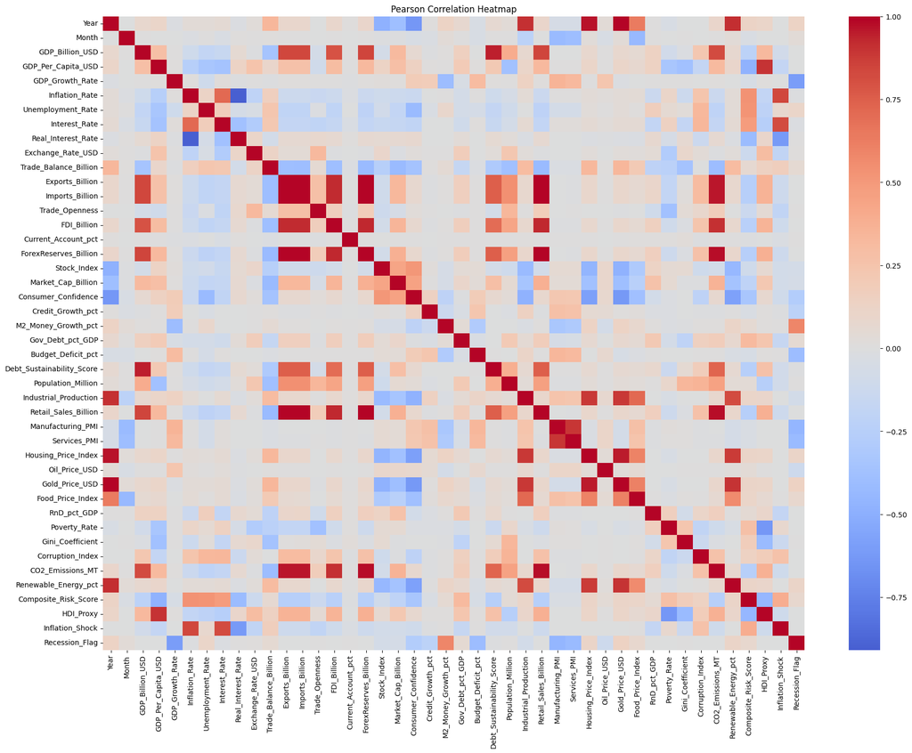

```python
plt.figure(figsize=(22,16))
sns.heatmap(corr_matrix,cmap="coolwarm",center=0)
plt.title("Pearson Correlation Heatmap")
plt.show()
```

```python
corr_pairs = (
    corr_matrix
    .abs()
    .unstack()
    .sort_values(
        ascending=False
    )
)

corr_pairs.head(50)
```

```
Inflation_Shock            Inflation_Shock              1.000000
Renewable_Energy_pct       Renewable_Energy_pct         1.000000
Composite_Risk_Score       Composite_Risk_Score         1.000000
HDI_Proxy                  HDI_Proxy                    1.000000
Gini_Coefficient           Gini_Coefficient             1.000000
Poverty_Rate               Poverty_Rate                 1.000000
RnD_pct_GDP                RnD_pct_GDP                  1.000000
Food_Price_Index           Food_Price_Index             1.000000
Oil_Price_USD              Oil_Price_USD                1.000000
Corruption_Index           Corruption_Index             1.000000
Month                      Month                        1.000000
CO2_Emissions_MT           CO2_Emissions_MT             1.000000
GDP_Per_Capita_USD         GDP_Per_Capita_USD           1.000000
Imports_Billion            Imports_Billion              1.000000
Exports_Billion            Exports_Billion              1.000000
Trade_Balance_Billion      Trade_Balance_Billion        1.000000
Inflation_Rate             Inflation_Rate               1.000000
Year                       Year                         1.000000
Recession_Flag             Recession_Flag               1.000000
GDP_Growth_Rate            GDP_Growth_Rate              1.000000
Housing_Price_Index        Housing_Price_Index          1.000000
Gold_Price_USD             Gold_Price_USD               1.000000
GDP_Billion_USD            GDP_Billion_USD              1.000000
Debt_Sustainability_Score  Debt_Sustainability_Score    1.000000
Gov_Debt_pct_GDP           Gov_Debt_pct_GDP             1.000000
Retail_Sales_Billion       Retail_Sales_Billion         1.000000
Manufacturing_PMI          Manufacturing_PMI            1.000000
Services_PMI               Services_PMI                 1.000000
Industrial_Production      Industrial_Production        1.000000
Population_Million         Population_Million           1.000000
Budget_Deficit_pct         Budget_Deficit_pct           1.000000
Unemployment_Rate          Unemployment_Rate            1.000000
Interest_Rate              Interest_Rate                1.000000
Real_Interest_Rate         Real_Interest_Rate           1.000000
Exchange_Rate_USD          Exchange_Rate_USD            1.000000
Trade_Openness             Trade_Openness               1.000000
Current_Account_pct        Current_Account_pct          1.000000
FDI_Billion                FDI_Billion                  1.000000
Stock_Index                Stock_Index                  1.000000
ForexReserves_Billion      ForexReserves_Billion        1.000000
Market_Cap_Billion         Market_Cap_Billion           1.000000
Consumer_Confidence        Consumer_Confidence          1.000000
Credit_Growth_pct          Credit_Growth_pct            1.000000
M2_Money_Growth_pct        M2_Money_Growth_pct          1.000000
Exports_Billion            Imports_Billion              0.999962
Imports_Billion            Exports_Billion              0.999962
ForexReserves_Billion      Retail_Sales_Billion         0.999947
Retail_Sales_Billion       ForexReserves_Billion        0.999947
Gold_Price_USD             Year                         0.987810
Year                       Gold_Price_USD               0.987810
dtype: float64
```

```python
corr_matrix_abs = corr_matrix.abs()

upper_triangle = corr_matrix_abs.where(
    np.triu(
        np.ones(
            corr_matrix_abs.shape
        ),
        k=1
    ).astype(bool)
)

top_corr = (
    upper_triangle
    .stack()
    .sort_values(
        ascending=False
    )
)

top_corr.head(20)
```

```
Exports_Billion        Imports_Billion              0.999962
ForexReserves_Billion  Retail_Sales_Billion         0.999947
Year                   Gold_Price_USD               0.987810
Imports_Billion        Retail_Sales_Billion         0.987626
                       ForexReserves_Billion        0.987599
Exports_Billion        Retail_Sales_Billion         0.987485
                       ForexReserves_Billion        0.987458
Retail_Sales_Billion   CO2_Emissions_MT             0.971252
ForexReserves_Billion  CO2_Emissions_MT             0.971236
Year                   Housing_Price_Index          0.962959
Imports_Billion        CO2_Emissions_MT             0.958869
Exports_Billion        CO2_Emissions_MT             0.958735
Housing_Price_Index    Gold_Price_USD               0.952269
GDP_Billion_USD        Debt_Sustainability_Score    0.943373
FDI_Billion            ForexReserves_Billion        0.932788
                       Retail_Sales_Billion         0.932783
Imports_Billion        FDI_Billion                  0.920935
Exports_Billion        FDI_Billion                  0.920805
Year                   Renewable_Energy_pct         0.912154
Inflation_Rate         Real_Interest_Rate           0.908737
dtype: float64
```

```python
top_corr_df = pd.DataFrame( top_corr.head(20)).reset_index()

top_corr_df.columns = [
    "Variable_1",
    "Variable_2",
    "Correlation"
]

top_corr_df
```

|  | Variable_1 | Variable_2 | Correlation |
| --- | --- | --- | --- |
| 0 | Exports_Billion | Imports_Billion | 0.999962 |
| 1 | ForexReserves_Billion | Retail_Sales_Billion | 0.999947 |
| 2 | Year | Gold_Price_USD | 0.987810 |
| 3 | Imports_Billion | Retail_Sales_Billion | 0.987626 |
| 4 | Imports_Billion | ForexReserves_Billion | 0.987599 |
| 5 | Exports_Billion | Retail_Sales_Billion | 0.987485 |
| 6 | Exports_Billion | ForexReserves_Billion | 0.987458 |
| 7 | Retail_Sales_Billion | CO2_Emissions_MT | 0.971252 |
| 8 | ForexReserves_Billion | CO2_Emissions_MT | 0.971236 |
| 9 | Year | Housing_Price_Index | 0.962959 |
| 10 | Imports_Billion | CO2_Emissions_MT | 0.958869 |
| 11 | Exports_Billion | CO2_Emissions_MT | 0.958735 |
| 12 | Housing_Price_Index | Gold_Price_USD | 0.952269 |
| 13 | GDP_Billion_USD | Debt_Sustainability_Score | 0.943373 |
| 14 | FDI_Billion | ForexReserves_Billion | 0.932788 |
| 15 | FDI_Billion | Retail_Sales_Billion | 0.932783 |
| 16 | Imports_Billion | FDI_Billion | 0.920935 |
| 17 | Exports_Billion | FDI_Billion | 0.920805 |
| 18 | Year | Renewable_Energy_pct | 0.912154 |
| 19 | Inflation_Rate | Real_Interest_Rate | 0.908737 |

```python
corr_matrix.stack().sort_values().head(20)
```

```
Real_Interest_Rate    Inflation_Rate         -0.908737
Inflation_Rate        Real_Interest_Rate     -0.908737
HDI_Proxy             Poverty_Rate           -0.635516
Poverty_Rate          HDI_Proxy              -0.635516
Consumer_Confidence   Year                   -0.634958
Year                  Consumer_Confidence    -0.634958
Gold_Price_USD        Consumer_Confidence    -0.632126
Consumer_Confidence   Gold_Price_USD         -0.632126
Inflation_Shock       Real_Interest_Rate     -0.620946
Real_Interest_Rate    Inflation_Shock        -0.620946
Recession_Flag        GDP_Growth_Rate        -0.601341
GDP_Growth_Rate       Recession_Flag         -0.601341
Housing_Price_Index   Consumer_Confidence    -0.587717
Consumer_Confidence   Housing_Price_Index    -0.587717
                      Renewable_Energy_pct   -0.579046
Renewable_Energy_pct  Consumer_Confidence    -0.579046
Stock_Index           Year                   -0.486355
Year                  Stock_Index            -0.486355
GDP_Per_Capita_USD    Composite_Risk_Score   -0.482616
Composite_Risk_Score  GDP_Per_Capita_USD     -0.482616
dtype: float64
```

```python
top_corr_df.head(10)
```

|  | Variable_1 | Variable_2 | Correlation |
| --- | --- | --- | --- |
| 0 | Exports_Billion | Imports_Billion | 0.999962 |
| 1 | ForexReserves_Billion | Retail_Sales_Billion | 0.999947 |
| 2 | Year | Gold_Price_USD | 0.987810 |
| 3 | Imports_Billion | Retail_Sales_Billion | 0.987626 |
| 4 | Imports_Billion | ForexReserves_Billion | 0.987599 |
| 5 | Exports_Billion | Retail_Sales_Billion | 0.987485 |
| 6 | Exports_Billion | ForexReserves_Billion | 0.987458 |
| 7 | Retail_Sales_Billion | CO2_Emissions_MT | 0.971252 |
| 8 | ForexReserves_Billion | CO2_Emissions_MT | 0.971236 |
| 9 | Year | Housing_Price_Index | 0.962959 |

# Pearson Correlation Analysis

## Objective

Pearson Correlation was used to measure the strength and direction of linear relationships among economic indicators.

## Business Insights

- International trade indicators move together very strongly.
- Gold prices and housing prices show strong upward trends over time.
- Higher economic activity is associated with higher CO₂ emissions.
- Inflation exhibits a strong inverse relationship with Real Interest Rates.
- Higher human development is associated with lower poverty levels.
- Wealthier economies tend to have lower economic risk.

## Conclusion

Pearson Correlation analysis revealed several strong economic relationships that can support feature selection, business insight generation, and predictive modeling in later stages of the project.

# Spearman Correlation Analysis

```python
spearman_corr = df_clean[numerical_columns].corr(method="spearman")
spearman_corr
```

|  | Year | Month | GDP_Billion_USD | GDP_Per_Capita_USD | GDP_Growth_Rate | Inflation_Rate | Unemployment_Rate | Interest_Rate | Real_Interest_Rate | Exchange_Rate_USD | Trade_Balance_Billion | Exports_Billion | Imports_Billion | Trade_Openness | FDI_Billion | Current_Account_pct | ForexReserves_Billion | Stock_Index | Market_Cap_Billion | Consumer_Confidence | Credit_Growth_pct | M2_Money_Growth_pct | Gov_Debt_pct_GDP | Budget_Deficit_pct | Debt_Sustainability_Score | Population_Million | Industrial_Production | Retail_Sales_Billion | Manufacturing_PMI | … |
| --- | --- | --- | --- | --- | --- | --- | --- | --- | --- | --- | --- | --- | --- | --- | --- | --- | --- | --- | --- | --- | --- | --- | --- | --- | --- | --- | --- | --- | --- | --- |
| Year | 1.000000 | -0.002218 | 0.167244 | 0.133778 | 0.063336 | 0.140164 | 0.051080 | 0.152732 | -0.126640 | 0.035350 | 0.347093 | 0.166221 | 0.162021 | -0.010997 | 0.160862 | 0.006365 | 0.169975 | -0.699747 | -0.619207 | -0.598514 | 0.003386 | 0.064619 | 0.103277 | -0.012314 | 0.132924 | 0.100874 | 0.906045 | 0.170919 | -0.031645 | … |
| Month | -0.002218 | 1.000000 | -0.001083 | -0.006067 | 0.020281 | -0.118122 | 0.002888 | -0.109062 | 0.081151 | 0.001313 | 0.010264 | -0.001691 | -0.001977 | -0.004266 | 0.000334 | 0.001112 | -0.000086 | -0.018666 | -0.018262 | -0.028171 | -0.011158 | 0.015837 | 0.008942 | -0.034683 | -0.003314 | 0.004881 | -0.208030 | -0.005754 | -0.468559 | … |
| GDP_Billion_USD | 0.167244 | -0.001083 | 1.000000 | 0.385662 | 0.023760 | -0.391995 | -0.366369 | -0.401672 | 0.369239 | 0.285505 | -0.116869 | 0.958299 | 0.957577 | 0.313660 | 0.902289 | 0.005207 | 0.979288 | 0.015471 | 0.344943 | 0.166216 | 0.002190 | 0.003887 | 0.121726 | -0.003580 | 0.933034 | 0.554263 | 0.156790 | 0.979934 | 0.001913 | … |
| GDP_Per_Capita_USD | 0.133778 | -0.006067 | 0.385662 | 1.000000 | 0.025006 | -0.555643 | -0.417109 | -0.568156 | 0.515004 | 0.260189 | 0.109607 | 0.344128 | 0.340660 | -0.115515 | 0.355706 | 0.003099 | 0.392616 | 0.220591 | 0.345195 | 0.197285 | 0.005808 | 0.010537 | 0.147084 | 0.012090 | 0.320266 | -0.407209 | 0.125766 | 0.393312 | 0.006427 | … |
| GDP_Growth_Rate | 0.063336 | 0.020281 | 0.023760 | 0.025006 | 1.000000 | 0.043103 | -0.151441 | 0.042813 | -0.041745 | 0.007897 | 0.020263 | 0.024929 | 0.025378 | 0.003703 | 0.015994 | -0.021082 | 0.025873 | -0.037484 | -0.030516 | 0.124816 | 0.111526 | -0.100583 | -0.021259 | 0.159755 | 0.028132 | 0.007142 | 0.149561 | 0.024947 | 0.153711 | … |
| Inflation_Rate | 0.140164 | -0.118122 | -0.391995 | -0.555643 | 0.043103 | 1.000000 | 0.387642 | 0.874943 | -0.897626 | -0.313291 | 0.098478 | -0.374803 | -0.376146 | -0.089243 | -0.364760 | -0.000467 | -0.399305 | -0.400278 | -0.484304 | -0.319806 | 0.013551 | -0.009299 | -0.006166 | 0.021607 | -0.368620 | 0.186752 | 0.185825 | -0.398705 | 0.083582 | … |
| Unemployment_Rate | 0.051080 | 0.002888 | -0.366369 | -0.417109 | -0.151441 | 0.387642 | 1.000000 | 0.412668 | -0.375582 | -0.012301 | 0.386344 | -0.313700 | -0.318117 | 0.070272 | -0.342606 | -0.013270 | -0.373716 | -0.272509 | -0.392544 | -0.526060 | -0.059094 | 0.061858 | -0.048611 | -0.067642 | -0.353851 | -0.070280 | -0.001184 | -0.373579 | -0.061449 | … |
| Interest_Rate | 0.152732 | -0.109062 | -0.401672 | -0.568156 | 0.042813 | 0.874943 | 0.412668 | 1.000000 | -0.665231 | -0.332498 | 0.117678 | -0.385256 | -0.386890 | -0.103643 | -0.375910 | -0.005991 | -0.409759 | -0.426002 | -0.511205 | -0.345894 | 0.012901 | -0.005093 | -0.006506 | 0.024164 | -0.378745 | 0.191322 | 0.193896 | -0.408903 | 0.080937 | … |
| Real_Interest_Rate | -0.126640 | 0.081151 | 0.369239 | 0.515004 | -0.041745 | -0.897626 | -0.375582 | -0.665231 | 1.000000 | 0.278624 | -0.112062 | 0.355654 | 0.356861 | 0.100451 | 0.342474 | 0.005041 | 0.375286 | 0.379287 | 0.458898 | 0.304707 | -0.010772 | 0.014649 | 0.003241 | -0.019305 | 0.351770 | -0.171895 | -0.157256 | 0.375382 | -0.057602 | … |
| Exchange_Rate_USD | 0.035350 | 0.001313 | 0.285505 | 0.260189 | 0.007897 | -0.313291 | -0.012301 | -0.332498 | 0.278624 | 1.000000 | 0.174330 | 0.335477 | 0.334071 | 0.382982 | 0.268212 | -0.000327 | 0.290129 | 0.162905 | 0.176748 | 0.043637 | 0.009942 | 0.001999 | 0.218430 | -0.004570 | 0.144222 | -0.165224 | 0.033557 | 0.290658 | -0.004528 | … |
| Trade_Balance_Billion | 0.347093 | 0.010264 | -0.116869 | 0.109607 | 0.020263 | 0.098478 | 0.386344 | 0.117678 | -0.112062 | 0.174330 | 1.000000 | -0.090821 | -0.102969 | 0.027124 | -0.120635 | -0.021417 | -0.119457 | -0.453157 | -0.534105 | -0.407594 | 0.002436 | 0.029869 | -0.209804 | -0.002449 | -0.102666 | -0.362269 | 0.312768 | -0.119326 | -0.018171 | … |
| Exports_Billion | 0.166221 | -0.001691 | 0.958299 | 0.344128 | 0.024929 | -0.374803 | -0.313700 | -0.385256 | 0.355654 | 0.335477 | -0.090821 | 1.000000 | 0.998955 | 0.519375 | 0.900831 | 0.002119 | 0.976487 | -0.006317 | 0.320673 | 0.144177 | 0.004483 | 0.006273 | 0.112932 | -0.005034 | 0.893756 | 0.575835 | 0.157144 | 0.977109 | 0.001969 | … |
| Imports_Billion | 0.162021 | -0.001977 | 0.957577 | 0.340660 | 0.025378 | -0.376146 | -0.318117 | -0.386890 | 0.356861 | 0.334071 | -0.102969 | 0.998955 | 1.000000 | 0.521692 | 0.900163 | 0.002026 | 0.975776 | -0.001084 | 0.325168 | 0.148264 | 0.004947 | 0.005708 | 0.112083 | -0.004934 | 0.893638 | 0.579352 | 0.153559 | 0.976383 | 0.002686 | … |
| Trade_Openness | -0.010997 | -0.004266 | 0.313660 | -0.115515 | 0.003703 | -0.089243 | 0.070272 | -0.103643 | 0.100451 | 0.382982 | 0.027124 | 0.519375 | 0.521692 | 1.000000 | 0.327512 | -0.005904 | 0.349129 | -0.045636 | 0.056044 | 0.021144 | 0.008779 | 0.004529 | 0.007451 | -0.009991 | 0.293821 | 0.309717 | -0.002798 | 0.349520 | 0.001841 | … |
| FDI_Billion | 0.160862 | 0.000334 | 0.902289 | 0.355706 | 0.015994 | -0.364760 | -0.342606 | -0.375910 | 0.342474 | 0.268212 | -0.120635 | 0.900831 | 0.900163 | 0.327512 | 1.000000 | 0.004566 | 0.919365 | 0.010184 | 0.322197 | 0.149782 | 0.002941 | 0.001179 | 0.124105 | 0.001292 | 0.839695 | 0.529738 | 0.149139 | 0.920005 | -0.008259 | … |
| Current_Account_pct | 0.006365 | 0.001112 | 0.005207 | 0.003099 | -0.021082 | -0.000467 | -0.013270 | -0.005991 | 0.005041 | -0.000327 | -0.021417 | 0.002119 | 0.002026 | -0.005904 | 0.004566 | 1.000000 | 0.004578 | 0.022551 | 0.018593 | 0.013510 | 0.002057 | 0.004849 | -0.004063 | -0.001907 | 0.005862 | -0.000466 | 0.008057 | 0.004543 | 0.008945 | … |
| ForexReserves_Billion | 0.169975 | -0.000086 | 0.979288 | 0.392616 | 0.025873 | -0.399305 | -0.373716 | -0.409759 | 0.375286 | 0.290129 | -0.119457 | 0.976487 | 0.975776 | 0.349129 | 0.919365 | 0.004578 | 1.000000 | 0.015309 | 0.350993 | 0.169108 | 0.002991 | 0.004060 | 0.122910 | -0.002525 | 0.912729 | 0.565730 | 0.159330 | 0.998477 | 0.001270 | … |
| Stock_Index | -0.699747 | -0.018666 | 0.015471 | 0.220591 | -0.037484 | -0.400278 | -0.272509 | -0.426002 | 0.379287 | 0.162905 | -0.453157 | -0.006317 | -0.001084 | -0.045636 | 0.010184 | 0.022551 | 0.015309 | 1.000000 | 0.867737 | 0.703916 | 0.006674 | -0.048310 | 0.023285 | 0.012990 | 0.011275 | -0.181810 | -0.630471 | 0.015120 | 0.035027 | … |
| Market_Cap_Billion | -0.619207 | -0.018262 | 0.344943 | 0.345195 | -0.030516 | -0.484304 | -0.392544 | -0.511205 | 0.458898 | 0.176748 | -0.534105 | 0.320673 | 0.325168 | 0.056044 | 0.322197 | 0.018593 | 0.350993 | 0.867737 | 1.000000 | 0.732616 | 0.006537 | -0.046906 | 0.098989 | 0.013793 | 0.321920 | 0.059321 | -0.557097 | 0.351012 | 0.031454 | … |
| Consumer_Confidence | -0.598514 | -0.028171 | 0.166216 | 0.197285 | 0.124816 | -0.319806 | -0.526060 | -0.345894 | 0.304707 | 0.043637 | -0.407594 | 0.144177 | 0.148264 | 0.021144 | 0.149782 | 0.013510 | 0.169108 | 0.703916 | 0.732616 | 1.000000 | 0.130960 | -0.091543 | -0.034157 | 0.149510 | 0.178094 | -0.012293 | -0.459727 | 0.168624 | 0.158713 | … |
| Credit_Growth_pct | 0.003386 | -0.011158 | 0.002190 | 0.005808 | 0.111526 | 0.013551 | -0.059094 | 0.012901 | -0.010772 | 0.009942 | 0.002436 | 0.004483 | 0.004947 | 0.008779 | 0.002941 | 0.002057 | 0.002991 | 0.006674 | 0.006537 | 0.130960 | 1.000000 | -0.054221 | -0.036268 | 0.175590 | 0.010936 | -0.002878 | 0.110854 | 0.002727 | 0.158494 | … |
| M2_Money_Growth_pct | 0.064619 | 0.015837 | 0.003887 | 0.010537 | -0.100583 | -0.009299 | 0.061858 | -0.005093 | 0.014649 | 0.001999 | 0.029869 | 0.006273 | 0.005708 | 0.004529 | 0.001179 | 0.004849 | 0.004060 | -0.048310 | -0.046906 | -0.091543 | -0.054221 | 1.000000 | 0.010744 | -0.088621 | -0.001067 | 0.001499 | -0.002121 | 0.003836 | -0.081142 | … |
| Gov_Debt_pct_GDP | 0.103277 | 0.008942 | 0.121726 | 0.147084 | -0.021259 | -0.006166 | -0.048611 | -0.006506 | 0.003241 | 0.218430 | -0.209804 | 0.112932 | 0.112083 | 0.007451 | 0.124105 | -0.004063 | 0.122910 | 0.023285 | 0.098989 | -0.034157 | -0.036268 | 0.010744 | 1.000000 | -0.030621 | -0.165687 | 0.054187 | 0.072341 | 0.123626 | -0.049491 | … |
| Budget_Deficit_pct | -0.012314 | -0.034683 | -0.003580 | 0.012090 | 0.159755 | 0.021607 | -0.067642 | 0.024164 | -0.019305 | -0.004570 | -0.002449 | -0.005034 | -0.004934 | -0.009991 | 0.001292 | -0.001907 | -0.002525 | 0.012990 | 0.013793 | 0.149510 | 0.175590 | -0.088621 | -0.030621 | 1.000000 | 0.003973 | -0.011026 | 0.118657 | -0.003115 | 0.186777 | … |
| Debt_Sustainability_Score | 0.132924 | -0.003314 | 0.933034 | 0.320266 | 0.028132 | -0.368620 | -0.353851 | -0.378745 | 0.351770 | 0.144222 | -0.102666 | 0.893756 | 0.893638 | 0.293821 | 0.839695 | 0.005862 | 0.912729 | 0.011275 | 0.321920 | 0.178094 | 0.010936 | -0.001067 | -0.165687 | 0.003973 | 1.000000 | 0.559089 | 0.131330 | 0.913147 | 0.015221 | … |
| Population_Million | 0.100874 | 0.004881 | 0.554263 | -0.407209 | 0.007142 | 0.186752 | -0.070280 | 0.191322 | -0.171895 | -0.165224 | -0.362269 | 0.575835 | 0.579352 | 0.309717 | 0.529738 | -0.000466 | 0.565730 | -0.181810 | 0.059321 | -0.012293 | -0.002878 | 0.001499 | 0.054187 | -0.011026 | 0.559089 | 1.000000 | 0.092281 | 0.565276 | -0.003464 | … |
| Industrial_Production | 0.906045 | -0.208030 | 0.156790 | 0.125766 | 0.149561 | 0.185825 | -0.001184 | 0.193896 | -0.157256 | 0.033557 | 0.312768 | 0.157144 | 0.153559 | -0.002798 | 0.149139 | 0.008057 | 0.159330 | -0.630471 | -0.557097 | -0.459727 | 0.110854 | -0.002121 | 0.072341 | 0.118657 | 0.131330 | 0.092281 | 1.000000 | 0.161769 | 0.227432 | … |
| Retail_Sales_Billion | 0.170919 | -0.005754 | 0.979934 | 0.393312 | 0.024947 | -0.398705 | -0.373579 | -0.408903 | 0.375382 | 0.290658 | -0.119326 | 0.977109 | 0.976383 | 0.349520 | 0.920005 | 0.004543 | 0.998477 | 0.015120 | 0.351012 | 0.168624 | 0.002727 | 0.003836 | 0.123626 | -0.003115 | 0.913147 | 0.565276 | 0.161769 | 1.000000 | 0.005113 | … |
| Manufacturing_PMI | -0.031645 | -0.468559 | 0.001913 | 0.006427 | 0.153711 | 0.083582 | -0.061449 | 0.080937 | -0.057602 | -0.004528 | -0.018171 | 0.001969 | 0.002686 | 0.001841 | -0.008259 | 0.008945 | 0.001270 | 0.035027 | 0.031454 | 0.158713 | 0.158494 | -0.081142 | -0.049491 | 0.186777 | 0.015221 | -0.003464 | 0.227432 | 0.005113 | 1.000000 | … |
| Services_PMI | -0.039579 | -0.423072 | -0.001851 | 0.008162 | 0.143576 | 0.069190 | -0.068015 | 0.066463 | -0.049454 | -0.002533 | -0.019407 | -0.000821 | 0.000156 | 0.005567 | -0.011433 | 0.006513 | -0.002668 | 0.043132 | 0.038414 | 0.165553 | 0.159282 | -0.073661 | -0.047828 | 0.179472 | 0.010556 | -0.009114 | 0.204508 | 0.000721 | 0.869231 | … |
| Housing_Price_Index | 0.962189 | 0.026081 | 0.159618 | 0.129744 | 0.088481 | 0.131640 | 0.050915 | 0.143687 | -0.120584 | 0.035616 | 0.336911 | 0.159784 | 0.155741 | -0.007344 | 0.153401 | 0.004150 | 0.162378 | -0.668041 | -0.590431 | -0.550359 | 0.034328 | 0.063281 | 0.095453 | 0.021851 | 0.127311 | 0.095039 | 0.884497 | 0.163219 | -0.013415 | … |
| Oil_Price_USD | 0.380363 | -0.025348 | 0.078093 | 0.065591 | 0.160839 | 0.101012 | -0.003457 | 0.101506 | -0.102411 | 0.021990 | 0.138061 | 0.075885 | 0.074043 | -0.005603 | 0.068493 | 0.001599 | 0.080153 | -0.212584 | -0.178539 | -0.132169 | 0.041209 | -0.021771 | 0.026378 | 0.059564 | 0.066814 | 0.041043 | 0.380033 | 0.079995 | 0.062161 | … |
| Gold_Price_USD | 0.988443 | 0.035733 | 0.163743 | 0.133842 | 0.060966 | 0.132705 | 0.054400 | 0.145294 | -0.122328 | 0.037119 | 0.348263 | 0.162951 | 0.158803 | -0.011968 | 0.157423 | 0.002807 | 0.166439 | -0.693055 | -0.614102 | -0.595360 | 0.005989 | 0.065827 | 0.101231 | -0.014069 | 0.129748 | 0.095674 | 0.887426 | 0.167194 | -0.048368 | … |
| Food_Price_Index | 0.629110 | -0.434444 | 0.113423 | 0.092506 | 0.036081 | 0.152752 | 0.029812 | 0.153224 | -0.129677 | 0.020867 | 0.204595 | 0.112585 | 0.110194 | -0.005243 | 0.109106 | 0.012853 | 0.113857 | -0.425670 | -0.372625 | -0.362241 | 0.009165 | 0.042665 | 0.071349 | 0.000521 | 0.089727 | 0.067174 | 0.709024 | 0.118528 | 0.322238 | … |
| RnD_pct_GDP | 0.002990 | 0.002532 | 0.121972 | 0.043853 | 0.002542 | -0.141908 | 0.080407 | -0.135657 | 0.115158 | 0.071511 | -0.216750 | 0.110331 | 0.112721 | -0.069089 | 0.117571 | 0.007411 | 0.124171 | 0.173680 | 0.225429 | -0.042999 | -0.018513 | 0.012418 | 0.264466 | 0.008536 | 0.043765 | 0.177599 | 0.001898 | 0.123853 | -0.008432 | … |
| Poverty_Rate | -0.058970 | -0.001638 | -0.168688 | -0.327214 | -0.003207 | 0.282171 | 0.083253 | 0.286370 | -0.260126 | -0.360542 | -0.223562 | -0.250814 | -0.249203 | -0.455244 | -0.159481 | 0.010705 | -0.172504 | 0.008409 | -0.033467 | -0.043035 | -0.015706 | -0.020518 | -0.061278 | -0.000772 | -0.134479 | 0.152270 | -0.058145 | -0.172016 | 0.015255 | … |
| Gini_Coefficient | -0.001159 | 0.001574 | -0.045729 | -0.413584 | 0.003324 | 0.032255 | -0.027366 | 0.018331 | -0.014084 | 0.109963 | -0.341491 | -0.039965 | -0.033088 | 0.109150 | -0.038445 | 0.023682 | -0.046768 | 0.117343 | 0.091295 | 0.016260 | -0.001523 | -0.011831 | -0.186957 | -0.006493 | 0.005556 | 0.189440 | 0.000592 | -0.046545 | 0.006362 | … |
| Corruption_Index | -0.000759 | 0.000694 | -0.092594 | -0.166169 | 0.000259 | 0.257182 | 0.371582 | 0.272789 | -0.249576 | -0.019632 | -0.051953 | -0.074146 | -0.076254 | 0.021952 | -0.076530 | -0.018099 | -0.093566 | -0.204151 | -0.137558 | -0.236543 | -0.010559 | 0.004707 | 0.182214 | 0.014269 | -0.145236 | 0.097699 | -0.003222 | -0.094151 | -0.013294 | … |
| CO2_Emissions_MT | 0.163838 | -0.003372 | 0.947092 | 0.375067 | 0.025963 | -0.383789 | -0.353509 | -0.392988 | 0.359883 | 0.281525 | -0.103556 | 0.944357 | 0.943560 | 0.336030 | 0.888555 | 0.004100 | 0.965410 | 0.005806 | 0.328824 | 0.155450 | 0.001353 | 0.004013 | 0.109959 | -0.002494 | 0.882356 | 0.545812 | 0.154022 | 0.965954 | 0.001548 | … |
| Renewable_Energy_pct | 0.918505 | 0.033689 | 0.147034 | 0.116143 | 0.070260 | 0.133937 | 0.050259 | 0.142602 | -0.124693 | 0.031962 | 0.320092 | 0.146950 | 0.143161 | -0.009245 | 0.142888 | 0.000712 | 0.149234 | -0.648156 | -0.575355 | -0.553678 | -0.005908 | 0.059681 | 0.101483 | -0.007728 | 0.114795 | 0.092134 | 0.827221 | 0.149952 | -0.047383 | … |
| Composite_Risk_Score | 0.132778 | -0.036329 | -0.407207 | -0.507573 | -0.045620 | 0.644719 | 0.526278 | 0.582053 | -0.605219 | -0.091868 | 0.010219 | -0.407842 | -0.407421 | -0.139162 | -0.378247 | -0.002306 | -0.415386 | -0.237529 | -0.337125 | -0.380796 | -0.033197 | 0.020707 | 0.326651 | -0.034450 | -0.498840 | 0.046922 | 0.112393 | -0.414937 | -0.013872 | … |
| HDI_Proxy | 0.105621 | -0.003787 | 0.372649 | 0.895120 | 0.019081 | -0.506248 | -0.226306 | -0.513254 | 0.465481 | 0.369853 | 0.184608 | 0.371974 | 0.367326 | 0.070372 | 0.346544 | -0.007021 | 0.379768 | 0.149170 | 0.286428 | 0.105128 | 0.004107 | 0.015186 | 0.226331 | 0.013294 | 0.279667 | -0.367526 | 0.099037 | 0.380055 | -0.004103 | … |
| Inflation_Shock | -0.000637 | -0.000901 | -0.288981 | -0.106762 | 0.000400 | 0.398240 | 0.183620 | 0.328774 | -0.398241 | -0.283328 | 0.190007 | -0.300172 | -0.301618 | -0.218777 | -0.276380 | -0.024856 | -0.294108 | -0.236181 | -0.252490 | -0.168074 | -0.006205 | 0.002960 | -0.181754 | 0.011198 | -0.242573 | -0.178413 | -0.004341 | -0.294664 | -0.007133 | … |
| Recession_Flag | 0.134189 | 0.034895 | 0.010215 | -0.004698 | -0.336499 | -0.032139 | 0.169540 | -0.033404 | 0.025950 | 0.013648 | 0.059483 | 0.011425 | 0.010112 | 0.003355 | 0.012451 | 0.003922 | 0.009349 | -0.087062 | -0.082303 | -0.262688 | -0.206692 | 0.258355 | 0.069157 | -0.292102 | -0.010857 | 0.014016 | -0.086494 | 0.010457 | -0.282918 | … |

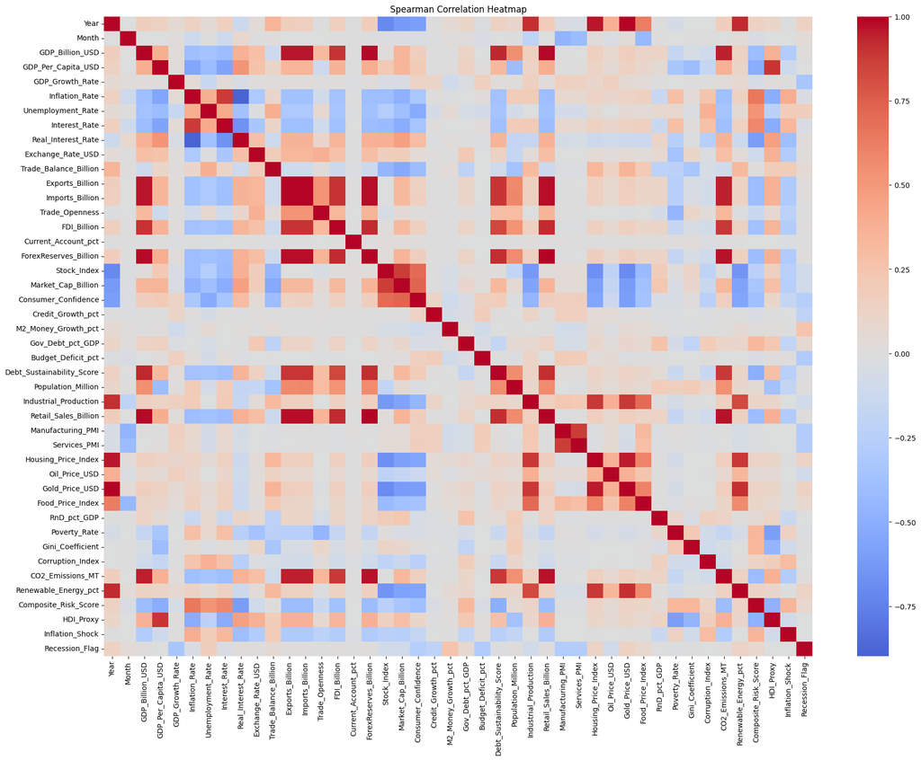

```python
plt.figure(figsize=(22,16))
sns.heatmap(spearman_corr, cmap="coolwarm",center=0)
plt.title("Spearman Correlation Heatmap")
plt.show()
```

```python
spearman_abs = spearman_corr.abs()
upper_triangle = spearman_abs.where(np.triu(np.ones(spearman_abs.shape),k=1).astype(bool))
top_spearman = (upper_triangle.stack().sort_values(ascending=False))
top_spearman.head(20)
```

```
Exports_Billion        Imports_Billion              0.998955
ForexReserves_Billion  Retail_Sales_Billion         0.998477
Year                   Gold_Price_USD               0.988443
GDP_Billion_USD        Retail_Sales_Billion         0.979934
                       ForexReserves_Billion        0.979288
Exports_Billion        Retail_Sales_Billion         0.977109
                       ForexReserves_Billion        0.976487
Imports_Billion        Retail_Sales_Billion         0.976383
                       ForexReserves_Billion        0.975776
Retail_Sales_Billion   CO2_Emissions_MT             0.965954
ForexReserves_Billion  CO2_Emissions_MT             0.965410
Year                   Housing_Price_Index          0.962189
GDP_Billion_USD        Exports_Billion              0.958299
                       Imports_Billion              0.957577
Housing_Price_Index    Gold_Price_USD               0.952639
GDP_Billion_USD        CO2_Emissions_MT             0.947092
Exports_Billion        CO2_Emissions_MT             0.944357
Imports_Billion        CO2_Emissions_MT             0.943560
GDP_Billion_USD        Debt_Sustainability_Score    0.933034
FDI_Billion            Retail_Sales_Billion         0.920005
dtype: float64
```

```python
top_spearman_df = pd.DataFrame(top_spearman.head(20)).reset_index()
top_spearman_df.columns = ["Variable_1","Variable_2","Spearman_Correlation"]
top_spearman_df
```

|  | Variable_1 | Variable_2 | Spearman_Correlation |
| --- | --- | --- | --- |
| 0 | Exports_Billion | Imports_Billion | 0.998955 |
| 1 | ForexReserves_Billion | Retail_Sales_Billion | 0.998477 |
| 2 | Year | Gold_Price_USD | 0.988443 |
| 3 | GDP_Billion_USD | Retail_Sales_Billion | 0.979934 |
| 4 | GDP_Billion_USD | ForexReserves_Billion | 0.979288 |
| 5 | Exports_Billion | Retail_Sales_Billion | 0.977109 |
| 6 | Exports_Billion | ForexReserves_Billion | 0.976487 |
| 7 | Imports_Billion | Retail_Sales_Billion | 0.976383 |
| 8 | Imports_Billion | ForexReserves_Billion | 0.975776 |
| 9 | Retail_Sales_Billion | CO2_Emissions_MT | 0.965954 |
| 10 | ForexReserves_Billion | CO2_Emissions_MT | 0.965410 |
| 11 | Year | Housing_Price_Index | 0.962189 |
| 12 | GDP_Billion_USD | Exports_Billion | 0.958299 |
| 13 | GDP_Billion_USD | Imports_Billion | 0.957577 |
| 14 | Housing_Price_Index | Gold_Price_USD | 0.952639 |
| 15 | GDP_Billion_USD | CO2_Emissions_MT | 0.947092 |
| 16 | Exports_Billion | CO2_Emissions_MT | 0.944357 |
| 17 | Imports_Billion | CO2_Emissions_MT | 0.943560 |
| 18 | GDP_Billion_USD | Debt_Sustainability_Score | 0.933034 |
| 19 | FDI_Billion | Retail_Sales_Billion | 0.920005 |

# Spearman Correlation Analysis

## Objective

Spearman Correlation was performed to evaluate monotonic relationships between variables using rank-based statistics.

This method is more robust to non-normal distributions and outliers than Pearson Correlation.

## Key Findings

- The strongest relationships identified by Spearman Correlation were largely consistent with Pearson Correlation.
- Exports and Imports exhibited an almost perfect positive relationship.
- Gold Price and Housing Price Index showed strong upward trends over time.
- Retail Sales, Forex Reserves, and CO2 Emissions demonstrated strong positive associations.

## Comparison with Pearson Correlation

The similarity between Pearson and Spearman coefficients suggests that the identified relationships are stable and not solely driven by extreme observations.

## Conclusion

Spearman Correlation validated the major relationships discovered through Pearson Correlation and increased confidence in subsequent business insights and predictive modeling.

# Kendall Correlation Analysis

```python
kendall_corr = df_clean[numerical_columns].corr(method="kendall")
kendall_corr
```

|  | Year | Month | GDP_Billion_USD | GDP_Per_Capita_USD | GDP_Growth_Rate | Inflation_Rate | Unemployment_Rate | Interest_Rate | Real_Interest_Rate | Exchange_Rate_USD | Trade_Balance_Billion | Exports_Billion | Imports_Billion | Trade_Openness | FDI_Billion | Current_Account_pct | ForexReserves_Billion | Stock_Index | Market_Cap_Billion | Consumer_Confidence | Credit_Growth_pct | M2_Money_Growth_pct | Gov_Debt_pct_GDP | Budget_Deficit_pct | Debt_Sustainability_Score | Population_Million | Industrial_Production | Retail_Sales_Billion | Manufacturing_PMI | … |
| --- | --- | --- | --- | --- | --- | --- | --- | --- | --- | --- | --- | --- | --- | --- | --- | --- | --- | --- | --- | --- | --- | --- | --- | --- | --- | --- | --- | --- | --- | --- |
| Year | 1.000000 | -0.001567 | 0.122711 | 0.099910 | 0.044536 | 0.095403 | 0.033837 | 0.103564 | -0.086133 | 0.026162 | 0.247702 | 0.123717 | 0.120649 | -0.007489 | 0.109547 | 0.004194 | 0.123205 | -0.513111 | -0.438368 | -0.419341 | 0.002600 | 0.043817 | 0.073756 | -0.008960 | 0.096576 | 0.077394 | 0.744686 | 0.125128 | -0.020944 | … |
| Month | -0.001567 | 1.000000 | -0.000743 | -0.004170 | 0.014037 | -0.081503 | 0.002043 | -0.075216 | 0.056320 | 0.000918 | 0.007175 | -0.001168 | -0.001363 | -0.002957 | 0.000280 | 0.000832 | -0.000044 | -0.013014 | -0.012754 | -0.019606 | -0.007831 | 0.011058 | 0.006197 | -0.023995 | -0.002297 | 0.003391 | -0.144412 | -0.003981 | -0.322626 | … |
| GDP_Billion_USD | 0.122711 | -0.000743 | 1.000000 | 0.311781 | 0.016178 | -0.267734 | -0.256485 | -0.272224 | 0.250202 | 0.219755 | -0.049323 | 0.863691 | 0.861088 | 0.228072 | 0.760347 | 0.003436 | 0.950734 | -0.005125 | 0.221695 | 0.112565 | 0.001464 | 0.002674 | 0.092451 | -0.002453 | 0.813312 | 0.423296 | 0.108571 | 0.958562 | 0.001302 | … |
| GDP_Per_Capita_USD | 0.099910 | -0.004170 | 0.311781 | 1.000000 | 0.016707 | -0.353607 | -0.283956 | -0.358482 | 0.324667 | 0.192584 | 0.084505 | 0.304349 | 0.300945 | -0.076073 | 0.260744 | 0.002143 | 0.315066 | 0.141841 | 0.227274 | 0.133744 | 0.003954 | 0.007036 | 0.129805 | 0.007989 | 0.269941 | -0.242503 | 0.089889 | 0.318014 | 0.004379 | … |
| GDP_Growth_Rate | 0.044536 | 0.014037 | 0.016178 | 0.016707 | 1.000000 | 0.028970 | -0.102050 | 0.028720 | -0.028107 | 0.005197 | 0.013532 | 0.016678 | 0.016906 | 0.002539 | 0.010751 | -0.014094 | 0.017477 | -0.023806 | -0.020086 | 0.084916 | 0.073962 | -0.067549 | -0.014254 | 0.108368 | 0.019055 | 0.004641 | 0.098797 | 0.016944 | 0.104203 | … |
| Inflation_Rate | 0.095403 | -0.081503 | -0.267734 | -0.353607 | 0.028970 | 1.000000 | 0.260489 | 0.731949 | -0.739156 | -0.206462 | 0.063654 | -0.253047 | -0.253883 | -0.063000 | -0.248521 | -0.000457 | -0.272790 | -0.277384 | -0.334738 | -0.214616 | 0.008942 | -0.006140 | -0.009901 | 0.014447 | -0.234726 | 0.106089 | 0.124912 | -0.272120 | 0.055731 | … |
| Unemployment_Rate | 0.033837 | 0.002043 | -0.256485 | -0.283956 | -0.102050 | 0.260489 | 1.000000 | 0.276817 | -0.252733 | -0.010839 | 0.256488 | -0.218189 | -0.221177 | 0.033317 | -0.235352 | -0.008972 | -0.261619 | -0.185389 | -0.268294 | -0.396837 | -0.039505 | 0.041420 | -0.019938 | -0.045224 | -0.243250 | -0.038232 | -0.000399 | -0.261593 | -0.041129 | … |
| Interest_Rate | 0.103564 | -0.075216 | -0.272224 | -0.358482 | 0.028720 | 0.731949 | 0.276817 | 1.000000 | -0.484003 | -0.222278 | 0.076887 | -0.259815 | -0.260898 | -0.073503 | -0.255044 | -0.004061 | -0.277870 | -0.295304 | -0.352879 | -0.232421 | 0.008566 | -0.003375 | -0.009223 | 0.016218 | -0.240300 | 0.112819 | 0.129886 | -0.277053 | 0.054050 | … |
| Real_Interest_Rate | -0.086133 | 0.056320 | 0.250202 | 0.324667 | -0.028107 | -0.739156 | -0.252733 | -0.484003 | 1.000000 | 0.189368 | -0.073205 | 0.240125 | 0.240946 | 0.069505 | 0.232046 | 0.003356 | 0.254358 | 0.261444 | 0.316336 | 0.204201 | -0.007116 | 0.009754 | 0.004665 | -0.012784 | 0.227139 | -0.103409 | -0.105339 | 0.254276 | -0.038453 | … |
| Exchange_Rate_USD | 0.026162 | 0.000918 | 0.219755 | 0.192584 | 0.005197 | -0.206462 | -0.010839 | -0.222278 | 0.189368 | 1.000000 | 0.125955 | 0.268808 | 0.268078 | 0.255294 | 0.195933 | -0.000160 | 0.222890 | 0.109990 | 0.124945 | 0.028986 | 0.006820 | 0.001328 | 0.177065 | -0.003086 | 0.109661 | -0.118466 | 0.023458 | 0.223581 | -0.003050 | … |
| Trade_Balance_Billion | 0.247702 | 0.007175 | -0.049323 | 0.084505 | 0.013532 | 0.063654 | 0.256488 | 0.076887 | -0.073205 | 0.125955 | 1.000000 | -0.038057 | -0.048242 | 0.021002 | -0.069194 | -0.014381 | -0.051654 | -0.313193 | -0.370880 | -0.271371 | 0.001584 | 0.020033 | -0.113257 | -0.001638 | -0.041922 | -0.180671 | 0.215222 | -0.050569 | -0.012149 | … |
| Exports_Billion | 0.123717 | -0.001168 | 0.863691 | 0.304349 | 0.016678 | -0.253047 | -0.218189 | -0.259815 | 0.240125 | 0.268808 | -0.038057 | 1.000000 | 0.973903 | 0.362936 | 0.738425 | 0.001510 | 0.877512 | -0.017875 | 0.207664 | 0.097053 | 0.003056 | 0.004185 | 0.090111 | -0.003446 | 0.753807 | 0.424994 | 0.111158 | 0.880530 | 0.001348 | … |
| Imports_Billion | 0.120649 | -0.001363 | 0.861088 | 0.300945 | 0.016906 | -0.253883 | -0.221177 | -0.260898 | 0.240946 | 0.268078 | -0.048242 | 0.973903 | 1.000000 | 0.365497 | 0.737397 | 0.001450 | 0.875157 | -0.014447 | 0.210778 | 0.099542 | 0.003362 | 0.003809 | 0.089594 | -0.003410 | 0.753747 | 0.426966 | 0.108842 | 0.877928 | 0.001829 | … |
| Trade_Openness | -0.007489 | -0.002957 | 0.228072 | -0.076073 | 0.002539 | -0.063000 | 0.033317 | -0.073503 | 0.069505 | 0.255294 | 0.021002 | 0.362936 | 0.365497 | 1.000000 | 0.227576 | -0.003933 | 0.251106 | -0.020592 | 0.041849 | 0.017662 | 0.005873 | 0.003016 | 0.005465 | -0.006749 | 0.204047 | 0.220211 | -0.001908 | 0.251335 | 0.001280 | … |
| FDI_Billion | 0.109547 | 0.000280 | 0.760347 | 0.260744 | 0.010751 | -0.248521 | -0.235352 | -0.255044 | 0.232046 | 0.195933 | -0.069194 | 0.738425 | 0.737397 | 0.227576 | 1.000000 | 0.003060 | 0.773723 | 0.003363 | 0.216383 | 0.102061 | 0.001931 | 0.000843 | 0.084007 | 0.000872 | 0.674190 | 0.373503 | 0.099660 | 0.775222 | -0.005585 | … |
| Current_Account_pct | 0.004194 | 0.000832 | 0.003436 | 0.002143 | -0.014094 | -0.000457 | -0.008972 | -0.004061 | 0.003356 | -0.000160 | -0.014381 | 0.001510 | 0.001450 | -0.003933 | 0.003060 | 1.000000 | 0.003043 | 0.015099 | 0.012429 | 0.008868 | 0.001492 | 0.003137 | -0.002645 | -0.001215 | 0.003879 | -0.000223 | 0.005236 | 0.003003 | 0.005911 | … |
| ForexReserves_Billion | 0.123205 | -0.000044 | 0.950734 | 0.315066 | 0.017477 | -0.272790 | -0.261619 | -0.277870 | 0.254358 | 0.222890 | -0.051654 | 0.877512 | 0.875157 | 0.251106 | 0.773723 | 0.003043 | 1.000000 | -0.004468 | 0.226359 | 0.114746 | 0.002026 | 0.002800 | 0.092941 | -0.001752 | 0.787217 | 0.430737 | 0.109855 | 0.968742 | 0.000832 | … |
| Stock_Index | -0.513111 | -0.013014 | -0.005125 | 0.141841 | -0.023806 | -0.277384 | -0.185389 | -0.295304 | 0.261444 | 0.109990 | -0.313193 | -0.017875 | -0.014447 | -0.020592 | 0.003363 | 0.015099 | -0.004468 | 1.000000 | 0.697541 | 0.510684 | 0.004347 | -0.032474 | 0.015408 | 0.008931 | -0.007556 | -0.130113 | -0.441979 | -0.005584 | 0.023458 | … |
| Market_Cap_Billion | -0.438368 | -0.012754 | 0.221695 | 0.227274 | -0.020086 | -0.334738 | -0.268294 | -0.352879 | 0.316336 | 0.124945 | -0.370880 | 0.207664 | 0.210778 | 0.041849 | 0.216383 | 0.012429 | 0.226359 | 0.697541 | 1.000000 | 0.526160 | 0.004254 | -0.031502 | 0.066625 | 0.009373 | 0.208043 | 0.030975 | -0.381643 | 0.225664 | 0.021090 | … |
| Consumer_Confidence | -0.419341 | -0.019606 | 0.112565 | 0.133744 | 0.084916 | -0.214616 | -0.396837 | -0.232421 | 0.204201 | 0.028986 | -0.271371 | 0.097053 | 0.099542 | 0.017662 | 0.102061 | 0.008868 | 0.114746 | 0.510684 | 0.526160 | 1.000000 | 0.087215 | -0.061414 | -0.030631 | 0.100851 | 0.119425 | -0.010215 | -0.313068 | 0.114322 | 0.107116 | … |
| Credit_Growth_pct | 0.002600 | -0.007831 | 0.001464 | 0.003954 | 0.073962 | 0.008942 | -0.039505 | 0.008566 | -0.007116 | 0.006820 | 0.001584 | 0.003056 | 0.003362 | 0.005873 | 0.001931 | 0.001492 | 0.002026 | 0.004347 | 0.004254 | 0.087215 | 1.000000 | -0.036102 | -0.024081 | 0.116480 | 0.007271 | -0.001857 | 0.074242 | 0.001828 | 0.104712 | … |
| M2_Money_Growth_pct | 0.043817 | 0.011058 | 0.002674 | 0.007036 | -0.067549 | -0.006140 | 0.041420 | -0.003375 | 0.009754 | 0.001328 | 0.020033 | 0.004185 | 0.003809 | 0.003016 | 0.000843 | 0.003137 | 0.002800 | -0.032474 | -0.031502 | -0.061414 | -0.036102 | 1.000000 | 0.007165 | -0.059127 | -0.000598 | 0.001030 | -0.001468 | 0.002642 | -0.054023 | … |
| Gov_Debt_pct_GDP | 0.073756 | 0.006197 | 0.092451 | 0.129805 | -0.014254 | -0.009901 | -0.019938 | -0.009223 | 0.004665 | 0.177065 | -0.113257 | 0.090111 | 0.089594 | 0.005465 | 0.084007 | -0.002645 | 0.092941 | 0.015408 | 0.066625 | -0.030631 | -0.024081 | 0.007165 | 1.000000 | -0.020494 | -0.094190 | 0.065164 | 0.050893 | 0.093873 | -0.033091 | … |
| Budget_Deficit_pct | -0.008960 | -0.023995 | -0.002453 | 0.007989 | 0.108368 | 0.014447 | -0.045224 | 0.016218 | -0.012784 | -0.003086 | -0.001638 | -0.003446 | -0.003410 | -0.006749 | 0.000872 | -0.001215 | -0.001752 | 0.008931 | 0.009373 | 0.100851 | 0.116480 | -0.059127 | -0.020494 | 1.000000 | 0.002553 | -0.007487 | 0.078273 | -0.002128 | 0.125415 | … |
| Debt_Sustainability_Score | 0.096576 | -0.002297 | 0.813312 | 0.269941 | 0.019055 | -0.234726 | -0.243250 | -0.240300 | 0.227139 | 0.109661 | -0.041922 | 0.753807 | 0.753747 | 0.204047 | 0.674190 | 0.003879 | 0.787217 | -0.007556 | 0.208043 | 0.119425 | 0.007271 | -0.000598 | -0.094190 | 0.002553 | 1.000000 | 0.426761 | 0.091926 | 0.789365 | 0.010075 | … |
| Population_Million | 0.077394 | 0.003391 | 0.423296 | -0.242503 | 0.004641 | 0.106089 | -0.038232 | 0.112819 | -0.103409 | -0.118466 | -0.180671 | 0.424994 | 0.426966 | 0.220211 | 0.373503 | -0.000223 | 0.430737 | -0.130113 | 0.030975 | -0.010215 | -0.001857 | 0.001030 | 0.065164 | -0.007487 | 0.426761 | 1.000000 | 0.065771 | 0.431445 | -0.002295 | … |
| Industrial_Production | 0.744686 | -0.144412 | 0.108571 | 0.089889 | 0.098797 | 0.124912 | -0.000399 | 0.129886 | -0.105339 | 0.023458 | 0.215222 | 0.111158 | 0.108842 | -0.001908 | 0.099660 | 0.005236 | 0.109855 | -0.441979 | -0.381643 | -0.313068 | 0.074242 | -0.001468 | 0.050893 | 0.078273 | 0.091926 | 0.065771 | 1.000000 | 0.112298 | 0.152410 | … |
| Retail_Sales_Billion | 0.125128 | -0.003981 | 0.958562 | 0.318014 | 0.016944 | -0.272120 | -0.261593 | -0.277053 | 0.254276 | 0.223581 | -0.050569 | 0.880530 | 0.877928 | 0.251335 | 0.775222 | 0.003003 | 0.968742 | -0.005584 | 0.225664 | 0.114322 | 0.001828 | 0.002642 | 0.093873 | -0.002128 | 0.789365 | 0.431445 | 0.112298 | 1.000000 | 0.003456 | … |
| Manufacturing_PMI | -0.020944 | -0.322626 | 0.001302 | 0.004379 | 0.104203 | 0.055731 | -0.041129 | 0.054050 | -0.038453 | -0.003050 | -0.012149 | 0.001348 | 0.001829 | 0.001280 | -0.005585 | 0.005911 | 0.000832 | 0.023458 | 0.021090 | 0.107116 | 0.104712 | -0.054023 | -0.033091 | 0.125415 | 0.010075 | -0.002295 | 0.152410 | 0.003456 | 1.000000 | … |
| Services_PMI | -0.026382 | -0.291370 | -0.001298 | 0.005527 | 0.097143 | 0.046129 | -0.045627 | 0.044339 | -0.032960 | -0.001682 | -0.012965 | -0.000562 | 0.000093 | 0.003730 | -0.007645 | 0.004223 | -0.001863 | 0.028956 | 0.025824 | 0.111821 | 0.105478 | -0.048934 | -0.031991 | 0.120480 | 0.007019 | -0.006073 | 0.137013 | 0.000428 | 0.696543 | … |
| Housing_Price_Index | 0.882382 | 0.018103 | 0.113465 | 0.093701 | 0.059260 | 0.087883 | 0.033979 | 0.095568 | -0.080513 | 0.025563 | 0.235007 | 0.115458 | 0.112592 | -0.004913 | 0.102653 | 0.002698 | 0.114291 | -0.475935 | -0.408491 | -0.380217 | 0.022995 | 0.042238 | 0.066973 | 0.014322 | 0.090286 | 0.070683 | 0.701698 | 0.115769 | -0.009505 | … |
| Oil_Price_USD | 0.260731 | -0.017778 | 0.051842 | 0.043729 | 0.107572 | 0.067404 | -0.002727 | 0.067632 | -0.068336 | 0.014745 | 0.092849 | 0.050619 | 0.049370 | -0.003752 | 0.045760 | 0.001086 | 0.053252 | -0.145268 | -0.121544 | -0.091633 | 0.027474 | -0.014601 | 0.017720 | 0.039791 | 0.044382 | 0.027626 | 0.251968 | 0.053140 | 0.041713 | … |
| Gold_Price_USD | 0.915916 | 0.024828 | 0.116684 | 0.096852 | 0.040188 | 0.088566 | 0.036305 | 0.096561 | -0.081737 | 0.026818 | 0.243367 | 0.118182 | 0.115288 | -0.007972 | 0.105186 | 0.001799 | 0.117516 | -0.497242 | -0.426503 | -0.410335 | 0.004214 | 0.043820 | 0.070799 | -0.009967 | 0.091854 | 0.071682 | 0.699284 | 0.118841 | -0.032422 | … |
| Food_Price_Index | 0.449572 | -0.301634 | 0.076272 | 0.062893 | 0.023646 | 0.102369 | 0.019850 | 0.102506 | -0.086992 | 0.014167 | 0.137582 | 0.076138 | 0.074609 | -0.003553 | 0.072848 | 0.008510 | 0.076493 | -0.288584 | -0.251560 | -0.243712 | 0.006166 | 0.028389 | 0.047971 | 0.000279 | 0.060488 | 0.045335 | 0.514679 | 0.079770 | 0.216486 | … |
| RnD_pct_GDP | 0.002035 | 0.001774 | 0.078824 | 0.044736 | 0.001741 | -0.102320 | 0.057109 | -0.096291 | 0.081461 | 0.046836 | -0.161231 | 0.070278 | 0.072039 | -0.046033 | 0.077070 | 0.004920 | 0.080318 | 0.116867 | 0.151695 | -0.030939 | -0.012243 | 0.008322 | 0.165807 | 0.005662 | 0.015063 | 0.139489 | 0.001265 | 0.079985 | -0.005599 | … |
| Poverty_Rate | -0.040853 | -0.001166 | -0.129329 | -0.246462 | -0.002108 | 0.188645 | 0.056104 | 0.189889 | -0.173303 | -0.249548 | -0.156521 | -0.171550 | -0.171128 | -0.313146 | -0.115577 | 0.007194 | -0.131808 | 0.003460 | -0.021851 | -0.030346 | -0.010434 | -0.013684 | -0.055375 | -0.000494 | -0.094917 | 0.078913 | -0.039160 | -0.131751 | 0.010200 | … |
| Gini_Coefficient | -0.000823 | 0.001072 | -0.044666 | -0.308627 | 0.002229 | 0.009358 | -0.011806 | -0.001150 | -0.000148 | 0.072316 | -0.232983 | -0.041220 | -0.035910 | 0.075227 | -0.033184 | 0.015689 | -0.045245 | 0.075031 | 0.059939 | 0.008444 | -0.000994 | -0.007937 | -0.117880 | -0.004292 | -0.004031 | 0.131375 | 0.000385 | -0.045391 | 0.004289 | … |
| Corruption_Index | -0.000519 | 0.000483 | -0.054520 | -0.096003 | 0.000194 | 0.179042 | 0.247541 | 0.190758 | -0.174977 | -0.009275 | -0.033955 | -0.046608 | -0.048722 | 0.007366 | -0.051998 | -0.012140 | -0.055395 | -0.128051 | -0.093159 | -0.158484 | -0.007116 | 0.003085 | 0.112871 | 0.009640 | -0.117972 | 0.042691 | -0.002208 | -0.055494 | -0.008811 | … |
| CO2_Emissions_MT | 0.115196 | -0.002338 | 0.868236 | 0.291079 | 0.017404 | -0.262721 | -0.246085 | -0.267282 | 0.244361 | 0.211922 | -0.048180 | 0.818123 | 0.816289 | 0.239828 | 0.731405 | 0.002723 | 0.883058 | -0.006268 | 0.215104 | 0.105520 | 0.000948 | 0.002780 | 0.082721 | -0.001729 | 0.740962 | 0.408020 | 0.104645 | 0.885352 | 0.001020 | … |
| Renewable_Energy_pct | 0.753482 | 0.023398 | 0.101869 | 0.082250 | 0.044603 | 0.089183 | 0.034120 | 0.094747 | -0.082891 | 0.022585 | 0.221171 | 0.103885 | 0.101418 | -0.006197 | 0.095506 | 0.000501 | 0.103021 | -0.457590 | -0.396694 | -0.376025 | -0.003706 | 0.039721 | 0.069618 | -0.005639 | 0.079580 | 0.066142 | 0.621228 | 0.103798 | -0.031550 | … |
| Composite_Risk_Score | 0.091002 | -0.025258 | -0.268343 | -0.330705 | -0.030790 | 0.478046 | 0.382185 | 0.420760 | -0.436221 | -0.049238 | 0.010806 | -0.258238 | -0.258205 | -0.089096 | -0.251887 | -0.001532 | -0.274318 | -0.158950 | -0.226813 | -0.262631 | -0.022130 | 0.013696 | 0.225028 | -0.023125 | -0.336241 | 0.033592 | 0.075484 | -0.273300 | -0.009151 | … |
| HDI_Proxy | 0.077167 | -0.002618 | 0.248815 | 0.729072 | 0.012825 | -0.307001 | -0.143250 | -0.307453 | 0.281245 | 0.279549 | 0.134930 | 0.262547 | 0.258203 | 0.016496 | 0.219340 | -0.004731 | 0.252213 | 0.087197 | 0.173214 | 0.066603 | 0.002708 | 0.010145 | 0.169272 | 0.008788 | 0.206523 | -0.235859 | 0.069149 | 0.253634 | -0.002777 | … |
| Inflation_Shock | -0.000530 | -0.000766 | -0.235953 | -0.087171 | 0.000327 | 0.325562 | 0.150110 | 0.268476 | -0.325580 | -0.231351 | 0.155323 | -0.245091 | -0.246271 | -0.178635 | -0.225926 | -0.020296 | -0.240139 | -0.193308 | -0.206799 | -0.137388 | -0.005073 | 0.002417 | -0.148411 | 0.009144 | -0.198071 | -0.145674 | -0.003544 | -0.240593 | -0.005832 | … |
| Recession_Flag | 0.111652 | 0.029655 | 0.008341 | -0.003836 | -0.275720 | -0.026273 | 0.138599 | -0.027278 | 0.021216 | 0.011144 | 0.048625 | 0.009329 | 0.008256 | 0.002740 | 0.010178 | 0.003203 | 0.007634 | -0.071258 | -0.067409 | -0.214727 | -0.168972 | 0.210966 | 0.056470 | -0.238530 | -0.008865 | 0.011444 | -0.070623 | 0.008538 | -0.231299 | … |

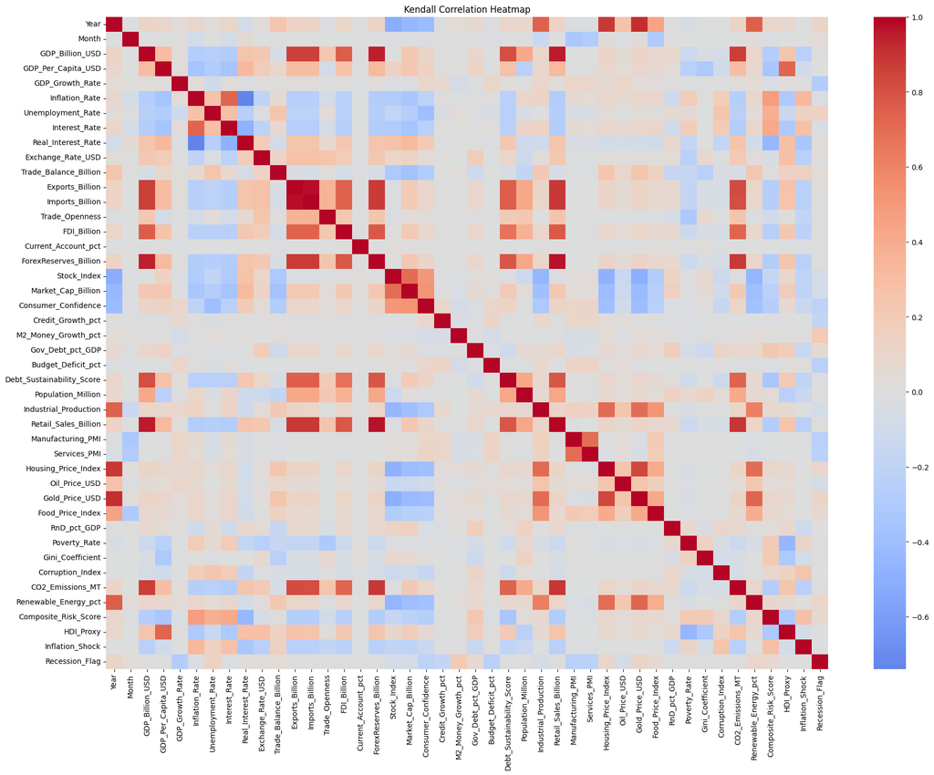

```python
plt.figure(figsize=(22,16))
sns.heatmap(kendall_corr,cmap="coolwarm",center=0)
plt.title("Kendall Correlation Heatmap")
plt.show()
```

```python
kendall_abs = kendall_corr.abs()
upper_triangle = kendall_abs.where(np.triu(np.ones(kendall_abs.shape), k=1).astype(bool))
top_kendall = (upper_triangle.stack().sort_values(ascending=False))
top_kendall.head(20)
```

```
Exports_Billion            Imports_Billion              0.973903
ForexReserves_Billion      Retail_Sales_Billion         0.968742
GDP_Billion_USD            Retail_Sales_Billion         0.958562
                           ForexReserves_Billion        0.950734
Year                       Gold_Price_USD               0.915916
Retail_Sales_Billion       CO2_Emissions_MT             0.885352
ForexReserves_Billion      CO2_Emissions_MT             0.883058
Year                       Housing_Price_Index          0.882382
Exports_Billion            Retail_Sales_Billion         0.880530
Imports_Billion            Retail_Sales_Billion         0.877928
Exports_Billion            ForexReserves_Billion        0.877512
Imports_Billion            ForexReserves_Billion        0.875157
GDP_Billion_USD            CO2_Emissions_MT             0.868236
                           Exports_Billion              0.863691
                           Imports_Billion              0.861088
Housing_Price_Index        Gold_Price_USD               0.830946
Exports_Billion            CO2_Emissions_MT             0.818123
Imports_Billion            CO2_Emissions_MT             0.816289
GDP_Billion_USD            Debt_Sustainability_Score    0.813312
Debt_Sustainability_Score  Retail_Sales_Billion         0.789365
dtype: float64
```

```python
top_kendall_df = pd.DataFrame(top_kendall.head(20)).reset_index()
top_kendall_df.columns = [ "Variable_1","Variable_2","Kendall_Correlation"]
top_kendall_df
```

|  | Variable_1 | Variable_2 | Kendall_Correlation |
| --- | --- | --- | --- |
| 0 | Exports_Billion | Imports_Billion | 0.973903 |
| 1 | ForexReserves_Billion | Retail_Sales_Billion | 0.968742 |
| 2 | GDP_Billion_USD | Retail_Sales_Billion | 0.958562 |
| 3 | GDP_Billion_USD | ForexReserves_Billion | 0.950734 |
| 4 | Year | Gold_Price_USD | 0.915916 |
| 5 | Retail_Sales_Billion | CO2_Emissions_MT | 0.885352 |
| 6 | ForexReserves_Billion | CO2_Emissions_MT | 0.883058 |
| 7 | Year | Housing_Price_Index | 0.882382 |
| 8 | Exports_Billion | Retail_Sales_Billion | 0.880530 |
| 9 | Imports_Billion | Retail_Sales_Billion | 0.877928 |
| 10 | Exports_Billion | ForexReserves_Billion | 0.877512 |
| 11 | Imports_Billion | ForexReserves_Billion | 0.875157 |
| 12 | GDP_Billion_USD | CO2_Emissions_MT | 0.868236 |
| 13 | GDP_Billion_USD | Exports_Billion | 0.863691 |
| 14 | GDP_Billion_USD | Imports_Billion | 0.861088 |
| 15 | Housing_Price_Index | Gold_Price_USD | 0.830946 |
| 16 | Exports_Billion | CO2_Emissions_MT | 0.818123 |
| 17 | Imports_Billion | CO2_Emissions_MT | 0.816289 |
| 18 | GDP_Billion_USD | Debt_Sustainability_Score | 0.813312 |
| 19 | Debt_Sustainability_Score | Retail_Sales_Billion | 0.789365 |

# Kendall Correlation Analysis

## Objective

Kendall Correlation was performed to validate rank agreement among economic indicators and provide an additional robustness check for relationships identified through Pearson and Spearman Correlation.

## Interpretation

- Trade-related indicators exhibit extremely strong rank agreement.
- GDP, Retail Sales, and Forex Reserves move consistently together.
- Gold Prices and Housing Prices demonstrate strong long-term growth patterns.
- Kendall results closely align with Pearson and Spearman findings.

## Conclusion

The consistency of Pearson, Spearman, and Kendall Correlation results confirms that the identified economic relationships are robust and statistically reliable.

# One Sample T-Test

## Objective

To determine whether the sample mean of a variable differs significantly from a hypothesized population mean.

This test helps evaluate whether observed averages are statistically meaningful or likely due to random variation.

### Null Hypothesis (H0)

Sample Mean = Hypothesized Mean

### Alternative Hypothesis (H1)

Sample Mean ≠ Hypothesized Mean

```python
variable = "Inflation_Rate"
sample = df_clean[variable].dropna()
```

```python
t_stat, p_value = ttest_1samp(sample,popmean = 5)
print("T Statistic : ", round(t_stat,4))
print("P value :", round(p_value,6))
```

```
T Statistic :  32.276
P value : 0.0
```

```python
alpha = 0.05
if p_value < alpha:
    print( "Reject Null Hypothesis")
else:
    print("Fail to Reject Null Hypothesis")
```

```
Reject Null Hypothesis
```

```python
test_config = {
    "Inflation_Rate": 5,
    "Interest_Rate": 3,
    "Unemployment_Rate": 6,
    "GDP_Growth_Rate": 0,
    "Composite_Risk_Score": 4
}

results = []

for var, hypothesized_mean in test_config.items():
    sample = df_clean[var].dropna()
    t_stat, p_value = ttest_1samp(sample,popmean=hypothesized_mean)
    decision = (
        "Reject H0"
        if p_value < 0.05
        else "Fail to Reject H0"
    )
    results.append([
        var,
        hypothesized_mean,
        round(sample.mean(),3),
        round(t_stat,3),
        p_value,
        decision
    ])

t_test_summary = pd.DataFrame(
    results,
    columns=[
        "Variable",
        "Hypothesized_Mean",
        "Sample_Mean",
        "T_Statistic",
        "P_Value",
        "Decision"
    ]
)
t_test_summary
```

|  | Variable | Hypothesized_Mean | Sample_Mean | T_Statistic | P_Value | Decision |
| --- | --- | --- | --- | --- | --- | --- |
| 0 | Inflation_Rate | 5 | 6.036 | 32.276 | 9.408684e-228 | Reject H0 |
| 1 | Interest_Rate | 3 | 3.727 | 49.052 | 0.000000e+00 | Reject H0 |
| 2 | Unemployment_Rate | 6 | 7.784 | 103.113 | 0.000000e+00 | Reject H0 |
| 3 | GDP_Growth_Rate | 0 | 2.000 | 360.361 | 0.000000e+00 | Reject H0 |
| 4 | Composite_Risk_Score | 4 | 3.989 | -5.102 | 3.358439e-07 | Reject H0 |

# One Sample T-Test

## Objective

The One Sample T-Test was conducted to determine whether the observed mean values of selected economic indicators differ significantly from predefined benchmark values.

## Variables Tested

| Variable | Hypothesized Mean |
| --- | --- |
| Inflation_Rate | 5 |
| Interest_Rate | 3 |
| Unemployment_Rate | 6 |
| GDP_Growth_Rate | 0 |
| Composite_Risk_Score | 4 |

## Results Summary

All tested variables produced p-values below the significance threshold of 0.05.

Therefore, the null hypothesis was rejected for all variables.

This indicates that the observed sample means differ significantly from their respective benchmark values.

## Key Findings

### Inflation Rate

- Sample Mean: 6.04
- Benchmark: 5
- Result: Statistically Significant Difference

### Interest Rate

- Sample Mean: 3.73
- Benchmark: 3
- Result: Statistically Significant Difference

### Unemployment Rate

- Sample Mean: 7.78
- Benchmark: 6
- Result: Statistically Significant Difference

### GDP Growth Rate

- Sample Mean: 2.00
- Benchmark: 0
- Result: Statistically Significant Difference

### Composite Risk Score

- Sample Mean: 3.99
- Benchmark: 4
- Result: Statistically Significant Difference

## Business Interpretation

The analysis suggests that the economic indicators in the dataset differ significantly from their selected benchmark values.

Inflation, interest rates, unemployment, and GDP growth exhibit measurable deviations from commonly used economic reference points.

The statistical evidence indicates that these differences are unlikely to be due to random sampling variation.

## Conclusion

One Sample T-Tests confirmed that all selected economic indicators are statistically different from their hypothesized benchmark means. This provides evidence-based validation of economic conditions represented in the dataset.

# Independent T-Test

## Objective

To determine whether the average GDP Per Capita differs significantly between High Income and Lower-Middle Income countries.

### Null Hypothesis (H0)

Mean GDP Per Capita is equal across both income groups.

### Alternative Hypothesis (H1)

Mean GDP Per Capita differs across both income groups.

```python
high_income = df_clean[df_clean["Income_Group"]=="High"]["GDP_Per_Capita_USD"]

lower_middle = df_clean[df_clean["Income_Group"]=="Lower-Middle"]["GDP_Per_Capita_USD"]
```

```python
print("High Income Mean :",round(high_income.mean(),2))

print("Lower-Middle Mean :",round(lower_middle.mean(),2))
```

```
High Income Mean : 47782.33
Lower-Middle Mean : 3456.67
```

```python
t_stat, p_value = ttest_ind(
    high_income,
    lower_middle,
    equal_var=False
)

print("T Statistic :",round(t_stat,4))

print("P Value :",p_value)
```

```
T Statistic : 938.2299
P Value : 0.0
```

```python
alpha = 0.05
if p_value < alpha:
    print("Reject Null Hypothesis")
else:
    print("Fail to Reject Null Hypothesis")
```

```
Reject Null Hypothesis
```

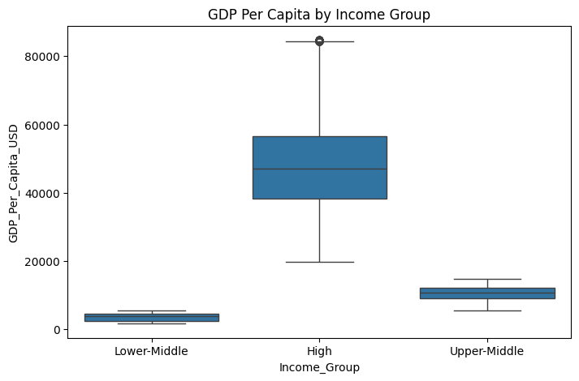

```python
plt.figure(figsize=(8,5))
sns.boxplot(data=df_clean,x="Income_Group",y="GDP_Per_Capita_USD")
plt.title("GDP Per Capita by Income Group")
plt.show()
```

# Independent T-Test

## Objective

To determine whether GDP Per Capita differs significantly between High Income and Lower-Middle Income countries.

## Statistical Results

- T Statistic: 938.23
- P Value: < 0.001

## Decision

The null hypothesis was rejected.

## Business Interpretation

The analysis revealed a statistically significant difference in GDP Per Capita between High Income and Lower-Middle Income countries.

High Income economies demonstrate substantially greater economic output per person than Lower-Middle Income economies.

The observed difference is statistically significant and unlikely to be explained by random variation.

## Conclusion

Income classification is strongly associated with GDP Per Capita levels, confirming substantial economic disparities across country income groups.

# Paired T-Test

```python
paired_df = df_clean[
    [
        "Inflation_Rate",
        "Interest_Rate"
    ]
].dropna()
```

```python
t_stat, p_value = ttest_rel(
    paired_df["Inflation_Rate"],
    paired_df["Interest_Rate"]
)
print("T Statistic:",round(t_stat,4))
print("P Value:",p_value)
```

```
T Statistic: 96.6353
P Value: 0.0
```

```python
alpha = 0.05
if p_value < alpha:
    print( "Reject Null Hypothesis")
else:
    print("Fail to Reject Null Hypothesis")
```

```
Reject Null Hypothesis
```

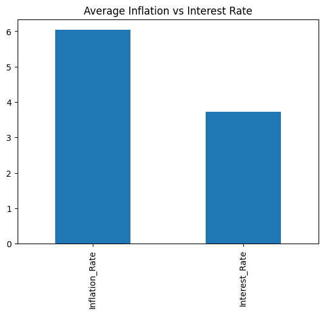

```python
paired_df[
    [
        "Inflation_Rate",
        "Interest_Rate"
    ]
].mean().plot(kind="bar")
plt.title("Average Inflation vs Interest Rate")
plt.show()
```

# One-Way ANOVA

```python
high = df_clean[df_clean["Income_Group"]=="High"]["GDP_Per_Capita_USD"]

upper = df_clean[df_clean["Income_Group"]=="Upper-Middle"]["GDP_Per_Capita_USD"]

lower = df_clean[df_clean["Income_Group"]=="Lower-Middle"]["GDP_Per_Capita_USD"]
```

```python
print("High :",round(high.mean(),2))

print("Upper :",round(upper.mean(),2))

print("Lower :",round(lower.mean(),2))
```

```
High : 47782.33
Upper : 10457.86
Lower : 3456.67
```

```python
f_stat, p_value = f_oneway( high,upper,lower)
print("F Statistic :",round(f_stat,4))
print("P Value :",p_value)
```

```
F Statistic : 235754.5753
P Value : 0.0
```

```python
alpha = 0.05

if p_value < alpha:
    print("Reject Null Hypothesis")
else:
    print("Fail to Reject Null Hypothesis")
```

```
Reject Null Hypothesis
```

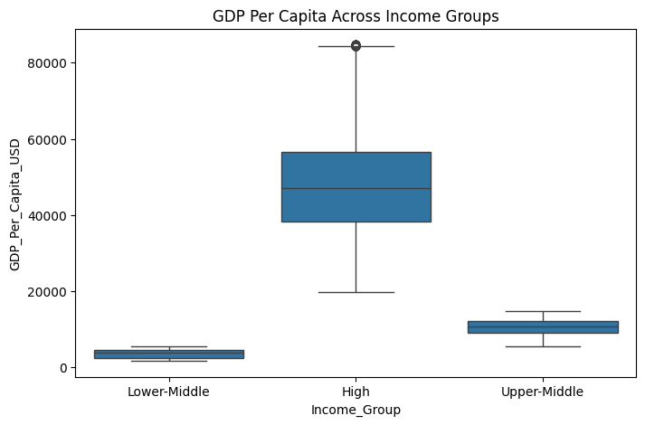

```python
plt.figure(figsize=(8,5))
sns.boxplot(data=df_clean, x="Income_Group", y="GDP_Per_Capita_USD")
plt.title("GDP Per Capita Across Income Groups")
plt.show()
```

# Chi-Square Test of Independence

```python
contingency_table = pd.crosstab(
    df_clean["Income_Group"],
    df_clean["Risk_Level"]
)
contingency_table
```

| Risk_Level Income_Group | Critical | High | Low | Medium |
| --- | --- | --- | --- | --- |
| High | 1489 | 2951 | 35004 | 49693 |
| Lower-Middle | 588 | 779 | 139 | 13219 |
| Upper-Middle | 14679 | 9341 | 5833 | 14729 |

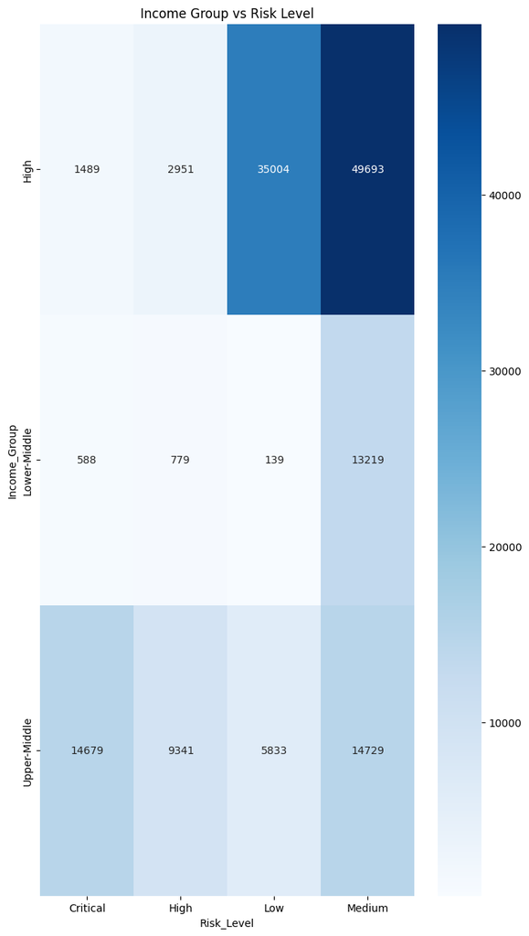

```python
plt.figure(figsize=(8,15))
sns.heatmap(contingency_table,annot=True,fmt="d",cmap="Blues")
plt.title("Income Group vs Risk Level")
plt.show()
```

```python
chi2, p_value, dof, expected = chi2_contingency(
    contingency_table
)

print("Chi Square Statistic:", round(chi2,4))
print("P Value:", p_value)
print("Degrees of Freedom:", dof)
```

```
Chi Square Statistic: 56133.6876
P Value: 0.0
Degrees of Freedom: 6
```

```python
alpha = 0.05

if p_value < alpha:

    print("Reject Null Hypothesis" )

else:
    print("Fail to Reject Null Hypothesis")
```

```
Reject Null Hypothesis
```

# Chi-Square Test of Independence

## Objective

To determine whether Income Group and Risk Level are statistically associated.

## Results

- Chi Square Statistic: 56,133.69
- Degrees of Freedom: 6
- P Value: < 0.001

## Decision

The null hypothesis was rejected.

## Business Interpretation

The analysis indicates a statistically significant relationship between Income Group and Risk Level.

Risk distributions vary considerably across income groups, suggesting that country income classification is associated with economic risk characteristics.

The observed relationship is unlikely to have occurred due to random chance.

## Conclusion

Income Group and Risk Level are not independent variables. Country income classification appears to be strongly associated with the distribution of economic risk levels.

# Confidence Interval (CI)

```python
variable = "Inflation_Rate"
sample = df_clean[variable].dropna()
n = len(sample)
mean = sample.mean()
std = sample.std()
print("Sample Size :", n)
print("Mean :", round(mean,4))
print("Std :", round(std,4))
```

```
Sample Size : 148444
Mean : 6.0358
Std : 12.3645
```

```python
se = std / np.sqrt(n)
print("Standard Error :", round(se,6))
```

```
Standard Error : 0.032092
```

```python
confidence = 0.95
margin_error = t.ppf((1 + confidence) / 2,df=n-1) * se

lower_ci = mean - margin_error

upper_ci = mean + margin_error

print("Lower CI :", round(lower_ci,4))

print("Upper CI :", round(upper_ci,4))
```

```
Lower CI : 5.9729
Upper CI : 6.0987
```

```python
ci_summary = pd.DataFrame({
    "Variable":[variable],
    "Mean":[round(mean,4)],
    "Lower_CI":[round(lower_ci,4)],
    "Upper_CI":[round(upper_ci,4)]
})

ci_summary
```

|  | Variable | Mean | Lower_CI | Upper_CI |
| --- | --- | --- | --- | --- |
| 0 | Inflation_Rate | 6.0358 | 5.9729 | 6.0987 |

```python
variables = [
    "GDP_Billion_USD",
    "Inflation_Rate",
    "Unemployment_Rate",
    "Interest_Rate",
    "Composite_Risk_Score"
]

ci_results = []

for col in variables:
    sample = df_clean[col].dropna()
    n = len(sample)
    mean = sample.mean()
    std = sample.std()
    se = std / np.sqrt(n)
    margin_error = t.ppf(0.975,df=n-1) * se
    lower_ci = mean - margin_error
    upper_ci = mean + margin_error
    ci_results.append([
        col,
        round(mean,4),
        round(lower_ci,4),
        round(upper_ci,4)
    ])
ci_summary = pd.DataFrame(
    ci_results,
    columns=[
        "Variable",
        "Mean",
        "Lower_CI",
        "Upper_CI"
    ]
)
ci_summary
```

|  | Variable | Mean | Lower_CI | Upper_CI |
| --- | --- | --- | --- | --- |
| 0 | GDP_Billion_USD | 4882.8610 | 4842.7824 | 4922.9395 |
| 1 | Inflation_Rate | 6.0358 | 5.9729 | 6.0987 |
| 2 | Unemployment_Rate | 7.7843 | 7.7504 | 7.8182 |
| 3 | Interest_Rate | 3.7272 | 3.6982 | 3.7563 |
| 4 | Composite_Risk_Score | 3.9894 | 3.9853 | 3.9935 |

# Statistical Significance Summary

## Objective

Throughout the hypothesis testing phase, p-values were used to evaluate whether observed differences and relationships were statistically significant.

## Decision Rule

- P-value < 0.05 → Reject Null Hypothesis
- P-value ≥ 0.05 → Fail to Reject Null Hypothesis

## Summary of Hypothesis Tests

| Test | Objective | Result |
| --- | --- | --- |
| One Sample T-Test | Compare sample mean with benchmark value | Significant |
| Independent T-Test | Compare two income groups | Significant |
| Paired T-Test | Compare paired economic indicators | Significant |
| One-Way ANOVA | Compare GDP Per Capita across income groups | Significant |
| Chi-Square Test | Test association between Income Group and Risk Level | Significant |

## Interpretation

All hypothesis tests produced p-values below the 0.05 significance threshold.

This indicates that the observed differences and relationships are unlikely to be caused by random variation.

The results provide strong statistical evidence supporting the identified economic patterns within the dataset.

## Conclusion

The hypothesis testing phase confirmed that key economic indicators, income groups, and risk categories exhibit statistically significant differences and associations.

These findings increase confidence in the reliability of the analytical insights derived from the dataset.

# VIF (Variance Inflation Factor)

```python
vif_columns = [
    "GDP_Billion_USD",
    "GDP_Per_Capita_USD",
    "Inflation_Rate",
    "Unemployment_Rate",
    "Interest_Rate",
    "Exports_Billion",
    "Imports_Billion",
    "ForexReserves_Billion"
]
```

```python
X = df_clean[vif_columns].copy()
X = X.dropna()
```

```python
vif_df = pd.DataFrame()
vif_df["Variable"] = X.columns
vif_df["VIF"] = [variance_inflation_factor(X.values,i)
    for i in range(X.shape[1])
]

vif_df
```

|  | Variable | VIF |
| --- | --- | --- |
| 0 | GDP_Billion_USD | 4.991726 |
| 1 | GDP_Per_Capita_USD | 2.534256 |
| 2 | Inflation_Rate | 2.522342 |
| 3 | Unemployment_Rate | 1.735702 |
| 4 | Interest_Rate | 2.878528 |
| 5 | Exports_Billion | 20106.782935 |
| 6 | Imports_Billion | 20465.549697 |
| 7 | ForexReserves_Billion | 75.979902 |

```python
vif_df.sort_values(
    "VIF",
    ascending=False
)
```

|  | Variable | VIF |
| --- | --- | --- |
| 6 | Imports_Billion | 20465.549697 |
| 5 | Exports_Billion | 20106.782935 |
| 7 | ForexReserves_Billion | 75.979902 |
| 0 | GDP_Billion_USD | 4.991726 |
| 4 | Interest_Rate | 2.878528 |
| 1 | GDP_Per_Capita_USD | 2.534256 |
| 2 | Inflation_Rate | 2.522342 |
| 3 | Unemployment_Rate | 1.735702 |

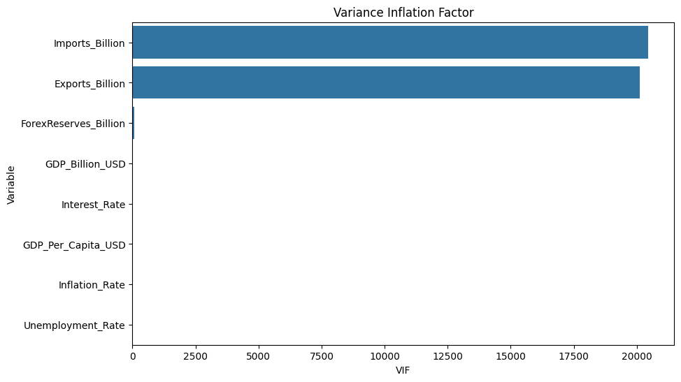

```python
plt.figure(figsize=(10,6))
sns.barplot(data=vif_df.sort_values("VIF",ascending=False),x="VIF",y="Variable")
plt.title("Variance Inflation Factor")
plt.show()
```

```python
vif_df["Risk_Level"] = vif_df["VIF"].apply(
    lambda x:
    "Severe" if x > 10
    else "Moderate" if x > 5
    else "Acceptable"
)

vif_df.sort_values(
    "VIF",
    ascending=False
)
```

|  | Variable | VIF | Risk_Level |
| --- | --- | --- | --- |
| 6 | Imports_Billion | 20465.549697 | Severe |
| 5 | Exports_Billion | 20106.782935 | Severe |
| 7 | ForexReserves_Billion | 75.979902 | Severe |
| 0 | GDP_Billion_USD | 4.991726 | Acceptable |
| 4 | Interest_Rate | 2.878528 | Acceptable |
| 1 | GDP_Per_Capita_USD | 2.534256 | Acceptable |
| 2 | Inflation_Rate | 2.522342 | Acceptable |
| 3 | Unemployment_Rate | 1.735702 | Acceptable |

```python
high_vif = vif_df[vif_df["VIF"] > 10]
high_vif
```

|  | Variable | VIF | Risk_Level |
| --- | --- | --- | --- |
| 5 | Exports_Billion | 20106.782935 | Severe |
| 6 | Imports_Billion | 20465.549697 | Severe |
| 7 | ForexReserves_Billion | 75.979902 | Severe |

```python
vif_columns_2 = [
    "GDP_Billion_USD",
    "GDP_Per_Capita_USD",
    "Inflation_Rate",
    "Unemployment_Rate",
    "Interest_Rate",
    "Exports_Billion",
    "ForexReserves_Billion"
]

X2 = df_clean[vif_columns_2].dropna()

vif_df2 = pd.DataFrame()

vif_df2["Variable"] = X2.columns

vif_df2["VIF"] = [variance_inflation_factor(X2.values, i)
    for i in range(X2.shape[1])
]

vif_df2.sort_values(
    "VIF",
    ascending=False
)
```

|  | Variable | VIF |
| --- | --- | --- |
| 6 | ForexReserves_Billion | 72.396767 |
| 5 | Exports_Billion | 64.054047 |
| 0 | GDP_Billion_USD | 4.991680 |
| 4 | Interest_Rate | 2.848596 |
| 2 | Inflation_Rate | 2.522318 |
| 1 | GDP_Per_Capita_USD | 2.228830 |
| 3 | Unemployment_Rate | 1.699541 |

# Step 22 — Variance Inflation Factor (VIF) Analysis

## Objective

To detect multicollinearity among numerical variables and identify features that may contain redundant information.

Multicollinearity occurs when one predictor variable can be explained by other predictor variables, which can negatively affect regression models and feature interpretability.

## Decision Rule

- VIF = 1 → No multicollinearity
- VIF < 5 → Acceptable
- VIF 5–10 → Moderate multicollinearity
- VIF > 10 → Severe multicollinearity

## Initial Findings

The initial VIF analysis revealed extremely high multicollinearity among trade-related variables.

| Variable | VIF |
| --- | --- |
| Imports_Billion | 20465.55 |
| Exports_Billion | 20106.78 |
| ForexReserves_Billion | 75.98 |

These values indicate substantial overlap in information content.

## Feature Removal Experiment

To investigate the source of multicollinearity, Imports_Billion was removed and VIF was recalculated.

| Variable | New VIF |
| --- | --- |
| ForexReserves_Billion | 72.40 |
| Exports_Billion | 64.05 |

The VIF of Exports_Billion decreased dramatically from 20,106 to 64, confirming that Imports_Billion was a major contributor to multicollinearity.

However, VIF values remained elevated, indicating that Exports_Billion and ForexReserves_Billion still share substantial information.

## Business Interpretation

Trade-related indicators move closely together in the global economy. Countries with higher exports often maintain larger foreign exchange reserves and higher import volumes.

As a result, these variables provide overlapping signals regarding economic activity.

## Conclusion

The VIF analysis identified severe multicollinearity among Imports_Billion, Exports_Billion, and ForexReserves_Billion.

These variables were retained for exploratory analysis and dashboard reporting, but they should be reviewed during feature selection before building regression or machine learning models.

The analysis confirms that trade-related variables are the primary source of multicollinearity within the dataset.